# 09. Logistic regression modelling in blocks

### Logit iteration 1

Recode `gender=Non-Binary` as missing because there are too few data points: recode variable.

**Results**

```python
selected_dv, selected_xc, sel_block_ch_d = dv_xc_remove_value(dv, Xc, block_ch_d, "gender_Non-Binary")
# cols_to_remove += ["gender_Non-Binary"]
results, summary, results_or = binomial_regression(selected_dv, selected_xc[sel_block_ch_d], cols_to_remove, dummy_cols)
```

```
Optimization terminated successfully.
         Current function value: 0.296679
         Iterations 7
```

Logit Regression Results

| Dep. Variable: | multiple_returns | No. Observations: | 2810 |
| --- | --- | --- | --- |
| Model: | Logit | Df Residuals: | 2805 |
| Method: | MLE | Df Model: | 4 |
| Date: | Sun, 21 Jun 2026 | Pseudo R-squ.: | 0.01696 |
| Time: | 14:49:49 | Log-Likelihood: | -833.67 |
| converged: | True | LL-Null: | -848.05 |
| Covariance Type: | nonrobust | LLR p-value: | 8.756e-06 |

|  | coef | std err | z | P>\|z\| | [0.025 | 0.975] |
| --- | --- | --- | --- | --- | --- | --- |
| (Intercept) | -2.1811 | 0.096 | -22.760 | 0.000 | -2.369 | -1.993 |
| gender_Female | -0.2088 | 0.155 | -1.350 | 0.177 | -0.512 | 0.094 |
| age_cat_34- | 0.2349 | 0.137 | 1.720 | 0.085 | -0.033 | 0.503 |
| global_majority | -0.9110 | 0.196 | -4.658 | 0.000 | -1.294 | -0.528 |
| lgbtq_plus | -0.1194 | 0.280 | -0.426 | 0.670 | -0.669 | 0.430 |

| Odds Ratios | p | * | odds_r | [0.025 | 0.975] |
| --- | --- | --- | --- | --- | --- |
| lgbtq_plus | 0.670 |  | 0.887 | 0.512 | 1.537 |
| gender_Female | 0.177 |  | 0.812 | 0.599 | 1.099 |
| age_cat_34- | 0.085 |  | 1.265 | 0.968 | 1.653 |
| global_majority | 0.000 | * | 0.402 | 0.274 | 0.590 |
| (Intercept) | 0.000 | * | 0.113 | 0.094 | 0.136 |

```
Psuedo R^2: 0.01695520051757582
--------------------------------------------------
```

`lgbtq_plus` not significant as variance better explained by other variables

### Logit iteration 2

**Results**

```python
cols_to_remove += ["lgbtq_plus"]
results, summary, results_or = binomial_regression(selected_dv, selected_xc[sel_block_ch_d], cols_to_remove, dummy_cols)
```

```
Optimization terminated successfully.
         Current function value: 0.281181
         Iterations 7
```

Logit Regression Results

| Dep. Variable: | multiple_returns | No. Observations: | 3501 |
| --- | --- | --- | --- |
| Model: | Logit | Df Residuals: | 3497 |
| Method: | MLE | Df Model: | 3 |
| Date: | Sun, 21 Jun 2026 | Pseudo R-squ.: | 0.02030 |
| Time: | 14:49:49 | Log-Likelihood: | -984.41 |
| converged: | True | LL-Null: | -1004.8 |
| Covariance Type: | nonrobust | LLR p-value: | 7.228e-09 |

|  | coef | std err | z | P>\|z\| | [0.025 | 0.975] |
| --- | --- | --- | --- | --- | --- | --- |
| (Intercept) | -2.2810 | 0.089 | -25.643 | 0.000 | -2.455 | -2.107 |
| gender_Female | -0.2564 | 0.145 | -1.771 | 0.077 | -0.540 | 0.027 |
| age_cat_34- | 0.3219 | 0.126 | 2.563 | 0.010 | 0.076 | 0.568 |
| global_majority | -0.9727 | 0.181 | -5.362 | 0.000 | -1.328 | -0.617 |

Variables removed: ['lgbtq_plus']

|  | p | * | odds_r | [0.025 | 0.975] | prev_coef | coef | diff_pct |
| --- | --- | --- | --- | --- | --- | --- | --- | --- |
| gender_Female | 0.077 |  | 0.774 | 0.583 | 1.028 | -0.209 | -0.256 | 22.800 |
| age_cat_34- | 0.010 | * | 1.380 | 1.079 | 1.765 | 0.235 | 0.322 | 37.000 |
| global_majority | 0.000 | * | 0.378 | 0.265 | 0.539 | -0.911 | -0.973 | 6.800 |
| (Intercept) | 0.000 | * | 0.102 | 0.086 | 0.122 | -2.181 | -2.281 | 4.600 |

```
Psuedo R^2: 0.020299810399552864
--------------------------------------------------
```

`gender` appears not significant but p=0.08 – leaving in for now.

### Add block for grouped ethnicity data and drop “global_majority”

```python
new_block_ch = selected_ch["ethnicity_related"]
sel_block_ch = [ch for ch in block_ch + new_block_ch if ch != "global_majority"]
sel_block_ch_d = [ch for ch in sel_block_ch_d + cols_with_dummies(new_block_ch, dummy_cols) if ch != "global_majority"]
```

### Test associations between IVs now a block has been added

#### Cramer’s V

**Results**

p values indicated by asterisks: `***` if `p < 0.001`, `**` if `p < 0.01`, `*` if `p < 0.05`

```python
chi2_crv_results, disp = iv_assoc(iv_df, sel_block_ch)
with pd.option_context("display.float_format", "{:,.3f}".format):
    display(disp)
```

| iv1 | iv2 | g | ac | lp | eg | uis |
| --- | --- | --- | --- | --- | --- | --- |
| gender | V | NaN | 0.131 | 0.235 | 0.051 | 0.048 |
|  | * | NaN | *** | *** | * |  |
| age_cat | V | 0.131 | NaN | 0.096 | 0.105 | 0.093 |
|  | * | *** | NaN | *** | *** | *** |
| lgbtq_plus | V | 0.235 | 0.096 | NaN | 0.069 | 0.012 |
|  | * | *** | *** | NaN | * |  |
| ethnicity_grouped | V | 0.051 | 0.105 | 0.069 | NaN | 0.389 |
|  | * | * | *** | * | NaN | *** |
| uk_immigration_status | V | 0.048 | 0.093 | 0.012 | 0.389 | NaN |
|  | * |  | *** |  | *** | NaN |

#### Variance Inflation Factor (VIF)

**Results**

```python
# Test multicollinearity with VIF
vif_data = vif(Xc[sel_block_ch_d[1:]])
with pd.option_context("display.float_format", "{:,.3f}".format):
    display(vif_data)
```

| Feature | VIF |
| --- | --- |
| uk_immigration_status_Non-EEA National | 1.566 |
| age_cat_34- | 1.387 |
| ethnicity_grouped_Black | 1.357 |
| ethnicity_grouped_Other | 1.316 |
| gender_Female | 1.235 |
| lgbtq_plus | 1.076 |
| ethnicity_grouped_Mixed Heritage | 1.054 |
| uk_immigration_status_EEA National | 1.042 |

No significant multicollinearity. Proceeding with Logit.

```python
results, summary, results_or = binomial_regression(selected_dv, selected_xc[sel_block_ch_d], [], dummy_cols)
```

### Logit iteration 3

**Results**

```python
results, summary, results_or = binomial_regression(selected_dv, selected_xc[sel_block_ch_d], cols_to_remove, dummy_cols)
```

```
Optimization terminated successfully.
         Current function value: 0.314697
         Iterations 8
```

Logit Regression Results

| Dep. Variable: | multiple_returns | No. Observations: | 2926 |
| --- | --- | --- | --- |
| Model: | Logit | Df Residuals: | 2918 |
| Method: | MLE | Df Model: | 7 |
| Date: | Sun, 21 Jun 2026 | Pseudo R-squ.: | 0.02380 |
| Time: | 14:49:50 | Log-Likelihood: | -920.80 |
| converged: | True | LL-Null: | -943.26 |
| Covariance Type: | nonrobust | LLR p-value: | 1.425e-07 |

|  | coef | std err | z | P>\|z\| | [0.025 | 0.975] |
| --- | --- | --- | --- | --- | --- | --- |
| (Intercept) | -2.0877 | 0.091 | -22.859 | 0.000 | -2.267 | -1.909 |
| gender_Female | -0.2623 | 0.147 | -1.783 | 0.075 | -0.551 | 0.026 |
| age_cat_34- | 0.3390 | 0.127 | 2.666 | 0.008 | 0.090 | 0.588 |
| ethnicity_grouped_Black | -0.6724 | 0.246 | -2.735 | 0.006 | -1.154 | -0.191 |
| ethnicity_grouped_Other | -1.2667 | 0.487 | -2.600 | 0.009 | -2.222 | -0.312 |
| ethnicity_grouped_Mixed Heritage | -0.6628 | 0.335 | -1.981 | 0.048 | -1.319 | -0.007 |
| uk_immigration_status_Non-EEA National | -0.5660 | 0.353 | -1.604 | 0.109 | -1.258 | 0.126 |
| uk_immigration_status_EEA National | -0.5550 | 0.428 | -1.295 | 0.195 | -1.395 | 0.285 |

Variables removed: ['lgbtq_plus']

|  | p | * | odds_r | [0.025 | 0.975] | prev_coef | coef | diff_pct |
| --- | --- | --- | --- | --- | --- | --- | --- | --- |
| uk_immigration_status_EEA National | 0.195 |  | 0.574 | 0.248 | 1.329 | -0.658 | -0.555 | -15.700 |
| uk_immigration_status_Non-EEA National | 0.109 |  | 0.568 | 0.284 | 1.134 | -0.508 | -0.566 | 11.400 |
| gender_Female | 0.075 |  | 0.769 | 0.577 | 1.026 | -0.223 | -0.262 | 17.800 |
| ethnicity_grouped_Mixed Heritage | 0.048 | * | 0.515 | 0.268 | 0.993 | -0.751 | -0.663 | -11.800 |
| ethnicity_grouped_Other | 0.009 | * | 0.282 | 0.108 | 0.732 | -1.224 | -1.267 | 3.500 |
| age_cat_34- | 0.008 | * | 1.404 | 1.094 | 1.801 | 0.254 | 0.339 | 33.600 |
| ethnicity_grouped_Black | 0.006 | * | 0.510 | 0.315 | 0.827 | -0.587 | -0.672 | 14.500 |
| (Intercept) | 0.000 | * | 0.124 | 0.104 | 0.148 | -1.991 | -2.088 | 4.800 |

```
Psuedo R^2: 0.023804515356686484
--------------------------------------------------
```

`uk_immigration_status` not significant as variance better explained by other variables

### Logit iteration 4

**Results**

```python
cols_to_remove += ["uk_immigration_status"]
results, summary, results_or = binomial_regression(selected_dv, selected_xc[sel_block_ch_d], cols_to_remove, dummy_cols)
```

```
Optimization terminated successfully.
         Current function value: 0.280749
         Iterations 8
```

Logit Regression Results

| Dep. Variable: | multiple_returns | No. Observations: | 3501 |
| --- | --- | --- | --- |
| Model: | Logit | Df Residuals: | 3495 |
| Method: | MLE | Df Model: | 5 |
| Date: | Sun, 21 Jun 2026 | Pseudo R-squ.: | 0.02180 |
| Time: | 14:49:50 | Log-Likelihood: | -982.90 |
| converged: | True | LL-Null: | -1004.8 |
| Covariance Type: | nonrobust | LLR p-value: | 2.523e-08 |

|  | coef | std err | z | P>\|z\| | [0.025 | 0.975] |
| --- | --- | --- | --- | --- | --- | --- |
| (Intercept) | -2.2801 | 0.089 | -25.643 | 0.000 | -2.454 | -2.106 |
| gender_Female | -0.2673 | 0.145 | -1.844 | 0.065 | -0.551 | 0.017 |
| age_cat_34- | 0.3261 | 0.126 | 2.596 | 0.009 | 0.080 | 0.572 |
| ethnicity_grouped_Black | -0.8911 | 0.229 | -3.894 | 0.000 | -1.340 | -0.443 |
| ethnicity_grouped_Other | -1.5819 | 0.458 | -3.452 | 0.001 | -2.480 | -0.684 |
| ethnicity_grouped_Mixed Heritage | -0.6937 | 0.332 | -2.089 | 0.037 | -1.345 | -0.043 |

Variables removed: ['lgbtq_plus', 'uk_immigration_status']

|  | p | * | odds_r | [0.025 | 0.975] | prev_coef | coef | diff_pct |
| --- | --- | --- | --- | --- | --- | --- | --- | --- |
| gender_Female | 0.065 |  | 0.765 | 0.576 | 1.017 | -0.262 | -0.267 | 1.900 |
| ethnicity_grouped_Mixed Heritage | 0.037 | * | 0.500 | 0.261 | 0.958 | -0.663 | -0.694 | 4.700 |
| age_cat_34- | 0.009 | * | 1.386 | 1.083 | 1.772 | 0.339 | 0.326 | -3.800 |
| ethnicity_grouped_Other | 0.001 | * | 0.206 | 0.084 | 0.505 | -1.267 | -1.582 | 24.900 |
| ethnicity_grouped_Black | 0.000 | * | 0.410 | 0.262 | 0.642 | -0.672 | -0.891 | 32.500 |
| (Intercept) | 0.000 | * | 0.102 | 0.086 | 0.122 | -2.088 | -2.280 | 9.200 |

```
Psuedo R^2: 0.021803556591525997
--------------------------------------------------
```

### Add block for support needs variables

```python
new_block_ch = selected_ch["support_needs"]
sel_block_ch = block_ch + new_block_ch
sel_block_ch_d = sel_block_ch_d + cols_with_dummies(new_block_ch, dummy_cols)
```

### Test associations between IVs now a block has been added

#### Cramer’s V

**Results**

p values indicated by asterisks: `***` if `p < 0.001`, `**` if `p < 0.01`, `*` if `p < 0.05`

```python
chi2_crv_results, disp = iv_assoc(iv_df, sel_block_ch)
with pd.option_context("display.float_format", "{:,.3f}".format):
    display(disp)
```

| iv1 | iv2 | g | ac | gm | lp | o | ph | mh | su | md | rs | sw | rva | re |
| --- | --- | --- | --- | --- | --- | --- | --- | --- | --- | --- | --- | --- | --- | --- |
| gender | V | NaN | 0.133 | 0.041 | 0.236 | 0.164 | 0.050 | 0.096 | 0.080 | 0.030 | 0.068 | 0.227 | 0.348 | 0.124 |
|  | * | NaN | *** |  | *** | *** |  | *** | ** |  | * | *** | *** | *** |
| age_cat | V | 0.133 | NaN | 0.105 | 0.099 | 0.008 | 0.194 | 0.065 | 0.158 | 0.043 | 0.017 | 0.035 | 0.052 | 0.015 |
|  | * | *** | NaN | *** | *** |  | *** | ** | *** | * |  |  | * |  |
| global_majority | V | 0.041 | 0.105 | NaN | 0.014 | 0.063 | 0.069 | 0.095 | 0.268 | 0.201 | 0.061 | 0.065 | 0.026 | 0.065 |
|  | * |  | *** | NaN |  | ** | *** | *** | *** | *** | ** | ** |  | ** |
| lgbtq_plus | V | 0.236 | 0.099 | 0.014 | NaN | 0.031 | 0.006 | 0.047 | 0.056 | 0.030 | 0.023 | 0.022 | 0.018 | 0.009 |
|  | * | *** | *** |  | NaN |  |  | * | ** |  |  |  |  |  |
| offending | V | 0.164 | 0.008 | 0.063 | 0.031 | NaN | 0.011 | 0.045 | 0.149 | 0.336 | 0.084 | 0.016 | 0.044 | 0.010 |
|  | * | *** |  | ** |  | NaN |  | * | *** | *** | *** |  | * |  |
| physical_health | V | 0.050 | 0.194 | 0.069 | 0.006 | 0.011 | NaN | 0.085 | 0.083 | 0.089 | 0.081 | 0.033 | 0.042 | 0.083 |
|  | * |  | *** | *** |  |  | NaN | *** | *** | *** | *** |  |  | *** |
| mental_health | V | 0.096 | 0.065 | 0.095 | 0.047 | 0.045 | 0.085 | NaN | 0.168 | 0.533 | 0.079 | 0.079 | 0.062 | 0.073 |
|  | * | *** | ** | *** | * | * | *** | NaN | *** | *** | *** | *** | ** | *** |
| substance_use | V | 0.080 | 0.158 | 0.268 | 0.056 | 0.149 | 0.083 | 0.168 | NaN | 0.659 | 0.197 | 0.106 | 0.001 | 0.105 |
|  | * | ** | *** | *** | ** | *** | *** | *** | NaN | *** | *** | *** |  | *** |
| multiple_disadvantage | V | 0.030 | 0.043 | 0.201 | 0.030 | 0.336 | 0.089 | 0.533 | 0.659 | NaN | 0.172 | 0.112 | 0.284 | 0.150 |
|  | * |  | * | *** |  | *** | *** | *** | *** | NaN | *** | *** | *** | *** |
| rough_sleeping | V | 0.068 | 0.017 | 0.061 | 0.023 | 0.084 | 0.081 | 0.079 | 0.197 | 0.172 | NaN | 0.078 | 0.035 | 0.015 |
|  | * | * |  | ** |  | *** | *** | *** | *** | *** | NaN | *** |  |  |
| sex_working | V | 0.227 | 0.035 | 0.065 | 0.022 | 0.016 | 0.033 | 0.079 | 0.106 | 0.112 | 0.078 | NaN | 0.211 | 0.202 |
|  | * | *** |  | ** |  |  |  | *** | *** | *** | *** | NaN | *** | *** |
| risk_violence_abuse | V | 0.348 | 0.052 | 0.026 | 0.018 | 0.044 | 0.042 | 0.062 | 0.001 | 0.284 | 0.035 | 0.211 | NaN | 0.236 |
|  | * | *** | * |  |  | * |  | ** |  | *** |  | *** | NaN | *** |
| risk_exploitation | V | 0.124 | 0.015 | 0.065 | 0.009 | 0.010 | 0.083 | 0.073 | 0.105 | 0.150 | 0.015 | 0.202 | 0.236 | NaN |
|  | * | *** |  | ** |  |  | *** | *** | *** | *** |  | *** | *** | NaN |

#### Variance Inflation Factor (VIF)

**Results**

```python
# Test multicollinearity with VIF
vif_data = vif(Xc[sel_block_ch_d[1:]])
with pd.option_context("display.float_format", "{:,.3f}".format):
    display(vif_data)
```

| Feature | VIF |
| --- | --- |
| multiple_disadvantage | 7.949 |
| mental_health | 4.340 |
| substance_use | 4.051 |
| risk_violence_abuse | 1.773 |
| age_cat_34- | 1.671 |
| gender_Female | 1.657 |
| uk_immigration_status_Non-EEA National | 1.584 |
| physical_health | 1.554 |
| offending | 1.474 |
| ethnicity_grouped_Black | 1.398 |
| ethnicity_grouped_Other | 1.342 |
| rough_sleeping | 1.314 |
| risk_exploitation | 1.199 |
| sex_working | 1.140 |
| lgbtq_plus | 1.094 |
| ethnicity_grouped_Mixed Heritage | 1.070 |
| uk_immigration_status_EEA National | 1.051 |

`multiple_disadvantage` has high VIF due to multicollinearity of `multiple_disadvantage`, `substance_use` and `mental_health`.

Running without `multiple_disadvantage` as for both previous dvs separate needs variables had greater explanatory power

```python
sel_block_ch_d.remove("multiple_disadvantage")
```

```python
results, summary, results_or = binomial_regression(selected_dv, selected_xc[sel_block_ch_d], [], dummy_cols)
```

### Logit iteration 5

**Results**

```python
results, summary, results_or = binomial_regression(selected_dv, selected_xc[sel_block_ch_d], cols_to_remove, dummy_cols)
```

```
Optimization terminated successfully.
         Current function value: 0.275623
         Iterations 8
```

Logit Regression Results

| Dep. Variable: | multiple_returns | No. Observations: | 2874 |
| --- | --- | --- | --- |
| Model: | Logit | Df Residuals: | 2860 |
| Method: | MLE | Df Model: | 13 |
| Date: | Sun, 21 Jun 2026 | Pseudo R-squ.: | 0.1412 |
| Time: | 14:49:53 | Log-Likelihood: | -792.14 |
| converged: | True | LL-Null: | -922.37 |
| Covariance Type: | nonrobust | LLR p-value: | 4.298e-48 |

|  | coef | std err | z | P>\|z\| | [0.025 | 0.975] |
| --- | --- | --- | --- | --- | --- | --- |
| (Intercept) | -4.3187 | 0.246 | -17.577 | 0.000 | -4.800 | -3.837 |
| gender_Female | -0.1455 | 0.181 | -0.805 | 0.421 | -0.500 | 0.209 |
| age_cat_34- | 0.5309 | 0.138 | 3.836 | 0.000 | 0.260 | 0.802 |
| ethnicity_grouped_Black | 0.0540 | 0.249 | 0.217 | 0.828 | -0.434 | 0.542 |
| ethnicity_grouped_Other | -0.6527 | 0.473 | -1.379 | 0.168 | -1.580 | 0.275 |
| ethnicity_grouped_Mixed Heritage | -0.5967 | 0.362 | -1.650 | 0.099 | -1.305 | 0.112 |
| offending | 0.7801 | 0.146 | 5.343 | 0.000 | 0.494 | 1.066 |
| physical_health | 0.3776 | 0.138 | 2.745 | 0.006 | 0.108 | 0.647 |
| mental_health | 0.2192 | 0.167 | 1.311 | 0.190 | -0.109 | 0.547 |
| substance_use | 1.7853 | 0.200 | 8.907 | 0.000 | 1.392 | 2.178 |
| rough_sleeping | 0.5075 | 0.142 | 3.567 | 0.000 | 0.229 | 0.786 |
| sex_working | 0.7489 | 0.367 | 2.039 | 0.041 | 0.029 | 1.469 |
| risk_violence_abuse | -0.1423 | 0.194 | -0.733 | 0.463 | -0.523 | 0.238 |
| risk_exploitation | 0.3789 | 0.215 | 1.764 | 0.078 | -0.042 | 0.800 |

Variables removed: ['lgbtq_plus', 'uk_immigration_status']

|  | p | * | odds_r | [0.025 | 0.975] | prev_coef | coef | diff_pct |
| --- | --- | --- | --- | --- | --- | --- | --- | --- |
| ethnicity_grouped_Black | 0.828 |  | 1.056 | 0.648 | 1.719 | 0.135 | 0.054 | -60.100 |
| risk_violence_abuse | 0.463 |  | 0.867 | 0.593 | 1.269 | -0.371 | -0.142 | -61.600 |
| gender_Female | 0.421 |  | 0.865 | 0.607 | 1.232 | -0.090 | -0.146 | 61.800 |
| mental_health | 0.190 |  | 1.245 | 0.897 | 1.728 | 0.153 | 0.219 | 42.900 |
| ethnicity_grouped_Other | 0.168 |  | 0.521 | 0.206 | 1.316 | -0.642 | -0.653 | 1.600 |
| ethnicity_grouped_Mixed Heritage | 0.099 |  | 0.551 | 0.271 | 1.119 | -0.708 | -0.597 | -15.700 |
| risk_exploitation | 0.078 |  | 1.461 | 0.959 | 2.225 | 0.517 | 0.379 | -26.700 |
| sex_working | 0.041 | * | 2.115 | 1.029 | 4.345 | 0.921 | 0.749 | -18.700 |
| physical_health | 0.006 | * | 1.459 | 1.114 | 1.910 | 0.511 | 0.378 | -26.200 |
| rough_sleeping | 0.000 | * | 1.661 | 1.257 | 2.195 | 0.626 | 0.508 | -19.000 |
| age_cat_34- | 0.000 | * | 1.700 | 1.296 | 2.230 | 0.468 | 0.531 | 13.400 |
| offending | 0.000 | * | 2.182 | 1.639 | 2.905 | 0.770 | 0.780 | 1.300 |
| substance_use | 0.000 | * | 5.962 | 4.025 | 8.830 | 1.706 | 1.785 | 4.700 |
| (Intercept) | 0.000 | * | 0.013 | 0.008 | 0.022 | -4.200 | -4.319 | 2.800 |

```
Psuedo R^2: 0.14118808507860015
--------------------------------------------------
```

`risk_violence_abuse` not significant as variance better explained by other variables

### Logit iteration 6

**Results**

```python
cols_to_remove += ["risk_violence_abuse"]
results, summary, results_or = binomial_regression(selected_dv, selected_xc[sel_block_ch_d], cols_to_remove, dummy_cols)
```

```
Optimization terminated successfully.
         Current function value: 0.275718
         Iterations 8
```

Logit Regression Results

| Dep. Variable: | multiple_returns | No. Observations: | 2874 |
| --- | --- | --- | --- |
| Model: | Logit | Df Residuals: | 2861 |
| Method: | MLE | Df Model: | 12 |
| Date: | Sun, 21 Jun 2026 | Pseudo R-squ.: | 0.1409 |
| Time: | 14:49:53 | Log-Likelihood: | -792.41 |
| converged: | True | LL-Null: | -922.37 |
| Covariance Type: | nonrobust | LLR p-value: | 1.171e-48 |

|  | coef | std err | z | P>\|z\| | [0.025 | 0.975] |
| --- | --- | --- | --- | --- | --- | --- |
| (Intercept) | -4.3186 | 0.246 | -17.590 | 0.000 | -4.800 | -3.837 |
| gender_Female | -0.1834 | 0.174 | -1.056 | 0.291 | -0.524 | 0.157 |
| age_cat_34- | 0.5254 | 0.138 | 3.803 | 0.000 | 0.255 | 0.796 |
| ethnicity_grouped_Black | 0.0530 | 0.249 | 0.213 | 0.831 | -0.435 | 0.541 |
| ethnicity_grouped_Other | -0.6558 | 0.473 | -1.386 | 0.166 | -1.583 | 0.272 |
| ethnicity_grouped_Mixed Heritage | -0.5928 | 0.362 | -1.639 | 0.101 | -1.302 | 0.116 |
| offending | 0.7742 | 0.146 | 5.311 | 0.000 | 0.489 | 1.060 |
| physical_health | 0.3705 | 0.137 | 2.700 | 0.007 | 0.102 | 0.639 |
| mental_health | 0.2159 | 0.167 | 1.292 | 0.196 | -0.112 | 0.544 |
| substance_use | 1.7844 | 0.200 | 8.905 | 0.000 | 1.392 | 2.177 |
| rough_sleeping | 0.5037 | 0.142 | 3.544 | 0.000 | 0.225 | 0.782 |
| sex_working | 0.7114 | 0.364 | 1.956 | 0.051 | -0.002 | 1.424 |
| risk_exploitation | 0.3471 | 0.210 | 1.650 | 0.099 | -0.065 | 0.759 |

Variables removed: ['lgbtq_plus', 'uk_immigration_status', 'risk_violence_abuse']

|  | p | * | odds_r | [0.025 | 0.975] | prev_coef | coef | diff_pct |
| --- | --- | --- | --- | --- | --- | --- | --- | --- |
| ethnicity_grouped_Black | 0.831 |  | 1.054 | 0.647 | 1.717 | 0.054 | 0.053 | -2.000 |
| gender_Female | 0.291 |  | 0.832 | 0.592 | 1.170 | -0.146 | -0.183 | 26.000 |
| mental_health | 0.196 |  | 1.241 | 0.894 | 1.722 | 0.219 | 0.216 | -1.500 |
| ethnicity_grouped_Other | 0.166 |  | 0.519 | 0.205 | 1.312 | -0.653 | -0.656 | 0.500 |
| ethnicity_grouped_Mixed Heritage | 0.101 |  | 0.553 | 0.272 | 1.123 | -0.597 | -0.593 | -0.700 |
| risk_exploitation | 0.099 |  | 1.415 | 0.937 | 2.137 | 0.379 | 0.347 | -8.400 |
| sex_working | 0.051 |  | 2.037 | 0.998 | 4.156 | 0.749 | 0.711 | -5.000 |
| physical_health | 0.007 | * | 1.448 | 1.107 | 1.895 | 0.378 | 0.370 | -1.900 |
| rough_sleeping | 0.000 | * | 1.655 | 1.252 | 2.186 | 0.508 | 0.504 | -0.800 |
| age_cat_34- | 0.000 | * | 1.691 | 1.290 | 2.217 | 0.531 | 0.525 | -1.000 |
| offending | 0.000 | * | 2.169 | 1.630 | 2.886 | 0.780 | 0.774 | -0.800 |
| substance_use | 0.000 | * | 5.956 | 4.022 | 8.821 | 1.785 | 1.784 | -0.100 |
| (Intercept) | 0.000 | * | 0.013 | 0.008 | 0.022 | -4.319 | -4.319 | -0.000 |

```
Psuedo R^2: 0.14089186638294926
--------------------------------------------------
```

`gender` not significant as variance better explained by other variables

### Logit iteration 7

**Results**

```python
cols_to_remove += ["gender"]
results, summary, results_or = binomial_regression(selected_dv, selected_xc[sel_block_ch_d], cols_to_remove, dummy_cols)
```

```
Optimization terminated successfully.
         Current function value: 0.275916
         Iterations 8
```

Logit Regression Results

| Dep. Variable: | multiple_returns | No. Observations: | 2874 |
| --- | --- | --- | --- |
| Model: | Logit | Df Residuals: | 2862 |
| Method: | MLE | Df Model: | 11 |
| Date: | Sun, 21 Jun 2026 | Pseudo R-squ.: | 0.1403 |
| Time: | 14:49:54 | Log-Likelihood: | -792.98 |
| converged: | True | LL-Null: | -922.37 |
| Covariance Type: | nonrobust | LLR p-value: | 4.065e-49 |

|  | coef | std err | z | P>\|z\| | [0.025 | 0.975] |
| --- | --- | --- | --- | --- | --- | --- |
| (Intercept) | -4.3613 | 0.243 | -17.978 | 0.000 | -4.837 | -3.886 |
| age_cat_34- | 0.5135 | 0.138 | 3.730 | 0.000 | 0.244 | 0.783 |
| ethnicity_grouped_Black | 0.0635 | 0.249 | 0.255 | 0.798 | -0.424 | 0.551 |
| ethnicity_grouped_Other | -0.6300 | 0.472 | -1.333 | 0.182 | -1.556 | 0.296 |
| ethnicity_grouped_Mixed Heritage | -0.6068 | 0.361 | -1.680 | 0.093 | -1.315 | 0.101 |
| offending | 0.7972 | 0.144 | 5.521 | 0.000 | 0.514 | 1.080 |
| physical_health | 0.3648 | 0.137 | 2.661 | 0.008 | 0.096 | 0.633 |
| mental_health | 0.2040 | 0.167 | 1.223 | 0.221 | -0.123 | 0.531 |
| substance_use | 1.7991 | 0.200 | 8.997 | 0.000 | 1.407 | 2.191 |
| rough_sleeping | 0.5118 | 0.142 | 3.604 | 0.000 | 0.233 | 0.790 |
| sex_working | 0.5767 | 0.340 | 1.696 | 0.090 | -0.090 | 1.243 |
| risk_exploitation | 0.3293 | 0.209 | 1.573 | 0.116 | -0.081 | 0.740 |

Variables removed: ['lgbtq_plus', 'uk_immigration_status', 'risk_violence_abuse', 'gender']

|  | p | * | odds_r | [0.025 | 0.975] | prev_coef | coef | diff_pct |
| --- | --- | --- | --- | --- | --- | --- | --- | --- |
| ethnicity_grouped_Black | 0.798 |  | 1.066 | 0.654 | 1.735 | 0.053 | 0.064 | 19.900 |
| mental_health | 0.221 |  | 1.226 | 0.884 | 1.701 | 0.216 | 0.204 | -5.500 |
| ethnicity_grouped_Other | 0.182 |  | 0.533 | 0.211 | 1.345 | -0.656 | -0.630 | -3.900 |
| risk_exploitation | 0.116 |  | 1.390 | 0.922 | 2.095 | 0.347 | 0.329 | -5.100 |
| ethnicity_grouped_Mixed Heritage | 0.093 |  | 0.545 | 0.269 | 1.106 | -0.593 | -0.607 | 2.400 |
| sex_working | 0.090 |  | 1.780 | 0.914 | 3.466 | 0.711 | 0.577 | -18.900 |
| physical_health | 0.008 | * | 1.440 | 1.101 | 1.884 | 0.370 | 0.365 | -1.500 |
| rough_sleeping | 0.000 | * | 1.668 | 1.263 | 2.204 | 0.504 | 0.512 | 1.600 |
| age_cat_34- | 0.000 | * | 1.671 | 1.276 | 2.189 | 0.525 | 0.514 | -2.300 |
| offending | 0.000 | * | 2.219 | 1.672 | 2.945 | 0.774 | 0.797 | 3.000 |
| substance_use | 0.000 | * | 6.044 | 4.084 | 8.944 | 1.784 | 1.799 | 0.800 |
| (Intercept) | 0.000 | * | 0.013 | 0.008 | 0.021 | -4.319 | -4.361 | 1.000 |

```
Psuedo R^2: 0.14027402999376837
--------------------------------------------------
```

`mental_health` not significant as variance better explained by other variables

### Logit iteration 8

**Results**

```python
cols_to_remove += ["mental_health"]
results, summary, results_or = binomial_regression(selected_dv, selected_xc[sel_block_ch_d], cols_to_remove, dummy_cols)
```

```
Optimization terminated successfully.
         Current function value: 0.276183
         Iterations 8
```

Logit Regression Results

| Dep. Variable: | multiple_returns | No. Observations: | 2874 |
| --- | --- | --- | --- |
| Model: | Logit | Df Residuals: | 2863 |
| Method: | MLE | Df Model: | 10 |
| Date: | Sun, 21 Jun 2026 | Pseudo R-squ.: | 0.1394 |
| Time: | 14:49:54 | Log-Likelihood: | -793.75 |
| converged: | True | LL-Null: | -922.37 |
| Covariance Type: | nonrobust | LLR p-value: | 1.634e-49 |

|  | coef | std err | z | P>\|z\| | [0.025 | 0.975] |
| --- | --- | --- | --- | --- | --- | --- |
| (Intercept) | -4.2384 | 0.219 | -19.378 | 0.000 | -4.667 | -3.810 |
| age_cat_34- | 0.5299 | 0.137 | 3.864 | 0.000 | 0.261 | 0.799 |
| ethnicity_grouped_Black | 0.0486 | 0.248 | 0.196 | 0.845 | -0.438 | 0.535 |
| ethnicity_grouped_Other | -0.6247 | 0.472 | -1.322 | 0.186 | -1.550 | 0.301 |
| ethnicity_grouped_Mixed Heritage | -0.6030 | 0.361 | -1.668 | 0.095 | -1.311 | 0.105 |
| offending | 0.8016 | 0.144 | 5.554 | 0.000 | 0.519 | 1.084 |
| physical_health | 0.3771 | 0.137 | 2.759 | 0.006 | 0.109 | 0.645 |
| substance_use | 1.8208 | 0.199 | 9.133 | 0.000 | 1.430 | 2.212 |
| rough_sleeping | 0.5193 | 0.142 | 3.661 | 0.000 | 0.241 | 0.797 |
| sex_working | 0.6041 | 0.340 | 1.779 | 0.075 | -0.061 | 1.270 |
| risk_exploitation | 0.3432 | 0.209 | 1.642 | 0.101 | -0.067 | 0.753 |

Variables removed: ['lgbtq_plus', 'uk_immigration_status', 'risk_violence_abuse', 'gender', 'mental_health']

|  | p | * | odds_r | [0.025 | 0.975] | prev_coef | coef | diff_pct |
| --- | --- | --- | --- | --- | --- | --- | --- | --- |
| ethnicity_grouped_Black | 0.845 |  | 1.050 | 0.645 | 1.708 | 0.064 | 0.049 | -23.400 |
| ethnicity_grouped_Other | 0.186 |  | 0.535 | 0.212 | 1.351 | -0.630 | -0.625 | -0.800 |
| risk_exploitation | 0.101 |  | 1.410 | 0.936 | 2.123 | 0.329 | 0.343 | 4.200 |
| ethnicity_grouped_Mixed Heritage | 0.095 |  | 0.547 | 0.269 | 1.111 | -0.607 | -0.603 | -0.600 |
| sex_working | 0.075 |  | 1.830 | 0.941 | 3.559 | 0.577 | 0.604 | 4.700 |
| physical_health | 0.006 | * | 1.458 | 1.115 | 1.906 | 0.365 | 0.377 | 3.400 |
| rough_sleeping | 0.000 | * | 1.681 | 1.273 | 2.219 | 0.512 | 0.519 | 1.400 |
| age_cat_34- | 0.000 | * | 1.699 | 1.298 | 2.223 | 0.514 | 0.530 | 3.200 |
| offending | 0.000 | * | 2.229 | 1.680 | 2.958 | 0.797 | 0.802 | 0.600 |
| substance_use | 0.000 | * | 6.177 | 4.179 | 9.130 | 1.799 | 1.821 | 1.200 |
| (Intercept) | 0.000 | * | 0.014 | 0.009 | 0.022 | -4.361 | -4.238 | -2.800 |

```
Psuedo R^2: 0.13944174583105018
--------------------------------------------------
```

`risk_exploitation` not significant as variance better explained by other variables

### Logit iteration 8

**Results**

```python
cols_to_remove += ["risk_exploitation"]
results, summary, results_or = binomial_regression(selected_dv, selected_xc[sel_block_ch_d], cols_to_remove, dummy_cols)
```

```
Optimization terminated successfully.
         Current function value: 0.276631
         Iterations 8
```

Logit Regression Results

| Dep. Variable: | multiple_returns | No. Observations: | 2874 |
| --- | --- | --- | --- |
| Model: | Logit | Df Residuals: | 2864 |
| Method: | MLE | Df Model: | 9 |
| Date: | Sun, 21 Jun 2026 | Pseudo R-squ.: | 0.1380 |
| Time: | 14:49:54 | Log-Likelihood: | -795.04 |
| converged: | True | LL-Null: | -922.37 |
| Covariance Type: | nonrobust | LLR p-value: | 1.035e-49 |

|  | coef | std err | z | P>\|z\| | [0.025 | 0.975] |
| --- | --- | --- | --- | --- | --- | --- |
| (Intercept) | -4.2181 | 0.218 | -19.350 | 0.000 | -4.645 | -3.791 |
| age_cat_34- | 0.5305 | 0.137 | 3.874 | 0.000 | 0.262 | 0.799 |
| ethnicity_grouped_Black | 0.0337 | 0.248 | 0.136 | 0.892 | -0.453 | 0.520 |
| ethnicity_grouped_Other | -0.6386 | 0.472 | -1.352 | 0.176 | -1.564 | 0.287 |
| ethnicity_grouped_Mixed Heritage | -0.6139 | 0.362 | -1.698 | 0.090 | -1.323 | 0.095 |
| offending | 0.7934 | 0.144 | 5.511 | 0.000 | 0.511 | 1.076 |
| physical_health | 0.3952 | 0.136 | 2.906 | 0.004 | 0.129 | 0.662 |
| substance_use | 1.8330 | 0.199 | 9.206 | 0.000 | 1.443 | 2.223 |
| rough_sleeping | 0.5152 | 0.142 | 3.638 | 0.000 | 0.238 | 0.793 |
| sex_working | 0.7226 | 0.330 | 2.189 | 0.029 | 0.076 | 1.370 |

Variables removed: ['lgbtq_plus', 'uk_immigration_status', 'risk_violence_abuse', 'gender', 'mental_health', 'risk_exploitation']

|  | p | * | odds_r | [0.025 | 0.975] | prev_coef | coef | diff_pct |
| --- | --- | --- | --- | --- | --- | --- | --- | --- |
| ethnicity_grouped_Black | 0.892 |  | 1.034 | 0.636 | 1.682 | 0.049 | 0.034 | -30.700 |
| ethnicity_grouped_Other | 0.176 |  | 0.528 | 0.209 | 1.333 | -0.625 | -0.639 | 2.200 |
| ethnicity_grouped_Mixed Heritage | 0.090 |  | 0.541 | 0.266 | 1.099 | -0.603 | -0.614 | 1.800 |
| sex_working | 0.029 | * | 2.060 | 1.079 | 3.934 | 0.604 | 0.723 | 19.600 |
| physical_health | 0.004 | * | 1.485 | 1.137 | 1.938 | 0.377 | 0.395 | 4.800 |
| rough_sleeping | 0.000 | * | 1.674 | 1.268 | 2.209 | 0.519 | 0.515 | -0.800 |
| age_cat_34- | 0.000 | * | 1.700 | 1.300 | 2.223 | 0.530 | 0.531 | 0.100 |
| offending | 0.000 | * | 2.211 | 1.667 | 2.932 | 0.802 | 0.793 | -1.000 |
| substance_use | 0.000 | * | 6.253 | 4.233 | 9.237 | 1.821 | 1.833 | 0.700 |
| (Intercept) | 0.000 | * | 0.015 | 0.010 | 0.023 | -4.238 | -4.218 | -0.500 |

```
Psuedo R^2: 0.13804646600772008
--------------------------------------------------
```

`ethnicity` not significant as variance better explained by other variables

### Logit iteration 8

**Results**

```python
cols_to_remove += ["ethnicity_grouped"]
results, summary, results_or = binomial_regression(selected_dv, selected_xc[sel_block_ch_d], cols_to_remove, dummy_cols)
```

```
Optimization terminated successfully.
         Current function value: 0.269595
         Iterations 8
```

Logit Regression Results

| Dep. Variable: | multiple_returns | No. Observations: | 3015 |
| --- | --- | --- | --- |
| Model: | Logit | Df Residuals: | 3008 |
| Method: | MLE | Df Model: | 6 |
| Date: | Sun, 21 Jun 2026 | Pseudo R-squ.: | 0.1363 |
| Time: | 14:49:55 | Log-Likelihood: | -812.83 |
| converged: | True | LL-Null: | -941.10 |
| Covariance Type: | nonrobust | LLR p-value: | 1.641e-52 |

|  | coef | std err | z | P>\|z\| | [0.025 | 0.975] |
| --- | --- | --- | --- | --- | --- | --- |
| (Intercept) | -4.3339 | 0.204 | -21.248 | 0.000 | -4.734 | -3.934 |
| age_cat_34- | 0.5025 | 0.136 | 3.699 | 0.000 | 0.236 | 0.769 |
| offending | 0.7840 | 0.143 | 5.496 | 0.000 | 0.504 | 1.064 |
| physical_health | 0.3873 | 0.135 | 2.878 | 0.004 | 0.123 | 0.651 |
| substance_use | 1.8953 | 0.192 | 9.870 | 0.000 | 1.519 | 2.272 |
| rough_sleeping | 0.5275 | 0.140 | 3.764 | 0.000 | 0.253 | 0.802 |
| sex_working | 0.7722 | 0.328 | 2.351 | 0.019 | 0.128 | 1.416 |

Variables removed: ['lgbtq_plus', 'uk_immigration_status', 'risk_violence_abuse', 'gender', 'mental_health', 'risk_exploitation', 'ethnicity_grouped']

|  | p | * | odds_r | [0.025 | 0.975] | prev_coef | coef | diff_pct |
| --- | --- | --- | --- | --- | --- | --- | --- | --- |
| sex_working | 0.019 | * | 2.165 | 1.137 | 4.121 | 0.723 | 0.772 | 6.900 |
| physical_health | 0.004 | * | 1.473 | 1.131 | 1.918 | 0.395 | 0.387 | -2.000 |
| age_cat_34- | 0.000 | * | 1.653 | 1.266 | 2.157 | 0.531 | 0.502 | -5.300 |
| rough_sleeping | 0.000 | * | 1.695 | 1.288 | 2.230 | 0.515 | 0.527 | 2.400 |
| offending | 0.000 | * | 2.190 | 1.656 | 2.897 | 0.793 | 0.784 | -1.200 |
| substance_use | 0.000 | * | 6.654 | 4.567 | 9.695 | 1.833 | 1.895 | 3.400 |
| (Intercept) | 0.000 | * | 0.013 | 0.009 | 0.020 | -4.218 | -4.334 | 2.700 |

```
Psuedo R^2: 0.13629789563336792
--------------------------------------------------
```

Remaining variables are all significant in this model.

## Final model

```python
display(summary)
results_or_final = results_or.drop(columns=["prev_coef", "coef", "diff_pct"]).sort_index()
results_or_with_pct = add_interpretation_cols(results_or_final)
with pd.option_context("display.float_format", "{:,.3f}".format):
    display(results_or_with_pct)

tbl_i = 0
for tbl in results.summary2().tables:
    excel_output[f"Logit: '{dv_str}', table {tbl_i}"] = tbl
    tbl_i += 1
excel_output[f"Logit: '{dv_str}', odds ratios"] = results_or_with_pct
```

Logit Regression Results

| Dep. Variable: | multiple_returns | No. Observations: | 3015 |
| --- | --- | --- | --- |
| Model: | Logit | Df Residuals: | 3008 |
| Method: | MLE | Df Model: | 6 |
| Date: | Sun, 21 Jun 2026 | Pseudo R-squ.: | 0.1363 |
| Time: | 14:49:55 | Log-Likelihood: | -812.83 |
| converged: | True | LL-Null: | -941.10 |
| Covariance Type: | nonrobust | LLR p-value: | 1.641e-52 |

|  | coef | std err | z | P>\|z\| | [0.025 | 0.975] |
| --- | --- | --- | --- | --- | --- | --- |
| (Intercept) | -4.3339 | 0.204 | -21.248 | 0.000 | -4.734 | -3.934 |
| age_cat_34- | 0.5025 | 0.136 | 3.699 | 0.000 | 0.236 | 0.769 |
| offending | 0.7840 | 0.143 | 5.496 | 0.000 | 0.504 | 1.064 |
| physical_health | 0.3873 | 0.135 | 2.878 | 0.004 | 0.123 | 0.651 |
| substance_use | 1.8953 | 0.192 | 9.870 | 0.000 | 1.519 | 2.272 |
| rough_sleeping | 0.5275 | 0.140 | 3.764 | 0.000 | 0.253 | 0.802 |
| sex_working | 0.7722 | 0.328 | 2.351 | 0.019 | 0.128 | 1.416 |

Variables removed: ['lgbtq_plus', 'uk_immigration_status', 'risk_violence_abuse', 'gender', 'mental_health', 'risk_exploitation', 'ethnicity_grouped']

|  | p | * | odds_r | [0.025 | 0.975] | odds_r_d% | [0.025_d% | 0.975]_d% |
| --- | --- | --- | --- | --- | --- | --- | --- | --- |
| (Intercept) | 0.000 | * | 0.013 | 0.009 | 0.020 | -98.7% | -99.1% | -98.0% |
| age_cat_34- | 0.000 | * | 1.653 | 1.266 | 2.157 | 65.3% | 26.6% | 115.7% |
| offending | 0.000 | * | 2.190 | 1.656 | 2.897 | 119.0% | 65.6% | 189.7% |
| physical_health | 0.004 | * | 1.473 | 1.131 | 1.918 | 47.3% | 13.1% | 91.8% |
| rough_sleeping | 0.000 | * | 1.695 | 1.288 | 2.230 | 69.5% | 28.8% | 123.0% |
| sex_working | 0.019 | * | 2.165 | 1.137 | 4.121 | 116.5% | 13.7% | 312.1% |
| substance_use | 0.000 | * | 6.654 | 4.567 | 9.695 | 565.4% | 356.7% | 869.5% |

## Visualisation

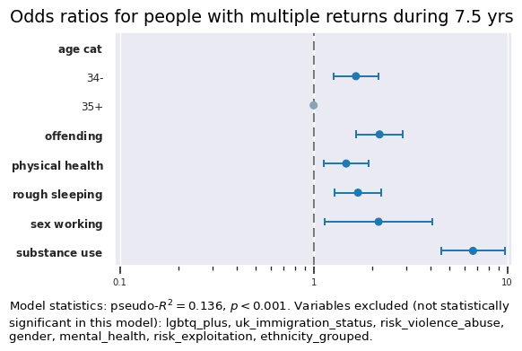

```python
figure_minor_i += 1
ref_cats_used = {k: v for k, v in ref_cats.items() if k in ["age_cat"]}
shorter_iv = {r"uk\ immigration\ status": "immigration"}
cols_removed = [col for col in cols_to_remove if col != "multiple_disadvantage"]
fig_str = plot_odds_r(dv_str, None, ref_cats_used, results_or_final, replacements=shorter_iv, cols_removed=cols_removed, figsize=(6, 4))
plt.show(block=False)
```

# People with a route in top 10% of route durations

## Prepare DV

```python
dv_str = "People with a route in top 10% of route durations"
dv = dv_dict[dv_str].iloc[:, 0]
```

## Prepare IVs

```python
selected_ch = {
    "demographics":  ["gender", "age_cat", "global_majority", "lgbtq_plus",
                      # "ethnicity_detailed", "ethnicity_grouped",
                      # "uk_immigration_status", "english_2nd_language",
                      ],
    "ethnicity_related": ["ethnicity_grouped", "uk_immigration_status"],
    "support_needs": ["offending", "physical_health", "mental_health", "substance_use", "multiple_disadvantage",
                      "rough_sleeping", "sex_working", "risk_violence_abuse", "risk_exploitation",],
    # "route_variables": ["referral_agency", "rt_duration_weeks", "rt_entry_point",]
}
cols_to_exclude = []
X, Xc, iv_df, iv_cols_used, ref_cats, binaries, dummy_cols = get_ivs(dv, cols_to_exclude, selected_ch)
```

## Model building

### Start with block for demographic variables

```python
block_ch = list(selected_ch.values())[0]
block_ch_d = ["(Intercept)"] + cols_with_dummies(block_ch, dummy_cols)
```

### Test associations between IVs for initial block

#### Cramer’s V

**Results**

p values indicated by asterisks: `***` if `p < 0.001`, `**` if `p < 0.01`, `*` if `p < 0.05`

```python
chi2_crv_results, disp = iv_assoc(iv_df, block_ch)
with pd.option_context("display.float_format", "{:,.3f}".format):
    display(disp)
```

| iv1 | iv2 | g | ac | gm | lp |
| --- | --- | --- | --- | --- | --- |
| gender | V | NaN | 0.151 | 0.030 | 0.223 |
|  | * | NaN | *** |  | *** |
| age_cat | V | 0.151 | NaN | 0.109 | 0.089 |
|  | * | *** | NaN | *** | *** |
| global_majority | V | 0.030 | 0.109 | NaN | 0.020 |
|  | * |  | *** | NaN |  |
| lgbtq_plus | V | 0.223 | 0.089 | 0.020 | NaN |
|  | * | *** | *** |  | NaN |

#### Variance Inflation Factor (VIF)

**Results**

```python
# Test multicollinearity with VIF
vif_data = vif(Xc[block_ch_d[1:]])
with pd.option_context("display.float_format", "{:,.3f}".format):
    display(vif_data)
```

| Feature | VIF |
| --- | --- |
| age_cat_34- | 1.400 |
| gender_Female | 1.253 |
| global_majority | 1.190 |
| lgbtq_plus | 1.109 |
| gender_Non-Binary | 1.048 |

### Logit iteration 0

**Results**

```python
cols_to_remove = []
values_to_remove = []
results, summary, results_or = binomial_regression(dv, Xc[block_ch_d], cols_to_remove, dummy_cols)
```

```
Optimization terminated successfully.
         Current function value: 0.404319
         Iterations 6
```

Logit Regression Results

| Dep. Variable: | has_longer_term_rt | No. Observations: | 2823 |
| --- | --- | --- | --- |
| Model: | Logit | Df Residuals: | 2817 |
| Method: | MLE | Df Model: | 5 |
| Date: | Sun, 21 Jun 2026 | Pseudo R-squ.: | 0.01522 |
| Time: | 14:49:56 | Log-Likelihood: | -1141.4 |
| converged: | True | LL-Null: | -1159.0 |
| Covariance Type: | nonrobust | LLR p-value: | 1.318e-06 |

|  | coef | std err | z | P>\|z\| | [0.025 | 0.975] |
| --- | --- | --- | --- | --- | --- | --- |
| (Intercept) | -1.4942 | 0.075 | -19.869 | 0.000 | -1.642 | -1.347 |
| gender_Female | -0.4353 | 0.134 | -3.245 | 0.001 | -0.698 | -0.172 |
| gender_Non-Binary | -0.3458 | 1.061 | -0.326 | 0.745 | -2.426 | 1.734 |
| age_cat_34- | -0.4388 | 0.118 | -3.719 | 0.000 | -0.670 | -0.208 |
| global_majority | -0.0285 | 0.128 | -0.223 | 0.824 | -0.279 | 0.222 |
| lgbtq_plus | -0.4427 | 0.265 | -1.668 | 0.095 | -0.963 | 0.077 |

| Odds Ratios | p | * | odds_r | [0.025 | 0.975] |
| --- | --- | --- | --- | --- | --- |
| global_majority | 0.824 |  | 0.972 | 0.756 | 1.249 |
| gender_Non-Binary | 0.745 |  | 0.708 | 0.088 | 5.665 |
| lgbtq_plus | 0.095 |  | 0.642 | 0.382 | 1.080 |
| gender_Female | 0.001 | * | 0.647 | 0.498 | 0.842 |
| age_cat_34- | 0.000 | * | 0.645 | 0.512 | 0.813 |
| (Intercept) | 0.000 | * | 0.224 | 0.194 | 0.260 |

```
Psuedo R^2: 0.015222917695289495
--------------------------------------------------
```

`global_majority` not significant as variance better explained by other variables

### Logit iteration 1

**Results**

```python
cols_to_remove += ["global_majority"]
results, summary, results_or = binomial_regression(dv, Xc[block_ch_d], cols_to_remove, dummy_cols)
```

```
Optimization terminated successfully.
         Current function value: 0.401873
         Iterations 6
```

Logit Regression Results

| Dep. Variable: | has_longer_term_rt | No. Observations: | 2863 |
| --- | --- | --- | --- |
| Model: | Logit | Df Residuals: | 2858 |
| Method: | MLE | Df Model: | 4 |
| Date: | Sun, 21 Jun 2026 | Pseudo R-squ.: | 0.01558 |
| Time: | 14:49:57 | Log-Likelihood: | -1150.6 |
| converged: | True | LL-Null: | -1168.8 |
| Covariance Type: | nonrobust | LLR p-value: | 2.366e-07 |

|  | coef | std err | z | P>\|z\| | [0.025 | 0.975] |
| --- | --- | --- | --- | --- | --- | --- |
| (Intercept) | -1.5075 | 0.070 | -21.575 | 0.000 | -1.644 | -1.371 |
| gender_Female | -0.4435 | 0.134 | -3.311 | 0.001 | -0.706 | -0.181 |
| gender_Non-Binary | -0.3201 | 1.061 | -0.302 | 0.763 | -2.400 | 1.759 |
| age_cat_34- | -0.4405 | 0.117 | -3.769 | 0.000 | -0.669 | -0.211 |
| lgbtq_plus | -0.4618 | 0.265 | -1.743 | 0.081 | -0.981 | 0.057 |

Variables removed: ['global_majority']

|  | p | * | odds_r | [0.025 | 0.975] | prev_coef | coef | diff_pct |
| --- | --- | --- | --- | --- | --- | --- | --- | --- |
| gender_Non-Binary | 0.763 |  | 0.726 | 0.091 | 5.809 | -0.346 | -0.320 | -7.400 |
| lgbtq_plus | 0.081 |  | 0.630 | 0.375 | 1.059 | -0.443 | -0.462 | 4.300 |
| gender_Female | 0.001 | * | 0.642 | 0.494 | 0.834 | -0.435 | -0.444 | 1.900 |
| age_cat_34- | 0.000 | * | 0.644 | 0.512 | 0.809 | -0.439 | -0.440 | 0.400 |
| (Intercept) | 0.000 | * | 0.221 | 0.193 | 0.254 | -1.494 | -1.508 | 0.900 |

```
Psuedo R^2: 0.015582691191346365
--------------------------------------------------
```

`lgbtq_plus` not significant as variance better explained by other variables

### Logit iteration 2

**Results**

```python
cols_to_remove += ["lgbtq_plus"]
results, summary, results_or = binomial_regression(dv, Xc[block_ch_d], cols_to_remove, dummy_cols)
```

```
Optimization terminated successfully.
         Current function value: 0.391959
         Iterations 7
```

Logit Regression Results

| Dep. Variable: | has_longer_term_rt | No. Observations: | 3685 |
| --- | --- | --- | --- |
| Model: | Logit | Df Residuals: | 3681 |
| Method: | MLE | Df Model: | 3 |
| Date: | Sun, 21 Jun 2026 | Pseudo R-squ.: | 0.01283 |
| Time: | 14:49:57 | Log-Likelihood: | -1444.4 |
| converged: | True | LL-Null: | -1463.1 |
| Covariance Type: | nonrobust | LLR p-value: | 3.535e-08 |

|  | coef | std err | z | P>\|z\| | [0.025 | 0.975] |
| --- | --- | --- | --- | --- | --- | --- |
| (Intercept) | -1.5873 | 0.062 | -25.456 | 0.000 | -1.710 | -1.465 |
| gender_Female | -0.3889 | 0.119 | -3.281 | 0.001 | -0.621 | -0.157 |
| gender_Non-Binary | -1.0113 | 1.031 | -0.981 | 0.327 | -3.031 | 1.009 |
| age_cat_34- | -0.4572 | 0.105 | -4.368 | 0.000 | -0.662 | -0.252 |

Variables removed: ['global_majority', 'lgbtq_plus']

|  | p | * | odds_r | [0.025 | 0.975] | prev_coef | coef | diff_pct |
| --- | --- | --- | --- | --- | --- | --- | --- | --- |
| gender_Non-Binary | 0.327 |  | 0.364 | 0.048 | 2.742 | -0.320 | -1.011 | 215.900 |
| gender_Female | 0.001 | * | 0.678 | 0.537 | 0.855 | -0.444 | -0.389 | -12.300 |
| age_cat_34- | 0.000 | * | 0.633 | 0.516 | 0.777 | -0.440 | -0.457 | 3.800 |
| (Intercept) | 0.000 | * | 0.204 | 0.181 | 0.231 | -1.508 | -1.587 | 5.300 |

```
Psuedo R^2: 0.01282897958178153
--------------------------------------------------
```

### Add block for grouped ethnicity data and drop “global_majority”

```python
new_block_ch = selected_ch["ethnicity_related"]
sel_block_ch = [ch for ch in block_ch + new_block_ch if ch != "global_majority"]
sel_block_ch_d = [ch for ch in block_ch_d + cols_with_dummies(new_block_ch, dummy_cols) if ch != "global_majority"]
```

### Test associations between IVs now a block has been added

#### Cramer’s V

**Results**

p values indicated by asterisks: `***` if `p < 0.001`, `**` if `p < 0.01`, `*` if `p < 0.05`

```python
chi2_crv_results, disp = iv_assoc(iv_df, sel_block_ch)
with pd.option_context("display.float_format", "{:,.3f}".format):
    display(disp)
```

| iv1 | iv2 | g | ac | lp | eg | uis |
| --- | --- | --- | --- | --- | --- | --- |
| gender | V | NaN | 0.131 | 0.235 | 0.051 | 0.048 |
|  | * | NaN | *** | *** | * |  |
| age_cat | V | 0.131 | NaN | 0.096 | 0.105 | 0.093 |
|  | * | *** | NaN | *** | *** | *** |
| lgbtq_plus | V | 0.235 | 0.096 | NaN | 0.069 | 0.012 |
|  | * | *** | *** | NaN | * |  |
| ethnicity_grouped | V | 0.051 | 0.105 | 0.069 | NaN | 0.389 |
|  | * | * | *** | * | NaN | *** |
| uk_immigration_status | V | 0.048 | 0.093 | 0.012 | 0.389 | NaN |
|  | * |  | *** |  | *** | NaN |

#### Variance Inflation Factor (VIF)

**Results**

```python
# Test multicollinearity with VIF
vif_data = vif(Xc[sel_block_ch_d[1:]])
with pd.option_context("display.float_format", "{:,.3f}".format):
    display(vif_data)
```

| Feature | VIF |
| --- | --- |
| uk_immigration_status_Non-EEA National | 1.566 |
| age_cat_34- | 1.393 |
| ethnicity_grouped_Black | 1.357 |
| ethnicity_grouped_Other | 1.316 |
| gender_Female | 1.240 |
| lgbtq_plus | 1.126 |
| gender_Non-Binary | 1.059 |
| ethnicity_grouped_Mixed Heritage | 1.054 |
| uk_immigration_status_EEA National | 1.042 |

No significant multicollinearity. Proceeding with Logit.

```python
results, summary, results_or = binomial_regression(dv, Xc[sel_block_ch_d], [], dummy_cols)
```

### Logit iteration 3

**Results**

```python
results, summary, results_or = binomial_regression(dv, Xc[sel_block_ch_d], cols_to_remove, dummy_cols)
```

```
Optimization terminated successfully.
         Current function value: 0.425704
         Iterations 7
```

Logit Regression Results

| Dep. Variable: | has_longer_term_rt | No. Observations: | 2942 |
| --- | --- | --- | --- |
| Model: | Logit | Df Residuals: | 2933 |
| Method: | MLE | Df Model: | 8 |
| Date: | Sun, 21 Jun 2026 | Pseudo R-squ.: | 0.01555 |
| Time: | 14:49:58 | Log-Likelihood: | -1252.4 |
| converged: | True | LL-Null: | -1272.2 |
| Covariance Type: | nonrobust | LLR p-value: | 3.839e-06 |

|  | coef | std err | z | P>\|z\| | [0.025 | 0.975] |
| --- | --- | --- | --- | --- | --- | --- |
| (Intercept) | -1.4352 | 0.072 | -19.930 | 0.000 | -1.576 | -1.294 |
| gender_Female | -0.3594 | 0.125 | -2.869 | 0.004 | -0.605 | -0.114 |
| gender_Non-Binary | -0.9542 | 1.039 | -0.918 | 0.358 | -2.991 | 1.082 |
| age_cat_34- | -0.5277 | 0.112 | -4.725 | 0.000 | -0.747 | -0.309 |
| ethnicity_grouped_Black | -0.0103 | 0.167 | -0.062 | 0.951 | -0.338 | 0.318 |
| ethnicity_grouped_Other | -0.0929 | 0.252 | -0.368 | 0.713 | -0.588 | 0.402 |
| ethnicity_grouped_Mixed Heritage | 0.3215 | 0.213 | 1.507 | 0.132 | -0.097 | 0.740 |
| uk_immigration_status_Non-EEA National | 0.0183 | 0.211 | 0.087 | 0.931 | -0.395 | 0.431 |
| uk_immigration_status_EEA National | 0.2984 | 0.264 | 1.130 | 0.258 | -0.219 | 0.816 |

Variables removed: ['global_majority', 'lgbtq_plus']

|  | p | * | odds_r | [0.025 | 0.975] | prev_coef | coef | diff_pct |
| --- | --- | --- | --- | --- | --- | --- | --- | --- |
| ethnicity_grouped_Black | 0.951 |  | 0.990 | 0.713 | 1.374 | -0.153 | -0.010 | -93.200 |
| uk_immigration_status_Non-EEA National | 0.931 |  | 1.018 | 0.674 | 1.539 | 0.206 | 0.018 | -91.100 |
| ethnicity_grouped_Other | 0.713 |  | 0.911 | 0.556 | 1.494 | -0.444 | -0.093 | -79.100 |
| gender_Non-Binary | 0.358 |  | 0.385 | 0.050 | 2.951 | -0.525 | -0.954 | 81.700 |
| uk_immigration_status_EEA National | 0.258 |  | 1.348 | 0.803 | 2.261 | 0.599 | 0.298 | -50.200 |
| ethnicity_grouped_Mixed Heritage | 0.132 |  | 1.379 | 0.908 | 2.095 | 0.227 | 0.321 | 41.700 |
| gender_Female | 0.004 | * | 0.698 | 0.546 | 0.892 | -0.440 | -0.359 | -18.300 |
| age_cat_34- | 0.000 | * | 0.590 | 0.474 | 0.734 | -0.507 | -0.528 | 4.100 |
| (Intercept) | 0.000 | * | 0.238 | 0.207 | 0.274 | -1.330 | -1.435 | 7.900 |

```
Psuedo R^2: 0.015554679018835671
--------------------------------------------------
```

`uk_immigration_status` not significant as variance better explained by other variables

### Logit iteration 4

**Results**

```python
cols_to_remove += ["uk_immigration_status"]
results, summary, results_or = binomial_regression(dv, Xc[sel_block_ch_d], cols_to_remove, dummy_cols)
```

```
Optimization terminated successfully.
         Current function value: 0.394512
         Iterations 7
```

Logit Regression Results

| Dep. Variable: | has_longer_term_rt | No. Observations: | 3519 |
| --- | --- | --- | --- |
| Model: | Logit | Df Residuals: | 3512 |
| Method: | MLE | Df Model: | 6 |
| Date: | Sun, 21 Jun 2026 | Pseudo R-squ.: | 0.01359 |
| Time: | 14:49:58 | Log-Likelihood: | -1388.3 |
| converged: | True | LL-Null: | -1407.4 |
| Covariance Type: | nonrobust | LLR p-value: | 9.970e-07 |

|  | coef | std err | z | P>\|z\| | [0.025 | 0.975] |
| --- | --- | --- | --- | --- | --- | --- |
| (Intercept) | -1.5898 | 0.069 | -23.206 | 0.000 | -1.724 | -1.456 |
| gender_Female | -0.4116 | 0.122 | -3.375 | 0.001 | -0.651 | -0.173 |
| gender_Non-Binary | -0.9685 | 1.033 | -0.937 | 0.349 | -2.994 | 1.057 |
| age_cat_34- | -0.4557 | 0.107 | -4.252 | 0.000 | -0.666 | -0.246 |
| ethnicity_grouped_Black | 0.0796 | 0.143 | 0.556 | 0.578 | -0.201 | 0.360 |
| ethnicity_grouped_Other | -0.1437 | 0.222 | -0.647 | 0.517 | -0.579 | 0.291 |
| ethnicity_grouped_Mixed Heritage | 0.2591 | 0.206 | 1.260 | 0.208 | -0.144 | 0.662 |

Variables removed: ['global_majority', 'lgbtq_plus', 'uk_immigration_status']

|  | p | * | odds_r | [0.025 | 0.975] | prev_coef | coef | diff_pct |
| --- | --- | --- | --- | --- | --- | --- | --- | --- |
| ethnicity_grouped_Black | 0.578 |  | 1.083 | 0.818 | 1.434 | -0.010 | 0.080 | -869.100 |
| ethnicity_grouped_Other | 0.517 |  | 0.866 | 0.561 | 1.338 | -0.093 | -0.144 | 54.600 |
| gender_Non-Binary | 0.349 |  | 0.380 | 0.050 | 2.878 | -0.954 | -0.969 | 1.500 |
| ethnicity_grouped_Mixed Heritage | 0.208 |  | 1.296 | 0.866 | 1.939 | 0.321 | 0.259 | -19.400 |
| gender_Female | 0.001 | * | 0.663 | 0.522 | 0.842 | -0.359 | -0.412 | 14.500 |
| age_cat_34- | 0.000 | * | 0.634 | 0.514 | 0.782 | -0.528 | -0.456 | -13.600 |
| (Intercept) | 0.000 | * | 0.204 | 0.178 | 0.233 | -1.435 | -1.590 | 10.800 |

```
Psuedo R^2: 0.013594015287620276
--------------------------------------------------
```

`ethnicity_grouped` not significant as variance better explained by other variables

### Logit iteration 4

**Results**

```python
cols_to_remove += ["ethnicity_grouped"]
results, summary, results_or = binomial_regression(dv, Xc[sel_block_ch_d], cols_to_remove, dummy_cols)
```

```
Optimization terminated successfully.
         Current function value: 0.391959
         Iterations 7
```

Logit Regression Results

| Dep. Variable: | has_longer_term_rt | No. Observations: | 3685 |
| --- | --- | --- | --- |
| Model: | Logit | Df Residuals: | 3681 |
| Method: | MLE | Df Model: | 3 |
| Date: | Sun, 21 Jun 2026 | Pseudo R-squ.: | 0.01283 |
| Time: | 14:49:59 | Log-Likelihood: | -1444.4 |
| converged: | True | LL-Null: | -1463.1 |
| Covariance Type: | nonrobust | LLR p-value: | 3.535e-08 |

|  | coef | std err | z | P>\|z\| | [0.025 | 0.975] |
| --- | --- | --- | --- | --- | --- | --- |
| (Intercept) | -1.5873 | 0.062 | -25.456 | 0.000 | -1.710 | -1.465 |
| gender_Female | -0.3889 | 0.119 | -3.281 | 0.001 | -0.621 | -0.157 |
| gender_Non-Binary | -1.0113 | 1.031 | -0.981 | 0.327 | -3.031 | 1.009 |
| age_cat_34- | -0.4572 | 0.105 | -4.368 | 0.000 | -0.662 | -0.252 |

Variables removed: ['global_majority', 'lgbtq_plus', 'uk_immigration_status', 'ethnicity_grouped']

|  | p | * | odds_r | [0.025 | 0.975] | prev_coef | coef | diff_pct |
| --- | --- | --- | --- | --- | --- | --- | --- | --- |
| gender_Non-Binary | 0.327 |  | 0.364 | 0.048 | 2.742 | -0.969 | -1.011 | 4.400 |
| gender_Female | 0.001 | * | 0.678 | 0.537 | 0.855 | -0.412 | -0.389 | -5.500 |
| age_cat_34- | 0.000 | * | 0.633 | 0.516 | 0.777 | -0.456 | -0.457 | 0.300 |
| (Intercept) | 0.000 | * | 0.204 | 0.181 | 0.231 | -1.590 | -1.587 | -0.200 |

```
Psuedo R^2: 0.01282897958178153
--------------------------------------------------
```

### Add block for support needs variables

```python
new_block_ch = selected_ch["support_needs"]
sel_block_ch = block_ch + new_block_ch
sel_block_ch_d = sel_block_ch_d + cols_with_dummies(new_block_ch, dummy_cols)
```

### Test associations between IVs now a block has been added

#### Cramer’s V

**Results**

p values indicated by asterisks: `***` if `p < 0.001`, `**` if `p < 0.01`, `*` if `p < 0.05`

```python
chi2_crv_results, disp = iv_assoc(iv_df, sel_block_ch)
with pd.option_context("display.float_format", "{:,.3f}".format):
    display(disp)
```

| iv1 | iv2 | g | ac | gm | lp | o | ph | mh | su | md | rs | sw | rva | re |
| --- | --- | --- | --- | --- | --- | --- | --- | --- | --- | --- | --- | --- | --- | --- |
| gender | V | NaN | 0.133 | 0.041 | 0.236 | 0.164 | 0.050 | 0.096 | 0.080 | 0.030 | 0.068 | 0.227 | 0.348 | 0.124 |
|  | * | NaN | *** |  | *** | *** |  | *** | ** |  | * | *** | *** | *** |
| age_cat | V | 0.133 | NaN | 0.105 | 0.099 | 0.008 | 0.194 | 0.065 | 0.158 | 0.043 | 0.017 | 0.035 | 0.052 | 0.015 |
|  | * | *** | NaN | *** | *** |  | *** | ** | *** | * |  |  | * |  |
| global_majority | V | 0.041 | 0.105 | NaN | 0.014 | 0.063 | 0.069 | 0.095 | 0.268 | 0.201 | 0.061 | 0.065 | 0.026 | 0.065 |
|  | * |  | *** | NaN |  | ** | *** | *** | *** | *** | ** | ** |  | ** |
| lgbtq_plus | V | 0.236 | 0.099 | 0.014 | NaN | 0.031 | 0.006 | 0.047 | 0.056 | 0.030 | 0.023 | 0.022 | 0.018 | 0.009 |
|  | * | *** | *** |  | NaN |  |  | * | ** |  |  |  |  |  |
| offending | V | 0.164 | 0.008 | 0.063 | 0.031 | NaN | 0.011 | 0.045 | 0.149 | 0.336 | 0.084 | 0.016 | 0.044 | 0.010 |
|  | * | *** |  | ** |  | NaN |  | * | *** | *** | *** |  | * |  |
| physical_health | V | 0.050 | 0.194 | 0.069 | 0.006 | 0.011 | NaN | 0.085 | 0.083 | 0.089 | 0.081 | 0.033 | 0.042 | 0.083 |
|  | * |  | *** | *** |  |  | NaN | *** | *** | *** | *** |  |  | *** |
| mental_health | V | 0.096 | 0.065 | 0.095 | 0.047 | 0.045 | 0.085 | NaN | 0.168 | 0.533 | 0.079 | 0.079 | 0.062 | 0.073 |
|  | * | *** | ** | *** | * | * | *** | NaN | *** | *** | *** | *** | ** | *** |
| substance_use | V | 0.080 | 0.158 | 0.268 | 0.056 | 0.149 | 0.083 | 0.168 | NaN | 0.659 | 0.197 | 0.106 | 0.001 | 0.105 |
|  | * | ** | *** | *** | ** | *** | *** | *** | NaN | *** | *** | *** |  | *** |
| multiple_disadvantage | V | 0.030 | 0.043 | 0.201 | 0.030 | 0.336 | 0.089 | 0.533 | 0.659 | NaN | 0.172 | 0.112 | 0.284 | 0.150 |
|  | * |  | * | *** |  | *** | *** | *** | *** | NaN | *** | *** | *** | *** |
| rough_sleeping | V | 0.068 | 0.017 | 0.061 | 0.023 | 0.084 | 0.081 | 0.079 | 0.197 | 0.172 | NaN | 0.078 | 0.035 | 0.015 |
|  | * | * |  | ** |  | *** | *** | *** | *** | *** | NaN | *** |  |  |
| sex_working | V | 0.227 | 0.035 | 0.065 | 0.022 | 0.016 | 0.033 | 0.079 | 0.106 | 0.112 | 0.078 | NaN | 0.211 | 0.202 |
|  | * | *** |  | ** |  |  |  | *** | *** | *** | *** | NaN | *** | *** |
| risk_violence_abuse | V | 0.348 | 0.052 | 0.026 | 0.018 | 0.044 | 0.042 | 0.062 | 0.001 | 0.284 | 0.035 | 0.211 | NaN | 0.236 |
|  | * | *** | * |  |  | * |  | ** |  | *** |  | *** | NaN | *** |
| risk_exploitation | V | 0.124 | 0.015 | 0.065 | 0.009 | 0.010 | 0.083 | 0.073 | 0.105 | 0.150 | 0.015 | 0.202 | 0.236 | NaN |
|  | * | *** |  | ** |  |  | *** | *** | *** | *** |  | *** | *** | NaN |

#### Variance Inflation Factor (VIF)

**Results**

```python
# Test multicollinearity with VIF
vif_data = vif(Xc[sel_block_ch_d[1:]])
with pd.option_context("display.float_format", "{:,.3f}".format):
    display(vif_data)
```

| Feature | VIF |
| --- | --- |
| multiple_disadvantage | 7.960 |
| mental_health | 4.342 |
| substance_use | 4.055 |
| risk_violence_abuse | 1.790 |
| age_cat_34- | 1.676 |
| gender_Female | 1.674 |
| uk_immigration_status_Non-EEA National | 1.584 |
| physical_health | 1.554 |
| offending | 1.474 |
| ethnicity_grouped_Black | 1.398 |
| ethnicity_grouped_Other | 1.343 |
| rough_sleeping | 1.314 |
| risk_exploitation | 1.199 |
| lgbtq_plus | 1.144 |
| sex_working | 1.140 |
| gender_Non-Binary | 1.073 |
| ethnicity_grouped_Mixed Heritage | 1.070 |
| uk_immigration_status_EEA National | 1.051 |

`multiple_disadvantage` has high VIF due to multicollinearity of `multiple_disadvantage`, `substance_use` and `mental_health`.

Running without `multiple_disadvantage` as for both previous dvs separate needs variables had greater explanatory power

```python
sel_block_ch_d.remove("multiple_disadvantage")
```

```python
results, summary, results_or = binomial_regression(dv, Xc[sel_block_ch_d], [], dummy_cols)
```

### Logit iteration 5

**Results**

```python
results, summary, results_or = binomial_regression(dv, Xc[sel_block_ch_d], cols_to_remove, dummy_cols)
```

```
Optimization terminated successfully.
         Current function value: 0.401700
         Iterations 7
```

Logit Regression Results

| Dep. Variable: | has_longer_term_rt | No. Observations: | 3032 |
| --- | --- | --- | --- |
| Model: | Logit | Df Residuals: | 3020 |
| Method: | MLE | Df Model: | 11 |
| Date: | Sun, 21 Jun 2026 | Pseudo R-squ.: | 0.05632 |
| Time: | 14:50:01 | Log-Likelihood: | -1218.0 |
| converged: | True | LL-Null: | -1290.6 |
| Covariance Type: | nonrobust | LLR p-value: | 1.314e-25 |

|  | coef | std err | z | P>\|z\| | [0.025 | 0.975] |
| --- | --- | --- | --- | --- | --- | --- |
| (Intercept) | -1.3009 | 0.122 | -10.642 | 0.000 | -1.541 | -1.061 |
| gender_Female | -0.4564 | 0.136 | -3.365 | 0.001 | -0.722 | -0.191 |
| gender_Non-Binary | -0.9862 | 1.040 | -0.949 | 0.343 | -3.024 | 1.051 |
| age_cat_34- | -0.4811 | 0.116 | -4.137 | 0.000 | -0.709 | -0.253 |
| offending | -0.8020 | 0.169 | -4.738 | 0.000 | -1.134 | -0.470 |
| physical_health | 0.1945 | 0.108 | 1.795 | 0.073 | -0.018 | 0.407 |
| mental_health | -0.0214 | 0.115 | -0.186 | 0.853 | -0.247 | 0.204 |
| substance_use | 0.1966 | 0.109 | 1.807 | 0.071 | -0.017 | 0.410 |
| rough_sleeping | -1.2554 | 0.177 | -7.074 | 0.000 | -1.603 | -0.908 |
| sex_working | 0.4136 | 0.420 | 0.984 | 0.325 | -0.410 | 1.238 |
| risk_violence_abuse | -0.3316 | 0.163 | -2.033 | 0.042 | -0.651 | -0.012 |
| risk_exploitation | 0.4831 | 0.184 | 2.631 | 0.009 | 0.123 | 0.843 |

Variables removed: ['global_majority', 'lgbtq_plus', 'uk_immigration_status', 'ethnicity_grouped']

|  | p | * | odds_r | [0.025 | 0.975] | prev_coef | coef | diff_pct |
| --- | --- | --- | --- | --- | --- | --- | --- | --- |
| mental_health | 0.853 |  | 0.979 | 0.781 | 1.226 | -0.024 | -0.021 | -11.900 |
| gender_Non-Binary | 0.343 |  | 0.373 | 0.049 | 2.862 | -0.503 | -0.986 | 95.900 |
| sex_working | 0.325 |  | 1.512 | 0.663 | 3.448 | 0.319 | 0.414 | 29.800 |
| physical_health | 0.073 |  | 1.215 | 0.982 | 1.502 | 0.311 | 0.195 | -37.500 |
| substance_use | 0.071 |  | 1.217 | 0.983 | 1.507 | 0.195 | 0.197 | 0.800 |
| risk_violence_abuse | 0.042 | * | 0.718 | 0.521 | 0.988 | -0.339 | -0.332 | -2.100 |
| risk_exploitation | 0.009 | * | 1.621 | 1.131 | 2.323 | 0.704 | 0.483 | -31.400 |
| gender_Female | 0.001 | * | 0.634 | 0.486 | 0.826 | -0.593 | -0.456 | -23.000 |
| age_cat_34- | 0.000 | * | 0.618 | 0.492 | 0.776 | -0.404 | -0.481 | 19.200 |
| offending | 0.000 | * | 0.448 | 0.322 | 0.625 | -1.071 | -0.802 | -25.100 |
| rough_sleeping | 0.000 | * | 0.285 | 0.201 | 0.404 | -1.301 | -1.255 | -3.500 |
| (Intercept) | 0.000 | * | 0.272 | 0.214 | 0.346 | -1.247 | -1.301 | 4.400 |

```
Psuedo R^2: 0.05631666609577124
--------------------------------------------------
```

### Logit iteration 6

**Results**

```python
cols_to_remove += ["mental_health"]
results, summary, results_or = binomial_regression(dv, Xc[sel_block_ch_d], cols_to_remove, dummy_cols)
```

```
Optimization terminated successfully.
         Current function value: 0.401706
         Iterations 7
```

Logit Regression Results

| Dep. Variable: | has_longer_term_rt | No. Observations: | 3032 |
| --- | --- | --- | --- |
| Model: | Logit | Df Residuals: | 3021 |
| Method: | MLE | Df Model: | 10 |
| Date: | Sun, 21 Jun 2026 | Pseudo R-squ.: | 0.05630 |
| Time: | 14:50:01 | Log-Likelihood: | -1218.0 |
| converged: | True | LL-Null: | -1290.6 |
| Covariance Type: | nonrobust | LLR p-value: | 3.391e-26 |

|  | coef | std err | z | P>\|z\| | [0.025 | 0.975] |
| --- | --- | --- | --- | --- | --- | --- |
| (Intercept) | -1.3121 | 0.107 | -12.314 | 0.000 | -1.521 | -1.103 |
| gender_Female | -0.4581 | 0.135 | -3.386 | 0.001 | -0.723 | -0.193 |
| gender_Non-Binary | -0.9859 | 1.040 | -0.948 | 0.343 | -3.024 | 1.052 |
| age_cat_34- | -0.4831 | 0.116 | -4.172 | 0.000 | -0.710 | -0.256 |
| offending | -0.8027 | 0.169 | -4.743 | 0.000 | -1.134 | -0.471 |
| physical_health | 0.1935 | 0.108 | 1.788 | 0.074 | -0.019 | 0.406 |
| substance_use | 0.1934 | 0.107 | 1.800 | 0.072 | -0.017 | 0.404 |
| rough_sleeping | -1.2561 | 0.177 | -7.079 | 0.000 | -1.604 | -0.908 |
| sex_working | 0.4117 | 0.420 | 0.979 | 0.327 | -0.412 | 1.235 |
| risk_violence_abuse | -0.3323 | 0.163 | -2.038 | 0.042 | -0.652 | -0.013 |
| risk_exploitation | 0.4815 | 0.183 | 2.625 | 0.009 | 0.122 | 0.841 |

Variables removed: ['global_majority', 'lgbtq_plus', 'uk_immigration_status', 'ethnicity_grouped', 'mental_health']

|  | p | * | odds_r | [0.025 | 0.975] | prev_coef | coef | diff_pct |
| --- | --- | --- | --- | --- | --- | --- | --- | --- |
| gender_Non-Binary | 0.343 |  | 0.373 | 0.049 | 2.863 | -0.986 | -0.986 | -0.000 |
| sex_working | 0.327 |  | 1.509 | 0.662 | 3.440 | 0.414 | 0.412 | -0.500 |
| physical_health | 0.074 |  | 1.213 | 0.982 | 1.500 | 0.195 | 0.193 | -0.500 |
| substance_use | 0.072 |  | 1.213 | 0.983 | 1.498 | 0.197 | 0.193 | -1.600 |
| risk_violence_abuse | 0.042 | * | 0.717 | 0.521 | 0.987 | -0.332 | -0.332 | 0.200 |
| risk_exploitation | 0.009 | * | 1.618 | 1.130 | 2.319 | 0.483 | 0.481 | -0.300 |
| gender_Female | 0.001 | * | 0.632 | 0.485 | 0.825 | -0.456 | -0.458 | 0.400 |
| age_cat_34- | 0.000 | * | 0.617 | 0.492 | 0.774 | -0.481 | -0.483 | 0.400 |
| offending | 0.000 | * | 0.448 | 0.322 | 0.624 | -0.802 | -0.803 | 0.100 |
| rough_sleeping | 0.000 | * | 0.285 | 0.201 | 0.403 | -1.255 | -1.256 | 0.100 |
| (Intercept) | 0.000 | * | 0.269 | 0.219 | 0.332 | -1.301 | -1.312 | 0.900 |

```
Psuedo R^2: 0.05630331648761
--------------------------------------------------
```

### Logit iteration 7

**Results**

```python
cols_to_remove += ["sex_working"]
results, summary, results_or = binomial_regression(dv, Xc[sel_block_ch_d], cols_to_remove, dummy_cols)
```

```
Optimization terminated successfully.
         Current function value: 0.401853
         Iterations 7
```

Logit Regression Results

| Dep. Variable: | has_longer_term_rt | No. Observations: | 3032 |
| --- | --- | --- | --- |
| Model: | Logit | Df Residuals: | 3022 |
| Method: | MLE | Df Model: | 9 |
| Date: | Sun, 21 Jun 2026 | Pseudo R-squ.: | 0.05596 |
| Time: | 14:50:02 | Log-Likelihood: | -1218.4 |
| converged: | True | LL-Null: | -1290.6 |
| Covariance Type: | nonrobust | LLR p-value: | 1.249e-26 |

|  | coef | std err | z | P>\|z\| | [0.025 | 0.975] |
| --- | --- | --- | --- | --- | --- | --- |
| (Intercept) | -1.3201 | 0.106 | -12.415 | 0.000 | -1.528 | -1.112 |
| gender_Female | -0.4343 | 0.132 | -3.282 | 0.001 | -0.694 | -0.175 |
| gender_Non-Binary | -0.9760 | 1.040 | -0.938 | 0.348 | -3.014 | 1.062 |
| age_cat_34- | -0.4825 | 0.116 | -4.167 | 0.000 | -0.709 | -0.256 |
| offending | -0.7987 | 0.169 | -4.720 | 0.000 | -1.130 | -0.467 |
| physical_health | 0.1943 | 0.108 | 1.796 | 0.073 | -0.018 | 0.406 |
| substance_use | 0.1998 | 0.107 | 1.864 | 0.062 | -0.010 | 0.410 |
| rough_sleeping | -1.2496 | 0.177 | -7.049 | 0.000 | -1.597 | -0.902 |
| risk_violence_abuse | -0.3205 | 0.162 | -1.977 | 0.048 | -0.638 | -0.003 |
| risk_exploitation | 0.5037 | 0.182 | 2.773 | 0.006 | 0.148 | 0.860 |

Variables removed: ['global_majority', 'lgbtq_plus', 'uk_immigration_status', 'ethnicity_grouped', 'mental_health', 'sex_working']

|  | p | * | odds_r | [0.025 | 0.975] | prev_coef | coef | diff_pct |
| --- | --- | --- | --- | --- | --- | --- | --- | --- |
| gender_Non-Binary | 0.348 |  | 0.377 | 0.049 | 2.893 | -0.986 | -0.976 | -1.000 |
| physical_health | 0.073 |  | 1.215 | 0.982 | 1.501 | 0.193 | 0.194 | 0.400 |
| substance_use | 0.062 |  | 1.221 | 0.990 | 1.507 | 0.193 | 0.200 | 3.300 |
| risk_violence_abuse | 0.048 | * | 0.726 | 0.528 | 0.997 | -0.332 | -0.320 | -3.600 |
| risk_exploitation | 0.006 | * | 1.655 | 1.159 | 2.362 | 0.481 | 0.504 | 4.600 |
| gender_Female | 0.001 | * | 0.648 | 0.500 | 0.839 | -0.458 | -0.434 | -5.200 |
| age_cat_34- | 0.000 | * | 0.617 | 0.492 | 0.774 | -0.483 | -0.482 | -0.100 |
| offending | 0.000 | * | 0.450 | 0.323 | 0.627 | -0.803 | -0.799 | -0.500 |
| rough_sleeping | 0.000 | * | 0.287 | 0.202 | 0.406 | -1.256 | -1.250 | -0.500 |
| (Intercept) | 0.000 | * | 0.267 | 0.217 | 0.329 | -1.312 | -1.320 | 0.600 |

```
Psuedo R^2: 0.05595624039384994
--------------------------------------------------
```

### Logit iteration 8

**Results**

```python
cols_to_remove += ["physical_health"]
results, summary, results_or = binomial_regression(dv, Xc[sel_block_ch_d], cols_to_remove, dummy_cols)
```

```
Optimization terminated successfully.
         Current function value: 0.402381
         Iterations 7
```

Logit Regression Results

| Dep. Variable: | has_longer_term_rt | No. Observations: | 3032 |
| --- | --- | --- | --- |
| Model: | Logit | Df Residuals: | 3023 |
| Method: | MLE | Df Model: | 8 |
| Date: | Sun, 21 Jun 2026 | Pseudo R-squ.: | 0.05472 |
| Time: | 14:50:02 | Log-Likelihood: | -1220.0 |
| converged: | True | LL-Null: | -1290.6 |
| Covariance Type: | nonrobust | LLR p-value: | 1.312e-26 |

|  | coef | std err | z | P>\|z\| | [0.025 | 0.975] |
| --- | --- | --- | --- | --- | --- | --- |
| (Intercept) | -1.2352 | 0.095 | -13.053 | 0.000 | -1.421 | -1.050 |
| gender_Female | -0.4392 | 0.132 | -3.315 | 0.001 | -0.699 | -0.180 |
| gender_Non-Binary | -0.9997 | 1.040 | -0.961 | 0.337 | -3.039 | 1.039 |
| age_cat_34- | -0.5230 | 0.114 | -4.607 | 0.000 | -0.745 | -0.301 |
| offending | -0.8025 | 0.169 | -4.744 | 0.000 | -1.134 | -0.471 |
| substance_use | 0.2015 | 0.107 | 1.881 | 0.060 | -0.008 | 0.411 |
| rough_sleeping | -1.2367 | 0.177 | -6.988 | 0.000 | -1.584 | -0.890 |
| risk_violence_abuse | -0.3085 | 0.162 | -1.903 | 0.057 | -0.626 | 0.009 |
| risk_exploitation | 0.5262 | 0.181 | 2.906 | 0.004 | 0.171 | 0.881 |

Variables removed: ['global_majority', 'lgbtq_plus', 'uk_immigration_status', 'ethnicity_grouped', 'mental_health', 'sex_working', 'physical_health']

|  | p | * | odds_r | [0.025 | 0.975] | prev_coef | coef | diff_pct |
| --- | --- | --- | --- | --- | --- | --- | --- | --- |
| gender_Non-Binary | 0.337 |  | 0.368 | 0.048 | 2.828 | -0.976 | -1.000 | 2.400 |
| substance_use | 0.060 |  | 1.223 | 0.992 | 1.509 | 0.200 | 0.201 | 0.800 |
| risk_violence_abuse | 0.057 |  | 0.735 | 0.535 | 1.009 | -0.320 | -0.308 | -3.700 |
| risk_exploitation | 0.004 | * | 1.693 | 1.187 | 2.414 | 0.504 | 0.526 | 4.500 |
| gender_Female | 0.001 | * | 0.645 | 0.497 | 0.836 | -0.434 | -0.439 | 1.100 |
| age_cat_34- | 0.000 | * | 0.593 | 0.475 | 0.740 | -0.482 | -0.523 | 8.400 |
| offending | 0.000 | * | 0.448 | 0.322 | 0.624 | -0.799 | -0.803 | 0.500 |
| rough_sleeping | 0.000 | * | 0.290 | 0.205 | 0.411 | -1.250 | -1.237 | -1.000 |
| (Intercept) | 0.000 | * | 0.291 | 0.242 | 0.350 | -1.320 | -1.235 | -6.400 |

```
Psuedo R^2: 0.054715775194503546
--------------------------------------------------
```

### Logit iteration 9

**Results**

```python
cols_to_remove += ["substance_use"]
results, summary, results_or = binomial_regression(dv, Xc[sel_block_ch_d], cols_to_remove, dummy_cols)
```

```
Optimization terminated successfully.
         Current function value: 0.402967
         Iterations 7
```

Logit Regression Results

| Dep. Variable: | has_longer_term_rt | No. Observations: | 3032 |
| --- | --- | --- | --- |
| Model: | Logit | Df Residuals: | 3024 |
| Method: | MLE | Df Model: | 7 |
| Date: | Sun, 21 Jun 2026 | Pseudo R-squ.: | 0.05334 |
| Time: | 14:50:02 | Log-Likelihood: | -1221.8 |
| converged: | True | LL-Null: | -1290.6 |
| Covariance Type: | nonrobust | LLR p-value: | 1.550e-26 |

|  | coef | std err | z | P>\|z\| | [0.025 | 0.975] |
| --- | --- | --- | --- | --- | --- | --- |
| (Intercept) | -1.1290 | 0.075 | -15.087 | 0.000 | -1.276 | -0.982 |
| gender_Female | -0.4520 | 0.132 | -3.416 | 0.001 | -0.711 | -0.193 |
| gender_Non-Binary | -1.0233 | 1.040 | -0.984 | 0.325 | -3.061 | 1.015 |
| age_cat_34- | -0.5511 | 0.113 | -4.898 | 0.000 | -0.772 | -0.331 |
| offending | -0.7718 | 0.168 | -4.584 | 0.000 | -1.102 | -0.442 |
| rough_sleeping | -1.1972 | 0.176 | -6.814 | 0.000 | -1.542 | -0.853 |
| risk_violence_abuse | -0.3096 | 0.162 | -1.911 | 0.056 | -0.627 | 0.008 |
| risk_exploitation | 0.5655 | 0.180 | 3.146 | 0.002 | 0.213 | 0.918 |

Variables removed: ['global_majority', 'lgbtq_plus', 'uk_immigration_status', 'ethnicity_grouped', 'mental_health', 'sex_working', 'physical_health', 'substance_use']

|  | p | * | odds_r | [0.025 | 0.975] | prev_coef | coef | diff_pct |
| --- | --- | --- | --- | --- | --- | --- | --- | --- |
| gender_Non-Binary | 0.325 |  | 0.359 | 0.047 | 2.759 | -1.000 | -1.023 | 2.400 |
| risk_violence_abuse | 0.056 |  | 0.734 | 0.534 | 1.008 | -0.308 | -0.310 | 0.400 |
| risk_exploitation | 0.002 | * | 1.760 | 1.238 | 2.504 | 0.526 | 0.565 | 7.500 |
| gender_Female | 0.001 | * | 0.636 | 0.491 | 0.825 | -0.439 | -0.452 | 2.900 |
| offending | 0.000 | * | 0.462 | 0.332 | 0.643 | -0.803 | -0.772 | -3.800 |
| age_cat_34- | 0.000 | * | 0.576 | 0.462 | 0.718 | -0.523 | -0.551 | 5.400 |
| rough_sleeping | 0.000 | * | 0.302 | 0.214 | 0.426 | -1.237 | -1.197 | -3.200 |
| (Intercept) | 0.000 | * | 0.323 | 0.279 | 0.374 | -1.235 | -1.129 | -8.600 |

```
Psuedo R^2: 0.053341258352469056
--------------------------------------------------
```

### Logit iteration 10

**Results**

```python
cols_to_remove += ["risk_violence_abuse"]
results, summary, results_or = binomial_regression(dv, Xc[sel_block_ch_d], cols_to_remove, dummy_cols)
```

```
Optimization terminated successfully.
         Current function value: 0.403593
         Iterations 7
```

Logit Regression Results

| Dep. Variable: | has_longer_term_rt | No. Observations: | 3032 |
| --- | --- | --- | --- |
| Model: | Logit | Df Residuals: | 3025 |
| Method: | MLE | Df Model: | 6 |
| Date: | Sun, 21 Jun 2026 | Pseudo R-squ.: | 0.05187 |
| Time: | 14:50:02 | Log-Likelihood: | -1223.7 |
| converged: | True | LL-Null: | -1290.6 |
| Covariance Type: | nonrobust | LLR p-value: | 1.949e-26 |

|  | coef | std err | z | P>\|z\| | [0.025 | 0.975] |
| --- | --- | --- | --- | --- | --- | --- |
| (Intercept) | -1.1472 | 0.074 | -15.452 | 0.000 | -1.293 | -1.002 |
| gender_Female | -0.5288 | 0.127 | -4.172 | 0.000 | -0.777 | -0.280 |
| gender_Non-Binary | -1.1156 | 1.038 | -1.075 | 0.282 | -3.150 | 0.919 |
| age_cat_34- | -0.5562 | 0.112 | -4.947 | 0.000 | -0.777 | -0.336 |
| offending | -0.7740 | 0.168 | -4.600 | 0.000 | -1.104 | -0.444 |
| rough_sleeping | -1.2077 | 0.176 | -6.879 | 0.000 | -1.552 | -0.864 |
| risk_exploitation | 0.4898 | 0.175 | 2.796 | 0.005 | 0.146 | 0.833 |

Variables removed: ['global_majority', 'lgbtq_plus', 'uk_immigration_status', 'ethnicity_grouped', 'mental_health', 'sex_working', 'physical_health', 'substance_use', 'risk_violence_abuse']

|  | p | * | odds_r | [0.025 | 0.975] | prev_coef | coef | diff_pct |
| --- | --- | --- | --- | --- | --- | --- | --- | --- |
| gender_Non-Binary | 0.282 |  | 0.328 | 0.043 | 2.506 | -1.023 | -1.116 | 9.000 |
| risk_exploitation | 0.005 | * | 1.632 | 1.158 | 2.300 | 0.565 | 0.490 | -13.400 |
| gender_Female | 0.000 | * | 0.589 | 0.460 | 0.756 | -0.452 | -0.529 | 17.000 |
| offending | 0.000 | * | 0.461 | 0.332 | 0.641 | -0.772 | -0.774 | 0.300 |
| age_cat_34- | 0.000 | * | 0.573 | 0.460 | 0.715 | -0.551 | -0.556 | 0.900 |
| rough_sleeping | 0.000 | * | 0.299 | 0.212 | 0.422 | -1.197 | -1.208 | 0.900 |
| (Intercept) | 0.000 | * | 0.318 | 0.275 | 0.367 | -1.129 | -1.147 | 1.600 |

```
Psuedo R^2: 0.05186903284999922
--------------------------------------------------
```

Remaining variables are all significant in this model.

## Final model

```python
display(summary)
results_or_final = results_or.drop(columns=["prev_coef", "coef", "diff_pct"]).sort_index()
results_or_with_pct = add_interpretation_cols(results_or_final)
with pd.option_context("display.float_format", "{:,.3f}".format):
    display(results_or_with_pct)

tbl_i = 0
for tbl in results.summary2().tables:
    excel_output[f"Logit: '{dv_str}', table {tbl_i}"] = tbl
    tbl_i += 1
excel_output[f"Logit: '{dv_str}', odds ratios"] = results_or_with_pct
```

Logit Regression Results

| Dep. Variable: | has_longer_term_rt | No. Observations: | 3032 |
| --- | --- | --- | --- |
| Model: | Logit | Df Residuals: | 3025 |
| Method: | MLE | Df Model: | 6 |
| Date: | Sun, 21 Jun 2026 | Pseudo R-squ.: | 0.05187 |
| Time: | 14:50:02 | Log-Likelihood: | -1223.7 |
| converged: | True | LL-Null: | -1290.6 |
| Covariance Type: | nonrobust | LLR p-value: | 1.949e-26 |

|  | coef | std err | z | P>\|z\| | [0.025 | 0.975] |
| --- | --- | --- | --- | --- | --- | --- |
| (Intercept) | -1.1472 | 0.074 | -15.452 | 0.000 | -1.293 | -1.002 |
| gender_Female | -0.5288 | 0.127 | -4.172 | 0.000 | -0.777 | -0.280 |
| gender_Non-Binary | -1.1156 | 1.038 | -1.075 | 0.282 | -3.150 | 0.919 |
| age_cat_34- | -0.5562 | 0.112 | -4.947 | 0.000 | -0.777 | -0.336 |
| offending | -0.7740 | 0.168 | -4.600 | 0.000 | -1.104 | -0.444 |
| rough_sleeping | -1.2077 | 0.176 | -6.879 | 0.000 | -1.552 | -0.864 |
| risk_exploitation | 0.4898 | 0.175 | 2.796 | 0.005 | 0.146 | 0.833 |

Variables removed: ['global_majority', 'lgbtq_plus', 'uk_immigration_status', 'ethnicity_grouped', 'mental_health', 'sex_working', 'physical_health', 'substance_use', 'risk_violence_abuse']

|  | p | * | odds_r | [0.025 | 0.975] | odds_r_d% | [0.025_d% | 0.975]_d% |
| --- | --- | --- | --- | --- | --- | --- | --- | --- |
| (Intercept) | 0.000 | * | 0.318 | 0.275 | 0.367 | -68.2% | -72.5% | -63.3% |
| age_cat_34- | 0.000 | * | 0.573 | 0.460 | 0.715 | -42.7% | -54.0% | -28.5% |
| gender_Female | 0.000 | * | 0.589 | 0.460 | 0.756 | -41.1% | -54.0% | -24.4% |
| gender_Non-Binary | 0.282 |  | 0.328 | 0.043 | 2.506 |  |  |  |
| offending | 0.000 | * | 0.461 | 0.332 | 0.641 | -53.9% | -66.8% | -35.9% |
| risk_exploitation | 0.005 | * | 1.632 | 1.158 | 2.300 | 63.2% | 15.8% | 130.0% |
| rough_sleeping | 0.000 | * | 0.299 | 0.212 | 0.422 | -70.1% | -78.8% | -57.8% |

## Visualisation

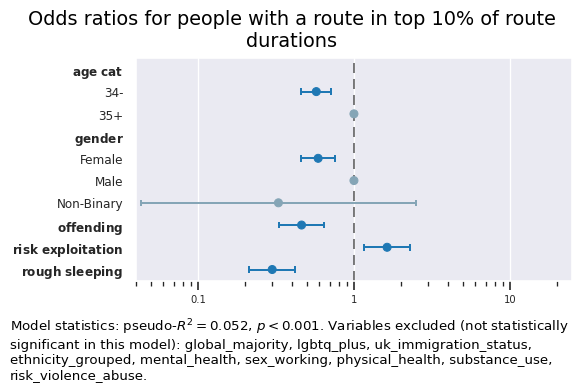

```python
figure_minor_i += 1
ref_cats_used = {k: v for k, v in ref_cats.items() if k in ["age_cat", "gender"]}
shorter_iv = {r"uk\ immigration\ status": "immigration"}
cols_removed = [col for col in cols_to_remove if col != "multiple_disadvantage"]
fig_str = plot_odds_r(dv_str, None, ref_cats_used, results_or_final, replacements=shorter_iv, cols_removed=cols_removed, figsize=(6, 4), x_max=1/0.04)
plt.show(block=False)
```

# Returns within 2 years after moving to independent accommodation

## Prepare DV

```python
# Get DV
dv_str = "Returns within 2 years after moving to independent accommodation"
dv = dv_dict[dv_str].iloc[:, 0].map({"Yes": True, "No": False})
```

## Prepare IVs

```python
selected_ch = {
    "demographics":  ["gender", "age_cat", "global_majority", "lgbtq_plus",
                      # "ethnicity_detailed", "ethnicity_grouped",
                      # "uk_immigration_status", "english_2nd_language",
                      ],
    "ethnicity_related": ["ethnicity_grouped", "uk_immigration_status"],
    "support_needs": ["offending", "physical_health", "mental_health", "substance_use", "multiple_disadvantage",
                      "rough_sleeping", "sex_working", "risk_violence_abuse", "risk_exploitation",],
    # "route_variables": ["referral_agency", "rt_duration_weeks", "rt_entry_point",]
}
cols_to_exclude = []
X, Xc, iv_df, iv_cols_used, ref_cats, binaries, dummy_cols = get_ivs(dv, cols_to_exclude, selected_ch)
```

## Model building

### Start with block for demographic variables

```python
block_ch = list(selected_ch.values())[0]
block_ch_d = ["(Intercept)"] + cols_with_dummies(block_ch, dummy_cols)
```

### Test associations between IVs for initial block

#### Cramer’s V

**Results**

p values indicated by asterisks: `***` if `p < 0.001`, `**` if `p < 0.01`, `*` if `p < 0.05`

```python
chi2_crv_results, disp = iv_assoc(iv_df, block_ch)
with pd.option_context("display.float_format", "{:,.3f}".format):
    display(disp)
```

| iv1 | iv2 | g | ac | gm | lp |
| --- | --- | --- | --- | --- | --- |
| gender | V | NaN | 0.155 | 0.104 | 0.149 |
|  | * | NaN | *** | * | *** |
| age_cat | V | 0.155 | NaN | 0.083 | 0.069 |
|  | * | *** | NaN | * |  |
| global_majority | V | 0.104 | 0.083 | NaN | 0.038 |
|  | * | * | * | NaN |  |
| lgbtq_plus | V | 0.149 | 0.069 | 0.038 | NaN |
|  | * | *** |  |  | NaN |

#### Variance Inflation Factor (VIF)

**Results**

```python
# Test multicollinearity with VIF
vif_data = vif(Xc[block_ch_d[1:]])
with pd.option_context("display.float_format", "{:,.3f}".format):
    display(vif_data)
```

| Feature | VIF |
| --- | --- |
| age_cat_34- | 1.408 |
| gender_Female | 1.242 |
| global_majority | 1.198 |
| lgbtq_plus | 1.085 |
| gender_Non-Binary | 1.030 |

### Logit iteration 0

**Results**

```python
cols_to_remove = []
values_to_remove = []
results, summary, results_or = binomial_regression(dv, Xc[block_ch_d], cols_to_remove, dummy_cols)
```

Logit Regression Results

| Dep. Variable: | after_rt_ret_within_2y | No. Observations: | 803 |
| --- | --- | --- | --- |
| Model: | Logit | Df Residuals: | 797 |
| Method: | MLE | Df Model: | 5 |
| Date: | Sun, 21 Jun 2026 | Pseudo R-squ.: | 0.04275 |
| Time: | 14:50:04 | Log-Likelihood: | -89.600 |
| converged: | False | LL-Null: | -93.601 |
| Covariance Type: | nonrobust | LLR p-value: | 0.1561 |

|  | coef | std err | z | P>\|z\| | [0.025 | 0.975] |
| --- | --- | --- | --- | --- | --- | --- |
| (Intercept) | -3.4497 | 0.321 | -10.733 | 0.000 | -4.080 | -2.820 |
| gender_Female | -0.2484 | 0.535 | -0.464 | 0.643 | -1.298 | 0.801 |
| gender_Non-Binary | -16.4814 | 7468.429 | -0.002 | 0.998 | -1.47e+04 | 1.46e+04 |
| age_cat_34- | -0.3420 | 0.509 | -0.672 | 0.502 | -1.340 | 0.656 |
| global_majority | -0.9246 | 0.638 | -1.448 | 0.148 | -2.176 | 0.327 |
| lgbtq_plus | 1.4659 | 0.586 | 2.502 | 0.012 | 0.318 | 2.614 |

| Odds Ratios | p | * | odds_r | [0.025 | 0.975] |
| --- | --- | --- | --- | --- | --- |
| gender_Non-Binary | 0.998 |  | 0.000 | 0.000 | inf |
| gender_Female | 0.643 |  | 0.780 | 0.273 | 2.227 |
| age_cat_34- | 0.502 |  | 0.710 | 0.262 | 1.927 |
| global_majority | 0.148 |  | 0.397 | 0.114 | 1.386 |
| lgbtq_plus | 0.012 | * | 4.332 | 1.374 | 13.655 |
| (Intercept) | 0.000 | * | 0.032 | 0.017 | 0.060 |

```
Psuedo R^2: 0.042750483340944
--------------------------------------------------
```

### Logit iteration 1

Recode `gender=Non-Binary` as missing because there are too few data points: recode variable.

**Results**

```python
selected_dv, selected_xc, sel_block_ch_d = dv_xc_remove_value(dv, Xc, block_ch_d, "gender_Non-Binary")
# cols_to_remove += ["gender_Non-Binary"]
results, summary, results_or = binomial_regression(selected_dv, selected_xc[sel_block_ch_d], cols_to_remove, dummy_cols)
```

```
Optimization terminated successfully.
         Current function value: 0.112000
         Iterations 8
```

Logit Regression Results

| Dep. Variable: | after_rt_ret_within_2y | No. Observations: | 800 |
| --- | --- | --- | --- |
| Model: | Logit | Df Residuals: | 795 |
| Method: | MLE | Df Model: | 4 |
| Date: | Sun, 21 Jun 2026 | Pseudo R-squ.: | 0.04197 |
| Time: | 14:50:04 | Log-Likelihood: | -89.600 |
| converged: | True | LL-Null: | -93.525 |
| Covariance Type: | nonrobust | LLR p-value: | 0.09718 |

|  | coef | std err | z | P>\|z\| | [0.025 | 0.975] |
| --- | --- | --- | --- | --- | --- | --- |
| (Intercept) | -3.4497 | 0.321 | -10.733 | 0.000 | -4.080 | -2.820 |
| gender_Female | -0.2484 | 0.535 | -0.464 | 0.643 | -1.298 | 0.801 |
| age_cat_34- | -0.3420 | 0.509 | -0.672 | 0.502 | -1.340 | 0.656 |
| global_majority | -0.9246 | 0.638 | -1.448 | 0.148 | -2.176 | 0.327 |
| lgbtq_plus | 1.4659 | 0.586 | 2.502 | 0.012 | 0.318 | 2.614 |

| Odds Ratios | p | * | odds_r | [0.025 | 0.975] |
| --- | --- | --- | --- | --- | --- |
| gender_Female | 0.643 |  | 0.780 | 0.273 | 2.227 |
| age_cat_34- | 0.502 |  | 0.710 | 0.262 | 1.927 |
| global_majority | 0.148 |  | 0.397 | 0.114 | 1.386 |
| lgbtq_plus | 0.012 | * | 4.332 | 1.374 | 13.655 |
| (Intercept) | 0.000 | * | 0.032 | 0.017 | 0.060 |

```
Psuedo R^2: 0.04197455948831519
--------------------------------------------------
```

### Logit iteration 2

**Results**

```python
cols_to_remove += ["gender"]
results, summary, results_or = binomial_regression(selected_dv, selected_xc[sel_block_ch_d], cols_to_remove, dummy_cols)
```

```
Optimization terminated successfully.
         Current function value: 0.112139
         Iterations 8
```

Logit Regression Results

| Dep. Variable: | after_rt_ret_within_2y | No. Observations: | 800 |
| --- | --- | --- | --- |
| Model: | Logit | Df Residuals: | 796 |
| Method: | MLE | Df Model: | 3 |
| Date: | Sun, 21 Jun 2026 | Pseudo R-squ.: | 0.04078 |
| Time: | 14:50:04 | Log-Likelihood: | -89.711 |
| converged: | True | LL-Null: | -93.525 |
| Covariance Type: | nonrobust | LLR p-value: | 0.05435 |

|  | coef | std err | z | P>\|z\| | [0.025 | 0.975] |
| --- | --- | --- | --- | --- | --- | --- |
| (Intercept) | -3.5078 | 0.300 | -11.686 | 0.000 | -4.096 | -2.919 |
| age_cat_34- | -0.3886 | 0.500 | -0.777 | 0.437 | -1.369 | 0.592 |
| global_majority | -0.9039 | 0.637 | -1.420 | 0.156 | -2.152 | 0.344 |
| lgbtq_plus | 1.4712 | 0.586 | 2.511 | 0.012 | 0.323 | 2.619 |

Variables removed: ['gender']

|  | p | * | odds_r | [0.025 | 0.975] | prev_coef | coef | diff_pct |
| --- | --- | --- | --- | --- | --- | --- | --- | --- |
| age_cat_34- | 0.437 |  | 0.678 | 0.254 | 1.807 | -0.342 | -0.389 | 13.600 |
| global_majority | 0.156 |  | 0.405 | 0.116 | 1.410 | -0.925 | -0.904 | -2.200 |
| lgbtq_plus | 0.012 | * | 4.354 | 1.381 | 13.726 | 1.466 | 1.471 | 0.400 |
| (Intercept) | 0.000 | * | 0.030 | 0.017 | 0.054 | -3.450 | -3.508 | 1.700 |

```
Psuedo R^2: 0.04078288398239871
--------------------------------------------------
```

### Logit iteration 3

**Results**

```python
cols_to_remove += ["age_cat"]
results, summary, results_or = binomial_regression(selected_dv, selected_xc[sel_block_ch_d], cols_to_remove, dummy_cols)
```

```
Optimization terminated successfully.
         Current function value: 0.112533
         Iterations 8
```

Logit Regression Results

| Dep. Variable: | after_rt_ret_within_2y | No. Observations: | 800 |
| --- | --- | --- | --- |
| Model: | Logit | Df Residuals: | 797 |
| Method: | MLE | Df Model: | 2 |
| Date: | Sun, 21 Jun 2026 | Pseudo R-squ.: | 0.03741 |
| Time: | 14:50:04 | Log-Likelihood: | -90.026 |
| converged: | True | LL-Null: | -93.525 |
| Covariance Type: | nonrobust | LLR p-value: | 0.03023 |

|  | coef | std err | z | P>\|z\| | [0.025 | 0.975] |
| --- | --- | --- | --- | --- | --- | --- |
| (Intercept) | -3.6266 | 0.268 | -13.521 | 0.000 | -4.152 | -3.101 |
| global_majority | -0.9487 | 0.635 | -1.494 | 0.135 | -2.193 | 0.295 |
| lgbtq_plus | 1.4339 | 0.583 | 2.458 | 0.014 | 0.291 | 2.577 |

Variables removed: ['gender', 'age_cat']

|  | p | * | odds_r | [0.025 | 0.975] | prev_coef | coef | diff_pct |
| --- | --- | --- | --- | --- | --- | --- | --- | --- |
| global_majority | 0.135 |  | 0.387 | 0.112 | 1.344 | -0.904 | -0.949 | 5.000 |
| lgbtq_plus | 0.014 | * | 4.195 | 1.337 | 13.158 | 1.471 | 1.434 | -2.500 |
| (Intercept) | 0.000 | * | 0.027 | 0.016 | 0.045 | -3.508 | -3.627 | 3.400 |

```
Psuedo R^2: 0.03741206603367353
--------------------------------------------------
```

### Logit iteration 4

**Results**

```python
cols_to_remove += ["global_majority"]
results, summary, results_or = binomial_regression(dv, Xc[block_ch_d], cols_to_remove, dummy_cols)
```

```
Optimization terminated successfully.
         Current function value: 0.112627
         Iterations 8
```

Logit Regression Results

| Dep. Variable: | after_rt_ret_within_2y | No. Observations: | 816 |
| --- | --- | --- | --- |
| Model: | Logit | Df Residuals: | 814 |
| Method: | MLE | Df Model: | 1 |
| Date: | Sun, 21 Jun 2026 | Pseudo R-squ.: | 0.02154 |
| Time: | 14:50:04 | Log-Likelihood: | -91.903 |
| converged: | True | LL-Null: | -93.927 |
| Covariance Type: | nonrobust | LLR p-value: | 0.04427 |

|  | coef | std err | z | P>\|z\| | [0.025 | 0.975] |
| --- | --- | --- | --- | --- | --- | --- |
| (Intercept) | -3.8421 | 0.253 | -15.206 | 0.000 | -4.337 | -3.347 |
| lgbtq_plus | 1.3164 | 0.578 | 2.278 | 0.023 | 0.184 | 2.449 |

Variables removed: ['gender', 'age_cat', 'global_majority']

|  | p | * | odds_r | [0.025 | 0.975] | prev_coef | coef | diff_pct |
| --- | --- | --- | --- | --- | --- | --- | --- | --- |
| lgbtq_plus | 0.023 | * | 3.730 | 1.202 | 11.575 | 1.434 | 1.316 | -8.200 |
| (Intercept) | 0.000 | * | 0.021 | 0.013 | 0.035 | -3.627 | -3.842 | 5.900 |

```
Psuedo R^2: 0.021539682349439038
--------------------------------------------------
```

### Add block for grouped ethnicity data and drop “global_majority”

```python
new_block_ch = selected_ch["ethnicity_related"]
sel_block_ch = [ch for ch in block_ch + new_block_ch if ch != "global_majority"]
sel_block_ch_d = [ch for ch in sel_block_ch_d + cols_with_dummies(new_block_ch, dummy_cols) if ch != "global_majority"]
```

### Test associations between IVs now a block has been added

#### Cramer’s V

**Results**

p values indicated by asterisks: `***` if `p < 0.001`, `**` if `p < 0.01`, `*` if `p < 0.05`

```python
chi2_crv_results, disp = iv_assoc(iv_df, sel_block_ch)
with pd.option_context("display.float_format", "{:,.3f}".format):
    display(disp)
```

| iv1 | iv2 | g | ac | lp | eg | uis |
| --- | --- | --- | --- | --- | --- | --- |
| gender | V | NaN | 0.140 | 0.194 | 0.100 | 0.143 |
|  | * | NaN | * | *** |  | *** |
| age_cat | V | 0.140 | NaN | 0.039 | 0.085 | 0.108 |
|  | * | * | NaN |  |  | * |
| lgbtq_plus | V | 0.194 | 0.039 | NaN | 0.127 | 0.100 |
|  | * | *** |  | NaN | * |  |
| ethnicity_grouped | V | 0.100 | 0.085 | 0.127 | NaN | 0.437 |
|  | * |  |  | * | NaN | *** |
| uk_immigration_status | V | 0.143 | 0.108 | 0.100 | 0.437 | NaN |
|  | * | *** | * |  | *** | NaN |

#### Variance Inflation Factor (VIF)

**Results**

```python
# Test multicollinearity with VIF
vif_data = vif(Xc[sel_block_ch_d[1:]])
with pd.option_context("display.float_format", "{:,.3f}".format):
    display(vif_data)
```

| Feature | VIF |
| --- | --- |
| uk_immigration_status_Non-EEA National | 1.855 |
| ethnicity_grouped_Black | 1.517 |
| ethnicity_grouped_Other | 1.445 |
| age_cat_34- | 1.410 |
| gender_Female | 1.257 |
| lgbtq_plus | 1.069 |
| uk_immigration_status_EEA National | 1.049 |
| ethnicity_grouped_Mixed Heritage | 1.046 |

No significant multicollinearity. Proceeding with Logit.

```python
results, summary, results_or = binomial_regression(selected_dv, selected_xc[sel_block_ch_d], [], dummy_cols)
```

### Logit iteration 5

**Results**

```python
results, summary, results_or = binomial_regression(selected_dv, selected_xc[sel_block_ch_d], cols_to_remove, dummy_cols)
```

Logit Regression Results

| Dep. Variable: | after_rt_ret_within_2y | No. Observations: | 559 |
| --- | --- | --- | --- |
| Model: | Logit | Df Residuals: | 552 |
| Method: | MLE | Df Model: | 6 |
| Date: | Sun, 21 Jun 2026 | Pseudo R-squ.: | 0.08641 |
| Time: | 14:50:05 | Log-Likelihood: | -75.761 |
| converged: | False | LL-Null: | -82.926 |
| Covariance Type: | nonrobust | LLR p-value: | 0.02615 |

|  | coef | std err | z | P>\|z\| | [0.025 | 0.975] |
| --- | --- | --- | --- | --- | --- | --- |
| (Intercept) | -3.3309 | 0.283 | -11.750 | 0.000 | -3.887 | -2.775 |
| lgbtq_plus | 1.8068 | 0.623 | 2.901 | 0.004 | 0.586 | 3.028 |
| ethnicity_grouped_Black | -0.7570 | 1.046 | -0.723 | 0.469 | -2.808 | 1.294 |
| ethnicity_grouped_Other | 1.1337 | 1.092 | 1.039 | 0.299 | -1.006 | 3.273 |
| ethnicity_grouped_Mixed Heritage | -0.4013 | 1.088 | -0.369 | 0.712 | -2.533 | 1.730 |
| uk_immigration_status_Non-EEA National | -17.4004 | 2380.416 | -0.007 | 0.994 | -4682.931 | 4648.130 |
| uk_immigration_status_EEA National | -23.3521 | 1.44e+05 | -0.000 | 1.000 | -2.83e+05 | 2.83e+05 |

Variables removed: ['gender', 'age_cat', 'global_majority']

|  | p | * | odds_r | [0.025 | 0.975] | prev_coef | coef | diff_pct |
| --- | --- | --- | --- | --- | --- | --- | --- | --- |
| uk_immigration_status_EEA National | 1.000 |  | 0.000 | 0.000 | inf | -24.079 | -23.352 | -3.000 |
| uk_immigration_status_Non-EEA National | 0.994 |  | 0.000 | 0.000 | inf | -16.879 | -17.400 | 3.100 |
| ethnicity_grouped_Mixed Heritage | 0.712 |  | 0.669 | 0.079 | 5.643 | -0.462 | -0.401 | -13.100 |
| ethnicity_grouped_Black | 0.469 |  | 0.469 | 0.060 | 3.647 | -0.785 | -0.757 | -3.600 |
| ethnicity_grouped_Other | 0.299 |  | 3.107 | 0.366 | 26.393 | 1.148 | 1.134 | -1.300 |
| lgbtq_plus | 0.004 | * | 6.091 | 1.797 | 20.649 | 1.828 | 1.807 | -1.100 |
| (Intercept) | 0.000 | * | 0.036 | 0.021 | 0.062 | -3.080 | -3.331 | 8.100 |

```
Psuedo R^2: 0.086406501098104
--------------------------------------------------
```

### Logit iteration 6

**Results**

```python
cols_to_remove += ["uk_immigration_status"]
results, summary, results_or = binomial_regression(selected_dv, selected_xc[sel_block_ch_d], cols_to_remove, dummy_cols)
```

```
Optimization terminated successfully.
         Current function value: 0.112050
         Iterations 9
```

Logit Regression Results

| Dep. Variable: | after_rt_ret_within_2y | No. Observations: | 800 |
| --- | --- | --- | --- |
| Model: | Logit | Df Residuals: | 795 |
| Method: | MLE | Df Model: | 4 |
| Date: | Sun, 21 Jun 2026 | Pseudo R-squ.: | 0.04154 |
| Time: | 14:50:05 | Log-Likelihood: | -89.640 |
| converged: | True | LL-Null: | -93.525 |
| Covariance Type: | nonrobust | LLR p-value: | 0.1004 |

|  | coef | std err | z | P>\|z\| | [0.025 | 0.975] |
| --- | --- | --- | --- | --- | --- | --- |
| (Intercept) | -3.6217 | 0.268 | -13.538 | 0.000 | -4.146 | -3.097 |
| lgbtq_plus | 1.4055 | 0.585 | 2.402 | 0.016 | 0.259 | 2.552 |
| ethnicity_grouped_Black | -1.5085 | 1.035 | -1.457 | 0.145 | -3.537 | 0.520 |
| ethnicity_grouped_Other | -0.5602 | 1.046 | -0.536 | 0.592 | -2.610 | 1.490 |
| ethnicity_grouped_Mixed Heritage | -0.3731 | 1.053 | -0.354 | 0.723 | -2.436 | 1.690 |

Variables removed: ['gender', 'age_cat', 'global_majority', 'uk_immigration_status']

|  | p | * | odds_r | [0.025 | 0.975] | prev_coef | coef | diff_pct |
| --- | --- | --- | --- | --- | --- | --- | --- | --- |
| ethnicity_grouped_Mixed Heritage | 0.723 |  | 0.689 | 0.088 | 5.419 | -0.401 | -0.373 | -7.000 |
| ethnicity_grouped_Other | 0.592 |  | 0.571 | 0.074 | 4.436 | 1.134 | -0.560 | -149.400 |
| ethnicity_grouped_Black | 0.145 |  | 0.221 | 0.029 | 1.682 | -0.757 | -1.508 | 99.300 |
| lgbtq_plus | 0.016 | * | 4.077 | 1.295 | 12.837 | 1.807 | 1.405 | -22.200 |
| (Intercept) | 0.000 | * | 0.027 | 0.016 | 0.045 | -3.331 | -3.622 | 8.700 |

```
Psuedo R^2: 0.0415417254003545
--------------------------------------------------
```

### Logit iteration 7

**Results**

```python
cols_to_remove += ["ethnicity_grouped"]
results, summary, results_or = binomial_regression(selected_dv, selected_xc[sel_block_ch_d], cols_to_remove, dummy_cols)
```

```
Optimization terminated successfully.
         Current function value: 0.113049
         Iterations 8
```

Logit Regression Results

| Dep. Variable: | after_rt_ret_within_2y | No. Observations: | 811 |
| --- | --- | --- | --- |
| Model: | Logit | Df Residuals: | 809 |
| Method: | MLE | Df Model: | 1 |
| Date: | Sun, 21 Jun 2026 | Pseudo R-squ.: | 0.02259 |
| Time: | 14:50:05 | Log-Likelihood: | -91.683 |
| converged: | True | LL-Null: | -93.802 |
| Covariance Type: | nonrobust | LLR p-value: | 0.03951 |

|  | coef | std err | z | P>\|z\| | [0.025 | 0.975] |
| --- | --- | --- | --- | --- | --- | --- |
| (Intercept) | -3.8381 | 0.253 | -15.190 | 0.000 | -4.333 | -3.343 |
| lgbtq_plus | 1.3532 | 0.579 | 2.339 | 0.019 | 0.219 | 2.487 |

Variables removed: ['gender', 'age_cat', 'global_majority', 'uk_immigration_status', 'ethnicity_grouped']

|  | p | * | odds_r | [0.025 | 0.975] | prev_coef | coef | diff_pct |
| --- | --- | --- | --- | --- | --- | --- | --- | --- |
| lgbtq_plus | 0.019 | * | 3.870 | 1.245 | 12.026 | 1.405 | 1.353 | -3.700 |
| (Intercept) | 0.000 | * | 0.022 | 0.013 | 0.035 | -3.622 | -3.838 | 6.000 |

```
Psuedo R^2: 0.022594795781947008
--------------------------------------------------
```

### Add block for support needs variables

```python
new_block_ch = selected_ch["support_needs"]
sel_block_ch = sel_block_ch + new_block_ch
sel_block_ch_d = sel_block_ch_d + cols_with_dummies(new_block_ch, dummy_cols)
```

### Test associations between IVs now a block has been added

#### Cramer’s V

**Results**

p values indicated by asterisks: `***` if `p < 0.001`, `**` if `p < 0.01`, `*` if `p < 0.05`

```python
chi2_crv_results, disp = iv_assoc(iv_df, sel_block_ch)
with pd.option_context("display.float_format", "{:,.3f}".format):
    display(disp)
```

| iv1 | iv2 | g | ac | lp | eg | uis | o | ph | mh | su | md | rs | sw | rva | re |
| --- | --- | --- | --- | --- | --- | --- | --- | --- | --- | --- | --- | --- | --- | --- | --- |
| gender | V | NaN | 0.144 | 0.193 | 0.100 | 0.143 | 0.077 | 0.110 | 0.194 | 0.064 | 0.099 | 0.095 | 0.108 | 0.289 | 0.079 |
|  | * | NaN | ** | *** |  | *** |  |  | *** |  |  |  |  | *** |  |
| age_cat | V | 0.144 | NaN | 0.039 | 0.084 | 0.108 | 0.053 | 0.191 | 0.074 | 0.120 | 0.036 | 0.079 | 0.059 | 0.056 | 0.002 |
|  | * | ** | NaN |  |  | * |  | *** |  | ** |  |  |  |  |  |
| lgbtq_plus | V | 0.193 | 0.039 | NaN | 0.129 | 0.099 | 0.053 | 0.001 | 0.035 | 0.093 | 0.054 | 0.014 | 0.019 | 0.025 | 0.019 |
|  | * | *** |  | NaN | * |  |  |  |  | * |  |  |  |  |  |
| ethnicity_grouped | V | 0.100 | 0.084 | 0.129 | NaN | 0.437 | 0.109 | 0.092 | 0.154 | 0.247 | 0.215 | 0.022 | 0.046 | 0.049 | 0.102 |
|  | * |  |  | * | NaN | *** |  |  | ** | *** | *** |  |  |  |  |
| uk_immigration_status | V | 0.143 | 0.108 | 0.099 | 0.437 | NaN | 0.075 | 0.065 | 0.098 | 0.239 | 0.186 | 0.071 | 0.031 | 0.030 | 0.068 |
|  | * | *** | * |  | *** | NaN |  |  |  | *** | *** |  |  |  |  |
| offending | V | 0.077 | 0.053 | 0.053 | 0.109 | 0.075 | NaN | 0.109 | 0.004 | 0.097 | 0.251 | 0.148 | 0.177 | 0.015 | 0.022 |
|  | * |  |  |  |  |  | NaN | * |  | * | *** | ** | ** |  |  |
| physical_health | V | 0.110 | 0.191 | 0.001 | 0.092 | 0.065 | 0.109 | NaN | 0.119 | 0.104 | 0.122 | 0.084 | 0.106 | 0.024 | 0.018 |
|  | * |  | *** |  |  |  | * | NaN | ** | * | ** |  |  |  |  |
| mental_health | V | 0.194 | 0.074 | 0.035 | 0.154 | 0.098 | 0.004 | 0.119 | NaN | 0.191 | 0.478 | 0.080 | 0.055 | 0.040 | 0.090 |
|  | * | *** |  |  | ** |  |  | ** | NaN | *** | *** |  |  |  |  |
| substance_use | V | 0.064 | 0.120 | 0.093 | 0.247 | 0.239 | 0.097 | 0.104 | 0.191 | NaN | 0.673 | 0.151 | 0.108 | 0.047 | 0.131 |
|  | * |  | ** | * | *** | *** | * | * | *** | NaN | *** | *** |  |  | ** |
| multiple_disadvantage | V | 0.099 | 0.036 | 0.054 | 0.215 | 0.186 | 0.251 | 0.122 | 0.478 | 0.673 | NaN | 0.160 | 0.103 | 0.346 | 0.175 |
|  | * |  |  |  | *** | *** | *** | ** | *** | *** | NaN | *** |  | *** | *** |
| rough_sleeping | V | 0.095 | 0.079 | 0.014 | 0.022 | 0.071 | 0.148 | 0.084 | 0.080 | 0.151 | 0.160 | NaN | 0.056 | 0.002 | 0.015 |
|  | * |  |  |  |  |  | ** |  |  | *** | *** | NaN |  |  |  |
| sex_working | V | 0.108 | 0.059 | 0.019 | 0.046 | 0.031 | 0.177 | 0.106 | 0.055 | 0.108 | 0.103 | 0.056 | NaN | 0.180 | 0.016 |
|  | * |  |  |  |  |  | ** |  |  |  |  |  | NaN | *** |  |
| risk_violence_abuse | V | 0.289 | 0.056 | 0.025 | 0.049 | 0.030 | 0.015 | 0.024 | 0.040 | 0.047 | 0.346 | 0.002 | 0.180 | NaN | 0.184 |
|  | * | *** |  |  |  |  |  |  |  |  | *** |  | *** | NaN | *** |
| risk_exploitation | V | 0.079 | 0.002 | 0.019 | 0.102 | 0.068 | 0.022 | 0.018 | 0.090 | 0.131 | 0.175 | 0.015 | 0.016 | 0.184 | NaN |
|  | * |  |  |  |  |  |  |  |  | ** | *** |  |  | *** | NaN |

#### Variance Inflation Factor (VIF)

**Results**

```python
# Test multicollinearity with VIF
vif_data = vif(Xc[sel_block_ch_d[1:]])
with pd.option_context("display.float_format", "{:,.3f}".format):
    display(vif_data)
```

| Feature | VIF |
| --- | --- |
| multiple_disadvantage | 5.658 |
| mental_health | 3.493 |
| substance_use | 3.312 |
| risk_violence_abuse | 1.921 |
| uk_immigration_status_Non-EEA National | 1.885 |
| gender_Female | 1.682 |
| age_cat_34- | 1.629 |
| ethnicity_grouped_Black | 1.608 |
| ethnicity_grouped_Other | 1.544 |
| physical_health | 1.479 |
| offending | 1.285 |
| rough_sleeping | 1.185 |
| risk_exploitation | 1.127 |
| sex_working | 1.123 |
| lgbtq_plus | 1.110 |
| ethnicity_grouped_Mixed Heritage | 1.085 |
| uk_immigration_status_EEA National | 1.056 |

`multiple_disadvantage` has high VIF due to multicollinearity of `multiple_disadvantage`, `substance_use` and `mental_health`.

Running without `multiple_disadvantage` as for both previous dvs separate needs variables had greater explanatory power

```python
sel_block_ch_d.remove("multiple_disadvantage")
```

```python
results, summary, results_or = binomial_regression(selected_dv, selected_xc[sel_block_ch_d], [], dummy_cols)
```

### Logit iteration 8

**Results**

```python
results, summary, results_or = binomial_regression(selected_dv, selected_xc[sel_block_ch_d], cols_to_remove, dummy_cols)
```

```
Optimization terminated successfully.
         Current function value: 0.114830
         Iterations 9
```

Logit Regression Results

| Dep. Variable: | after_rt_ret_within_2y | No. Observations: | 565 |
| --- | --- | --- | --- |
| Model: | Logit | Df Residuals: | 555 |
| Method: | MLE | Df Model: | 9 |
| Date: | Sun, 21 Jun 2026 | Pseudo R-squ.: | 0.2196 |
| Time: | 14:50:08 | Log-Likelihood: | -64.879 |
| converged: | True | LL-Null: | -83.132 |
| Covariance Type: | nonrobust | LLR p-value: | 3.222e-05 |

|  | coef | std err | z | P>\|z\| | [0.025 | 0.975] |
| --- | --- | --- | --- | --- | --- | --- |
| (Intercept) | -5.0967 | 0.678 | -7.520 | 0.000 | -6.425 | -3.768 |
| lgbtq_plus | 2.4218 | 0.729 | 3.323 | 0.001 | 0.993 | 3.850 |
| offending | 0.0857 | 0.788 | 0.109 | 0.913 | -1.458 | 1.629 |
| physical_health | -0.3264 | 0.585 | -0.558 | 0.577 | -1.473 | 0.820 |
| mental_health | -0.5898 | 0.574 | -1.028 | 0.304 | -1.715 | 0.535 |
| substance_use | 2.5963 | 0.684 | 3.798 | 0.000 | 1.257 | 3.936 |
| rough_sleeping | 1.1276 | 0.581 | 1.942 | 0.052 | -0.011 | 2.266 |
| sex_working | 1.1132 | 1.471 | 0.757 | 0.449 | -1.770 | 3.997 |
| risk_violence_abuse | 1.1417 | 0.672 | 1.700 | 0.089 | -0.175 | 2.458 |
| risk_exploitation | 0.1728 | 0.898 | 0.192 | 0.847 | -1.588 | 1.934 |

Variables removed: ['gender', 'age_cat', 'global_majority', 'uk_immigration_status', 'ethnicity_grouped']

|  | p | * | odds_r | [0.025 | 0.975] | prev_coef | coef | diff_pct |
| --- | --- | --- | --- | --- | --- | --- | --- | --- |
| offending | 0.913 |  | 1.089 | 0.233 | 5.101 | 0.146 | 0.086 | -41.200 |
| risk_exploitation | 0.847 |  | 1.189 | 0.204 | 6.915 | 0.156 | 0.173 | 10.700 |
| physical_health | 0.577 |  | 0.722 | 0.229 | 2.272 | -0.406 | -0.326 | -19.500 |
| sex_working | 0.449 |  | 3.044 | 0.170 | 54.425 | 1.260 | 1.113 | -11.600 |
| mental_health | 0.304 |  | 0.554 | 0.180 | 1.708 | -0.504 | -0.590 | 17.100 |
| risk_violence_abuse | 0.089 |  | 3.132 | 0.840 | 11.684 | 1.157 | 1.142 | -1.400 |
| rough_sleeping | 0.052 |  | 3.088 | 0.989 | 9.639 | 1.019 | 1.128 | 10.700 |
| lgbtq_plus | 0.001 | * | 11.267 | 2.700 | 47.009 | 2.453 | 2.422 | -1.300 |
| substance_use | 0.000 | * | 13.414 | 3.513 | 51.213 | 2.271 | 2.596 | 14.300 |
| (Intercept) | 0.000 | * | 0.006 | 0.002 | 0.023 | -4.608 | -5.097 | 10.600 |

```
Psuedo R^2: 0.21957137747955835
--------------------------------------------------
```

### Logit iteration 9

**Results**

```python
cols_to_remove += ["offending"]
results, summary, results_or = binomial_regression(selected_dv, selected_xc[sel_block_ch_d], cols_to_remove, dummy_cols)
```

```
Optimization terminated successfully.
         Current function value: 0.114840
         Iterations 9
```

Logit Regression Results

| Dep. Variable: | after_rt_ret_within_2y | No. Observations: | 565 |
| --- | --- | --- | --- |
| Model: | Logit | Df Residuals: | 556 |
| Method: | MLE | Df Model: | 8 |
| Date: | Sun, 21 Jun 2026 | Pseudo R-squ.: | 0.2195 |
| Time: | 14:50:08 | Log-Likelihood: | -64.885 |
| converged: | True | LL-Null: | -83.132 |
| Covariance Type: | nonrobust | LLR p-value: | 1.425e-05 |

|  | coef | std err | z | P>\|z\| | [0.025 | 0.975] |
| --- | --- | --- | --- | --- | --- | --- |
| (Intercept) | -5.0998 | 0.678 | -7.520 | 0.000 | -6.429 | -3.771 |
| lgbtq_plus | 2.4329 | 0.722 | 3.369 | 0.001 | 1.018 | 3.848 |
| physical_health | -0.3114 | 0.567 | -0.549 | 0.583 | -1.423 | 0.801 |
| mental_health | -0.5903 | 0.574 | -1.028 | 0.304 | -1.716 | 0.535 |
| substance_use | 2.6032 | 0.681 | 3.823 | 0.000 | 1.268 | 3.938 |
| rough_sleeping | 1.1347 | 0.577 | 1.966 | 0.049 | 0.004 | 2.266 |
| sex_working | 1.1464 | 1.445 | 0.793 | 0.428 | -1.686 | 3.979 |
| risk_violence_abuse | 1.1387 | 0.670 | 1.699 | 0.089 | -0.175 | 2.452 |
| risk_exploitation | 0.1745 | 0.897 | 0.194 | 0.846 | -1.584 | 1.933 |

Variables removed: ['gender', 'age_cat', 'global_majority', 'uk_immigration_status', 'ethnicity_grouped', 'offending']

|  | p | * | odds_r | [0.025 | 0.975] | prev_coef | coef | diff_pct |
| --- | --- | --- | --- | --- | --- | --- | --- | --- |
| risk_exploitation | 0.846 |  | 1.191 | 0.205 | 6.908 | 0.173 | 0.174 | 0.900 |
| physical_health | 0.583 |  | 0.732 | 0.241 | 2.227 | -0.326 | -0.311 | -4.600 |
| sex_working | 0.428 |  | 3.147 | 0.185 | 53.452 | 1.113 | 1.146 | 3.000 |
| mental_health | 0.304 |  | 0.554 | 0.180 | 1.707 | -0.590 | -0.590 | 0.100 |
| risk_violence_abuse | 0.089 |  | 3.123 | 0.840 | 11.614 | 1.142 | 1.139 | -0.300 |
| rough_sleeping | 0.049 | * | 3.110 | 1.004 | 9.640 | 1.128 | 1.135 | 0.600 |
| lgbtq_plus | 0.001 | * | 11.391 | 2.766 | 46.907 | 2.422 | 2.433 | 0.500 |
| substance_use | 0.000 | * | 13.507 | 3.555 | 51.314 | 2.596 | 2.603 | 0.300 |
| (Intercept) | 0.000 | * | 0.006 | 0.002 | 0.023 | -5.097 | -5.100 | 0.100 |

```
Psuedo R^2: 0.21950106047084827
--------------------------------------------------
```

### Logit iteration 10

**Results**

```python
cols_to_remove += ["risk_exploitation"]
results, summary, results_or = binomial_regression(selected_dv, selected_xc[sel_block_ch_d], cols_to_remove, dummy_cols)
```

```
Optimization terminated successfully.
         Current function value: 0.114873
         Iterations 9
```

Logit Regression Results

| Dep. Variable: | after_rt_ret_within_2y | No. Observations: | 565 |
| --- | --- | --- | --- |
| Model: | Logit | Df Residuals: | 557 |
| Method: | MLE | Df Model: | 7 |
| Date: | Sun, 21 Jun 2026 | Pseudo R-squ.: | 0.2193 |
| Time: | 14:50:08 | Log-Likelihood: | -64.903 |
| converged: | True | LL-Null: | -83.132 |
| Covariance Type: | nonrobust | LLR p-value: | 5.939e-06 |

|  | coef | std err | z | P>\|z\| | [0.025 | 0.975] |
| --- | --- | --- | --- | --- | --- | --- |
| (Intercept) | -5.1143 | 0.677 | -7.559 | 0.000 | -6.440 | -3.788 |
| lgbtq_plus | 2.4435 | 0.721 | 3.388 | 0.001 | 1.030 | 3.857 |
| physical_health | -0.3213 | 0.565 | -0.568 | 0.570 | -1.430 | 0.787 |
| mental_health | -0.5812 | 0.572 | -1.017 | 0.309 | -1.702 | 0.539 |
| substance_use | 2.6302 | 0.668 | 3.935 | 0.000 | 1.320 | 3.940 |
| rough_sleeping | 1.1267 | 0.575 | 1.958 | 0.050 | -0.001 | 2.254 |
| sex_working | 1.0973 | 1.420 | 0.773 | 0.440 | -1.686 | 3.881 |
| risk_violence_abuse | 1.1794 | 0.635 | 1.857 | 0.063 | -0.066 | 2.424 |

Variables removed: ['gender', 'age_cat', 'global_majority', 'uk_immigration_status', 'ethnicity_grouped', 'offending', 'risk_exploitation']

|  | p | * | odds_r | [0.025 | 0.975] | prev_coef | coef | diff_pct |
| --- | --- | --- | --- | --- | --- | --- | --- | --- |
| physical_health | 0.570 |  | 0.725 | 0.239 | 2.197 | -0.311 | -0.321 | 3.200 |
| sex_working | 0.440 |  | 2.996 | 0.185 | 48.459 | 1.146 | 1.097 | -4.300 |
| mental_health | 0.309 |  | 0.559 | 0.182 | 1.715 | -0.590 | -0.581 | -1.500 |
| risk_violence_abuse | 0.063 |  | 3.253 | 0.937 | 11.296 | 1.139 | 1.179 | 3.600 |
| rough_sleeping | 0.050 |  | 3.085 | 0.999 | 9.530 | 1.135 | 1.127 | -0.700 |
| lgbtq_plus | 0.001 | * | 11.514 | 2.801 | 47.320 | 2.433 | 2.444 | 0.400 |
| substance_use | 0.000 | * | 13.877 | 3.744 | 51.433 | 2.603 | 2.630 | 1.000 |
| (Intercept) | 0.000 | * | 0.006 | 0.002 | 0.023 | -5.100 | -5.114 | 0.300 |

```
Psuedo R^2: 0.21927887149486425
--------------------------------------------------
```

### Logit iteration 11

**Results**

```python
cols_to_remove += ["physical_health"]
results, summary, results_or = binomial_regression(selected_dv, selected_xc[sel_block_ch_d], cols_to_remove, dummy_cols)
```

```
Optimization terminated successfully.
         Current function value: 0.115167
         Iterations 9
```

Logit Regression Results

| Dep. Variable: | after_rt_ret_within_2y | No. Observations: | 565 |
| --- | --- | --- | --- |
| Model: | Logit | Df Residuals: | 558 |
| Method: | MLE | Df Model: | 6 |
| Date: | Sun, 21 Jun 2026 | Pseudo R-squ.: | 0.2173 |
| Time: | 14:50:08 | Log-Likelihood: | -65.069 |
| converged: | True | LL-Null: | -83.132 |
| Covariance Type: | nonrobust | LLR p-value: | 2.605e-06 |

|  | coef | std err | z | P>\|z\| | [0.025 | 0.975] |
| --- | --- | --- | --- | --- | --- | --- |
| (Intercept) | -5.1406 | 0.671 | -7.666 | 0.000 | -6.455 | -3.826 |
| lgbtq_plus | 2.4331 | 0.718 | 3.388 | 0.001 | 1.026 | 3.841 |
| mental_health | -0.6346 | 0.565 | -1.122 | 0.262 | -1.743 | 0.474 |
| substance_use | 2.5928 | 0.664 | 3.907 | 0.000 | 1.292 | 3.894 |
| rough_sleeping | 1.0930 | 0.573 | 1.908 | 0.056 | -0.030 | 2.216 |
| sex_working | 0.9696 | 1.397 | 0.694 | 0.488 | -1.768 | 3.707 |
| risk_violence_abuse | 1.1165 | 0.624 | 1.788 | 0.074 | -0.107 | 2.340 |

Variables removed: ['gender', 'age_cat', 'global_majority', 'uk_immigration_status', 'ethnicity_grouped', 'offending', 'risk_exploitation', 'physical_health']

|  | p | * | odds_r | [0.025 | 0.975] | prev_coef | coef | diff_pct |
| --- | --- | --- | --- | --- | --- | --- | --- | --- |
| sex_working | 0.488 |  | 2.637 | 0.171 | 40.735 | 1.097 | 0.970 | -11.600 |
| mental_health | 0.262 |  | 0.530 | 0.175 | 1.606 | -0.581 | -0.635 | 9.200 |
| risk_violence_abuse | 0.074 |  | 3.054 | 0.898 | 10.385 | 1.179 | 1.116 | -5.300 |
| rough_sleeping | 0.056 |  | 2.983 | 0.971 | 9.168 | 1.127 | 1.093 | -3.000 |
| lgbtq_plus | 0.001 | * | 11.395 | 2.789 | 46.558 | 2.444 | 2.433 | -0.400 |
| substance_use | 0.000 | * | 13.368 | 3.641 | 49.086 | 2.630 | 2.593 | -1.400 |
| (Intercept) | 0.000 | * | 0.006 | 0.002 | 0.022 | -5.114 | -5.141 | 0.500 |

```
Psuedo R^2: 0.2172820700374204
--------------------------------------------------
```

### Logit iteration 12

**Results**

```python
cols_to_remove += ["sex_working"]
results, summary, results_or = binomial_regression(selected_dv, selected_xc[sel_block_ch_d], cols_to_remove, dummy_cols)
```

```
Optimization terminated successfully.
         Current function value: 0.115561
         Iterations 9
```

Logit Regression Results

| Dep. Variable: | after_rt_ret_within_2y | No. Observations: | 565 |
| --- | --- | --- | --- |
| Model: | Logit | Df Residuals: | 559 |
| Method: | MLE | Df Model: | 5 |
| Date: | Sun, 21 Jun 2026 | Pseudo R-squ.: | 0.2146 |
| Time: | 14:50:08 | Log-Likelihood: | -65.292 |
| converged: | True | LL-Null: | -83.132 |
| Covariance Type: | nonrobust | LLR p-value: | 1.100e-06 |

|  | coef | std err | z | P>\|z\| | [0.025 | 0.975] |
| --- | --- | --- | --- | --- | --- | --- |
| (Intercept) | -5.1951 | 0.670 | -7.755 | 0.000 | -6.508 | -3.882 |
| lgbtq_plus | 2.4269 | 0.719 | 3.376 | 0.001 | 1.018 | 3.836 |
| mental_health | -0.6116 | 0.563 | -1.087 | 0.277 | -1.714 | 0.491 |
| substance_use | 2.6370 | 0.661 | 3.992 | 0.000 | 1.342 | 3.932 |
| rough_sleeping | 1.1132 | 0.569 | 1.956 | 0.051 | -0.002 | 2.229 |
| risk_violence_abuse | 1.2447 | 0.581 | 2.144 | 0.032 | 0.107 | 2.383 |

Variables removed: ['gender', 'age_cat', 'global_majority', 'uk_immigration_status', 'ethnicity_grouped', 'offending', 'risk_exploitation', 'physical_health', 'sex_working']

|  | p | * | odds_r | [0.025 | 0.975] | prev_coef | coef | diff_pct |
| --- | --- | --- | --- | --- | --- | --- | --- | --- |
| mental_health | 0.277 |  | 0.542 | 0.180 | 1.634 | -0.635 | -0.612 | -3.600 |
| rough_sleeping | 0.051 |  | 3.044 | 0.998 | 9.288 | 1.093 | 1.113 | 1.800 |
| risk_violence_abuse | 0.032 | * | 3.472 | 1.113 | 10.832 | 1.116 | 1.245 | 11.500 |
| lgbtq_plus | 0.001 | * | 11.323 | 2.767 | 46.331 | 2.433 | 2.427 | -0.300 |
| substance_use | 0.000 | * | 13.971 | 3.828 | 50.992 | 2.593 | 2.637 | 1.700 |
| (Intercept) | 0.000 | * | 0.006 | 0.001 | 0.021 | -5.141 | -5.195 | 1.100 |

```
Psuedo R^2: 0.2146020086878495
--------------------------------------------------
```

### Logit iteration 13

**Results**

```python
cols_to_remove += ["mental_health"]
results, summary, results_or = binomial_regression(selected_dv, selected_xc[sel_block_ch_d], cols_to_remove, dummy_cols)
```

```
Optimization terminated successfully.
         Current function value: 0.116566
         Iterations 9
```

Logit Regression Results

| Dep. Variable: | after_rt_ret_within_2y | No. Observations: | 565 |
| --- | --- | --- | --- |
| Model: | Logit | Df Residuals: | 560 |
| Method: | MLE | Df Model: | 4 |
| Date: | Sun, 21 Jun 2026 | Pseudo R-squ.: | 0.2078 |
| Time: | 14:50:08 | Log-Likelihood: | -65.860 |
| converged: | True | LL-Null: | -83.132 |
| Covariance Type: | nonrobust | LLR p-value: | 5.760e-07 |

|  | coef | std err | z | P>\|z\| | [0.025 | 0.975] |
| --- | --- | --- | --- | --- | --- | --- |
| (Intercept) | -5.4640 | 0.638 | -8.566 | 0.000 | -6.714 | -4.214 |
| lgbtq_plus | 2.3930 | 0.716 | 3.342 | 0.001 | 0.990 | 3.796 |
| substance_use | 2.4784 | 0.639 | 3.880 | 0.000 | 1.226 | 3.730 |
| rough_sleeping | 1.0103 | 0.561 | 1.802 | 0.072 | -0.089 | 2.109 |
| risk_violence_abuse | 1.1813 | 0.575 | 2.055 | 0.040 | 0.055 | 2.308 |

Variables removed: ['gender', 'age_cat', 'global_majority', 'uk_immigration_status', 'ethnicity_grouped', 'offending', 'risk_exploitation', 'physical_health', 'sex_working', 'mental_health']

|  | p | * | odds_r | [0.025 | 0.975] | prev_coef | coef | diff_pct |
| --- | --- | --- | --- | --- | --- | --- | --- | --- |
| rough_sleeping | 0.072 |  | 2.746 | 0.915 | 8.242 | 1.113 | 1.010 | -9.200 |
| risk_violence_abuse | 0.040 | * | 3.259 | 1.056 | 10.052 | 1.245 | 1.181 | -5.100 |
| lgbtq_plus | 0.001 | * | 10.946 | 2.690 | 44.538 | 2.427 | 2.393 | -1.400 |
| substance_use | 0.000 | * | 11.922 | 3.409 | 41.698 | 2.637 | 2.478 | -6.000 |
| (Intercept) | 0.000 | * | 0.004 | 0.001 | 0.015 | -5.195 | -5.464 | 5.200 |

```
Psuedo R^2: 0.20777184550914374
--------------------------------------------------
```

### Logit iteration 14

**Results**

```python
cols_to_remove += ["rough_sleeping"]
results, summary, results_or = binomial_regression(selected_dv, selected_xc[sel_block_ch_d], cols_to_remove, dummy_cols)
```

```
Optimization terminated successfully.
         Current function value: 0.119157
         Iterations 9
```

Logit Regression Results

| Dep. Variable: | after_rt_ret_within_2y | No. Observations: | 565 |
| --- | --- | --- | --- |
| Model: | Logit | Df Residuals: | 561 |
| Method: | MLE | Df Model: | 3 |
| Date: | Sun, 21 Jun 2026 | Pseudo R-squ.: | 0.1902 |
| Time: | 14:50:08 | Log-Likelihood: | -67.324 |
| converged: | True | LL-Null: | -83.132 |
| Covariance Type: | nonrobust | LLR p-value: | 6.303e-07 |

|  | coef | std err | z | P>\|z\| | [0.025 | 0.975] |
| --- | --- | --- | --- | --- | --- | --- |
| (Intercept) | -5.3897 | 0.639 | -8.438 | 0.000 | -6.642 | -4.138 |
| lgbtq_plus | 2.4751 | 0.704 | 3.515 | 0.000 | 1.095 | 3.855 |
| substance_use | 2.6487 | 0.636 | 4.167 | 0.000 | 1.403 | 3.895 |
| risk_violence_abuse | 1.1721 | 0.568 | 2.062 | 0.039 | 0.058 | 2.286 |

Variables removed: ['gender', 'age_cat', 'global_majority', 'uk_immigration_status', 'ethnicity_grouped', 'offending', 'risk_exploitation', 'physical_health', 'sex_working', 'mental_health', 'rough_sleeping']

|  | p | * | odds_r | [0.025 | 0.975] | prev_coef | coef | diff_pct |
| --- | --- | --- | --- | --- | --- | --- | --- | --- |
| risk_violence_abuse | 0.039 | * | 3.229 | 1.060 | 9.838 | 1.181 | 1.172 | -0.800 |
| lgbtq_plus | 0.000 | * | 11.883 | 2.990 | 47.231 | 2.393 | 2.475 | 3.400 |
| substance_use | 0.000 | * | 14.136 | 4.067 | 49.134 | 2.478 | 2.649 | 6.900 |
| (Intercept) | 0.000 | * | 0.005 | 0.001 | 0.016 | -5.464 | -5.390 | -1.400 |

```
Psuedo R^2: 0.19015997360349202
--------------------------------------------------
```

Remaining variables are all significant in this model.

## Final model

```python
display(summary)
results_or_final = results_or.drop(columns=["prev_coef", "coef", "diff_pct"]).sort_index()
results_or_with_pct = add_interpretation_cols(results_or_final)
with pd.option_context("display.float_format", "{:,.3f}".format):
    display(results_or_with_pct)

tbl_i = 0
for tbl in results.summary2().tables:
    excel_output[f"Logit: '{dv_str}', table {tbl_i}"] = tbl
    tbl_i += 1
excel_output[f"Logit: '{dv_str}', odds ratios"] = results_or_with_pct
```

Logit Regression Results

| Dep. Variable: | after_rt_ret_within_2y | No. Observations: | 565 |
| --- | --- | --- | --- |
| Model: | Logit | Df Residuals: | 561 |
| Method: | MLE | Df Model: | 3 |
| Date: | Sun, 21 Jun 2026 | Pseudo R-squ.: | 0.1902 |
| Time: | 14:50:08 | Log-Likelihood: | -67.324 |
| converged: | True | LL-Null: | -83.132 |
| Covariance Type: | nonrobust | LLR p-value: | 6.303e-07 |

|  | coef | std err | z | P>\|z\| | [0.025 | 0.975] |
| --- | --- | --- | --- | --- | --- | --- |
| (Intercept) | -5.3897 | 0.639 | -8.438 | 0.000 | -6.642 | -4.138 |
| lgbtq_plus | 2.4751 | 0.704 | 3.515 | 0.000 | 1.095 | 3.855 |
| substance_use | 2.6487 | 0.636 | 4.167 | 0.000 | 1.403 | 3.895 |
| risk_violence_abuse | 1.1721 | 0.568 | 2.062 | 0.039 | 0.058 | 2.286 |

Variables removed: ['gender', 'age_cat', 'global_majority', 'uk_immigration_status', 'ethnicity_grouped', 'offending', 'risk_exploitation', 'physical_health', 'sex_working', 'mental_health', 'rough_sleeping']

|  | p | * | odds_r | [0.025 | 0.975] | odds_r_d% | [0.025_d% | 0.975]_d% |
| --- | --- | --- | --- | --- | --- | --- | --- | --- |
| (Intercept) | 0.000 | * | 0.005 | 0.001 | 0.016 | -99.5% | -99.9% | -98.4% |
| lgbtq_plus | 0.000 | * | 11.883 | 2.990 | 47.231 | 1088.3% | 199.0% | 4623.1% |
| risk_violence_abuse | 0.039 | * | 3.229 | 1.060 | 9.838 | 222.9% | 6.0% | 883.8% |
| substance_use | 0.000 | * | 14.136 | 4.067 | 49.134 | 1313.6% | 306.7% | 4813.4% |

## Visualisation

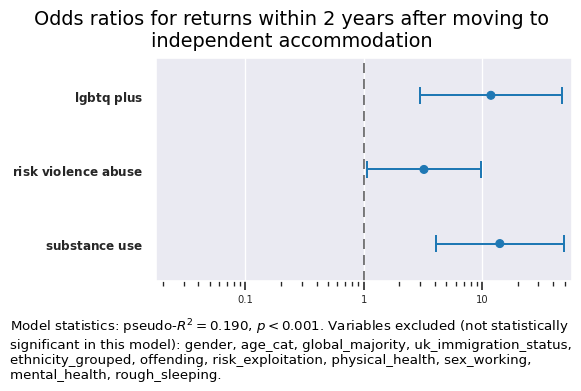

```python
figure_minor_i += 1
ref_cats_used = {}
shorter_iv = {r"uk\ immigration\ status": "immigration"}
cols_removed = [col for col in cols_to_remove if col != "multiple_disadvantage"]
fig_str = plot_odds_r(dv_str, None, ref_cats_used, results_or_final, replacements=shorter_iv, cols_removed=cols_removed, figsize=(6, 4))
plt.show(block=False)
```

# Outcomes from individual placements - ref category independent accommodation

## Prepare DV

```python
# Get DV
dv_str = "Outcomes from individual placements"
dv = dv_dict[dv_str].iloc[:, 0].astype("category")
cat_order = ['Independent accommodation',
             'Internal move: forwards',
             'Internal move: sideways',
             'Internal move: backwards',
             'Returned to homelessness',
             'Insecure outcome (external)',
             'Died']
dv = dv.cat.reorder_categories(cat_order)
```

## Prepare IVs

```python
selected_ch = {
    "demographics":  ["gender", "age_cat", "global_majority", "lgbtq_plus",
                      # "ethnicity_detailed", "ethnicity_grouped",
                      # "uk_immigration_status", "english_2nd_language",
                      ],
    "ethnicity_related": ["ethnicity_grouped", "uk_immigration_status"],
    "support_needs": ["offending", "physical_health", "mental_health", "substance_use", "multiple_disadvantage",
                      "rough_sleeping", "sex_working", "risk_violence_abuse", "risk_exploitation",],
    # "route_variables": ["referral_agency", "rt_duration_weeks", "rt_entry_point",]
}
cols_to_exclude = []
X, Xc, iv_df, iv_cols_used, ref_cats, binaries, dummy_cols = get_ivs(dv, cols_to_exclude, selected_ch)
```

## Model building

### Start with block for demographic variables

```python
block_ch = list(selected_ch.values())[0]
block_ch_d = ["(Intercept)"] + cols_with_dummies(block_ch, dummy_cols)
```

### Test associations between IVs for initial block

#### Cramer’s V

**Results**

p values indicated by asterisks: `***` if `p < 0.001`, `**` if `p < 0.01`, `*` if `p < 0.05`

```python
chi2_crv_results, disp = iv_assoc(iv_df, block_ch)
with pd.option_context("display.float_format", "{:,.3f}".format):
    display(disp)
```

| iv1 | iv2 | g | ac | gm | lp |
| --- | --- | --- | --- | --- | --- |
| gender | V | NaN | 0.128 | 0.059 | 0.161 |
|  | * | NaN | *** | *** | *** |
| age_cat | V | 0.128 | NaN | 0.076 | 0.101 |
|  | * | *** | NaN | *** | *** |
| global_majority | V | 0.059 | 0.076 | NaN | 0.012 |
|  | * | *** | *** | NaN |  |
| lgbtq_plus | V | 0.161 | 0.101 | 0.012 | NaN |
|  | * | *** | *** |  | NaN |

#### Variance Inflation Factor (VIF)

**Results**

```python
# Test multicollinearity with VIF
vif_data = vif(Xc[block_ch_d[1:]])
with pd.option_context("display.float_format", "{:,.3f}".format):
    display(vif_data)
```

| Feature | VIF |
| --- | --- |
| age_cat_34- | 1.324 |
| gender_Female | 1.207 |
| global_majority | 1.130 |
| lgbtq_plus | 1.081 |
| gender_Non-Binary | 1.024 |

### MNLogit iteration 0

**Results**

```python
cols_to_remove = []
values_to_remove = []
results, summary, results_or = multinomial_regression(dv, Xc[block_ch_d], cols_to_remove, dummy_cols)
```

MNLogit Regression Results

| Dep. Variable: | pl_outcome | No. Observations: | 4828 |
| --- | --- | --- | --- |
| Model: | MNLogit | Df Residuals: | 4792 |
| Method: | MLE | Df Model: | 30 |
| Date: | Sun, 21 Jun 2026 | Pseudo R-squ.: | 0.008228 |
| Time: | 14:50:13 | Log-Likelihood: | -8585.9 |
| converged: | False | LL-Null: | -8657.1 |
| Covariance Type: | nonrobust | LLR p-value: | 1.425e-16 |

| pl_outcome=Internal move: forwards | coef | std err | z | P>\|z\| | [0.025 | 0.975] |
| --- | --- | --- | --- | --- | --- | --- |
| (Intercept) | 0.4653 | 0.065 | 7.147 | 0.000 | 0.338 | 0.593 |
| gender_Female | -0.0592 | 0.096 | -0.617 | 0.537 | -0.247 | 0.129 |
| gender_Non-Binary | 0.3379 | 0.639 | 0.529 | 0.597 | -0.915 | 1.591 |
| age_cat_34- | -0.0700 | 0.092 | -0.762 | 0.446 | -0.250 | 0.110 |
| global_majority | -0.4644 | 0.100 | -4.642 | 0.000 | -0.661 | -0.268 |
| lgbtq_plus | -0.2709 | 0.178 | -1.523 | 0.128 | -0.619 | 0.078 |
| pl_outcome=Internal move: sideways | coef | std err | z | P>\|z\| | [0.025 | 0.975] |
| (Intercept) | 0.2655 | 0.069 | 3.864 | 0.000 | 0.131 | 0.400 |
| gender_Female | -0.2671 | 0.105 | -2.550 | 0.011 | -0.472 | -0.062 |
| gender_Non-Binary | -0.1073 | 0.721 | -0.149 | 0.882 | -1.520 | 1.306 |
| age_cat_34- | 0.1198 | 0.098 | 1.226 | 0.220 | -0.072 | 0.311 |
| global_majority | -0.9557 | 0.118 | -8.132 | 0.000 | -1.186 | -0.725 |
| lgbtq_plus | -0.3514 | 0.195 | -1.802 | 0.072 | -0.734 | 0.031 |
| pl_outcome=Internal move: backwards | coef | std err | z | P>\|z\| | [0.025 | 0.975] |
| (Intercept) | -0.4136 | 0.081 | -5.105 | 0.000 | -0.572 | -0.255 |
| gender_Female | 0.1154 | 0.117 | 0.982 | 0.326 | -0.115 | 0.346 |
| gender_Non-Binary | -0.1485 | 0.878 | -0.169 | 0.866 | -1.870 | 1.573 |
| age_cat_34- | -0.1042 | 0.115 | -0.903 | 0.366 | -0.330 | 0.122 |
| global_majority | -0.5464 | 0.130 | -4.188 | 0.000 | -0.802 | -0.291 |
| lgbtq_plus | -0.0196 | 0.212 | -0.092 | 0.926 | -0.435 | 0.395 |
| pl_outcome=Returned to homelessness | coef | std err | z | P>\|z\| | [0.025 | 0.975] |
| (Intercept) | -0.2642 | 0.079 | -3.358 | 0.001 | -0.418 | -0.110 |
| gender_Female | -0.2592 | 0.122 | -2.130 | 0.033 | -0.498 | -0.021 |
| gender_Non-Binary | -0.8776 | 1.129 | -0.778 | 0.437 | -3.090 | 1.335 |
| age_cat_34- | 0.0218 | 0.113 | 0.192 | 0.847 | -0.200 | 0.244 |
| global_majority | -0.6676 | 0.131 | -5.089 | 0.000 | -0.925 | -0.410 |
| lgbtq_plus | -0.3904 | 0.234 | -1.669 | 0.095 | -0.849 | 0.068 |
| pl_outcome=Insecure outcome (external) | coef | std err | z | P>\|z\| | [0.025 | 0.975] |
| (Intercept) | -0.5277 | 0.084 | -6.299 | 0.000 | -0.692 | -0.363 |
| gender_Female | -0.2099 | 0.125 | -1.682 | 0.093 | -0.454 | 0.035 |
| gender_Non-Binary | -20.2210 | 1.51e+04 | -0.001 | 0.999 | -2.96e+04 | 2.95e+04 |
| age_cat_34- | 0.2372 | 0.115 | 2.056 | 0.040 | 0.011 | 0.463 |
| global_majority | -0.4920 | 0.131 | -3.749 | 0.000 | -0.749 | -0.235 |
| lgbtq_plus | -0.0537 | 0.218 | -0.246 | 0.805 | -0.481 | 0.374 |
| pl_outcome=Died | coef | std err | z | P>\|z\| | [0.025 | 0.975] |
| (Intercept) | -1.6221 | 0.137 | -11.825 | 0.000 | -1.891 | -1.353 |
| gender_Female | -0.8446 | 0.301 | -2.807 | 0.005 | -1.434 | -0.255 |
| gender_Non-Binary | -26.8539 | 1.2e+06 | -2.25e-05 | 1.000 | -2.34e+06 | 2.34e+06 |
| age_cat_34- | -0.9270 | 0.293 | -3.167 | 0.002 | -1.501 | -0.353 |
| global_majority | -1.3570 | 0.359 | -3.775 | 0.000 | -2.062 | -0.652 |
| lgbtq_plus | -0.3706 | 0.530 | -0.699 | 0.485 | -1.410 | 0.669 |

|  | Odds Ratios | p | * | odds_r | [0.025 | 0.975] |
| --- | --- | --- | --- | --- | --- | --- |
| gender_Non-Binary | Internal move: forwards | 0.597 |  | 1.402 | 0.401 | 4.908 |
|  | Insecure outcome (external) | 0.999 |  | 0.000 | 0.000 | inf |
|  | Died | 1.000 |  | 0.000 | 0.000 | inf |
|  | Returned to homelessness | 0.437 |  | 0.416 | 0.046 | 3.799 |
|  | Internal move: sideways | 0.882 |  | 0.898 | 0.219 | 3.691 |
|  | Internal move: backwards | 0.866 |  | 0.862 | 0.154 | 4.822 |
| lgbtq_plus | Died | 0.485 |  | 0.690 | 0.244 | 1.951 |
|  | Internal move: sideways | 0.072 |  | 0.704 | 0.480 | 1.031 |
|  | Returned to homelessness | 0.095 |  | 0.677 | 0.428 | 1.071 |
|  | Internal move: backwards | 0.926 |  | 0.981 | 0.648 | 1.485 |
|  | Insecure outcome (external) | 0.805 |  | 0.948 | 0.618 | 1.453 |
|  | Internal move: forwards | 0.128 |  | 0.763 | 0.538 | 1.081 |
| gender_Female | Insecure outcome (external) | 0.093 |  | 0.811 | 0.635 | 1.035 |
|  | Internal move: backwards | 0.326 |  | 1.122 | 0.891 | 1.413 |
|  | Died | 0.005 | * | 0.430 | 0.238 | 0.775 |
|  | Internal move: sideways | 0.011 | * | 0.766 | 0.624 | 0.940 |
|  | Internal move: forwards | 0.537 |  | 0.943 | 0.781 | 1.137 |
|  | Returned to homelessness | 0.033 | * | 0.772 | 0.608 | 0.979 |
| age_cat_34- | Internal move: backwards | 0.366 |  | 0.901 | 0.719 | 1.130 |
|  | Internal move: sideways | 0.220 |  | 1.127 | 0.931 | 1.365 |
|  | Died | 0.002 | * | 0.396 | 0.223 | 0.702 |
|  | Returned to homelessness | 0.847 |  | 1.022 | 0.819 | 1.276 |
|  | Insecure outcome (external) | 0.040 | * | 1.268 | 1.011 | 1.589 |
|  | Internal move: forwards | 0.446 |  | 0.932 | 0.779 | 1.116 |
| global_majority | Insecure outcome (external) | 0.000 | * | 0.611 | 0.473 | 0.791 |
|  | Internal move: sideways | 0.000 | * | 0.385 | 0.305 | 0.484 |
|  | Internal move: forwards | 0.000 | * | 0.628 | 0.517 | 0.765 |
|  | Returned to homelessness | 0.000 | * | 0.513 | 0.397 | 0.663 |
|  | Internal move: backwards | 0.000 | * | 0.579 | 0.448 | 0.748 |
|  | Died | 0.000 | * | 0.257 | 0.127 | 0.521 |
| (Intercept) | Internal move: forwards | 0.000 | * | 1.592 | 1.402 | 1.809 |
|  | Died | 0.000 | * | 0.197 | 0.151 | 0.258 |
|  | Insecure outcome (external) | 0.000 | * | 0.590 | 0.501 | 0.695 |
|  | Internal move: backwards | 0.000 | * | 0.661 | 0.564 | 0.775 |
|  | Internal move: sideways | 0.000 | * | 1.304 | 1.140 | 1.492 |
|  | Returned to homelessness | 0.001 | * | 0.768 | 0.658 | 0.896 |

```
Psuedo R^2: 0.00822837079165295
--------------------------------------------------
```

### MNLogit iteration 1

Recode `gender=Non-Binary` as missing because there are too few data points: recode variable.

**Results**

```python
selected_dv, selected_xc, sel_block_ch_d = dv_xc_remove_value(dv, Xc, block_ch_d, "gender_Non-Binary")
# cols_to_remove += ["gender_Non-Binary"]
results, summary, results_or = multinomial_regression(selected_dv, selected_xc[sel_block_ch_d], cols_to_remove, dummy_cols)
```

```
Optimization terminated successfully.
         Current function value: 1.779499
         Iterations 8
```

MNLogit Regression Results

| Dep. Variable: | pl_outcome | No. Observations: | 4810 |
| --- | --- | --- | --- |
| Model: | MNLogit | Df Residuals: | 4780 |
| Method: | MLE | Df Model: | 24 |
| Date: | Sun, 21 Jun 2026 | Pseudo R-squ.: | 0.007960 |
| Time: | 14:50:15 | Log-Likelihood: | -8559.4 |
| converged: | True | LL-Null: | -8628.1 |
| Covariance Type: | nonrobust | LLR p-value: | 7.093e-18 |

| pl_outcome=Internal move: forwards | coef | std err | z | P>\|z\| | [0.025 | 0.975] |
| --- | --- | --- | --- | --- | --- | --- |
| (Intercept) | 0.4691 | 0.065 | 7.198 | 0.000 | 0.341 | 0.597 |
| gender_Female | -0.0577 | 0.096 | -0.602 | 0.547 | -0.246 | 0.130 |
| age_cat_34- | -0.0812 | 0.092 | -0.882 | 0.378 | -0.261 | 0.099 |
| global_majority | -0.4635 | 0.100 | -4.631 | 0.000 | -0.660 | -0.267 |
| lgbtq_plus | -0.2794 | 0.181 | -1.546 | 0.122 | -0.634 | 0.075 |
| pl_outcome=Internal move: sideways | coef | std err | z | P>\|z\| | [0.025 | 0.975] |
| (Intercept) | 0.2695 | 0.069 | 3.920 | 0.000 | 0.135 | 0.404 |
| gender_Female | -0.2667 | 0.105 | -2.547 | 0.011 | -0.472 | -0.061 |
| age_cat_34- | 0.1104 | 0.098 | 1.128 | 0.259 | -0.081 | 0.302 |
| global_majority | -0.9640 | 0.118 | -8.185 | 0.000 | -1.195 | -0.733 |
| lgbtq_plus | -0.3401 | 0.197 | -1.726 | 0.084 | -0.727 | 0.046 |
| pl_outcome=Internal move: backwards | coef | std err | z | P>\|z\| | [0.025 | 0.975] |
| (Intercept) | -0.4149 | 0.081 | -5.115 | 0.000 | -0.574 | -0.256 |
| gender_Female | 0.1144 | 0.117 | 0.974 | 0.330 | -0.116 | 0.345 |
| age_cat_34- | -0.1075 | 0.115 | -0.931 | 0.352 | -0.334 | 0.119 |
| global_majority | -0.5465 | 0.130 | -4.188 | 0.000 | -0.802 | -0.291 |
| lgbtq_plus | 0.0234 | 0.212 | 0.111 | 0.912 | -0.391 | 0.438 |
| pl_outcome=Returned to homelessness | coef | std err | z | P>\|z\| | [0.025 | 0.975] |
| (Intercept) | -0.2650 | 0.079 | -3.364 | 0.001 | -0.419 | -0.111 |
| gender_Female | -0.2600 | 0.122 | -2.137 | 0.033 | -0.498 | -0.022 |
| age_cat_34- | 0.0214 | 0.113 | 0.189 | 0.850 | -0.201 | 0.243 |
| global_majority | -0.6687 | 0.131 | -5.097 | 0.000 | -0.926 | -0.412 |
| lgbtq_plus | -0.3623 | 0.234 | -1.547 | 0.122 | -0.821 | 0.097 |
| pl_outcome=Insecure outcome (external) | coef | std err | z | P>\|z\| | [0.025 | 0.975] |
| (Intercept) | -0.5259 | 0.084 | -6.275 | 0.000 | -0.690 | -0.362 |
| gender_Female | -0.2096 | 0.125 | -1.680 | 0.093 | -0.454 | 0.035 |
| age_cat_34- | 0.2313 | 0.115 | 2.005 | 0.045 | 0.005 | 0.457 |
| global_majority | -0.4932 | 0.131 | -3.758 | 0.000 | -0.750 | -0.236 |
| lgbtq_plus | -0.0440 | 0.219 | -0.201 | 0.841 | -0.473 | 0.385 |
| pl_outcome=Died | coef | std err | z | P>\|z\| | [0.025 | 0.975] |
| (Intercept) | -1.6203 | 0.137 | -11.810 | 0.000 | -1.889 | -1.351 |
| gender_Female | -0.8444 | 0.301 | -2.806 | 0.005 | -1.434 | -0.255 |
| age_cat_34- | -0.9330 | 0.293 | -3.187 | 0.001 | -1.507 | -0.359 |
| global_majority | -1.3583 | 0.359 | -3.779 | 0.000 | -2.063 | -0.654 |
| lgbtq_plus | -0.3608 | 0.531 | -0.680 | 0.496 | -1.401 | 0.679 |

|  | Odds Ratios | p | * | odds_r | [0.025 | 0.975] |
| --- | --- | --- | --- | --- | --- | --- |
| lgbtq_plus | Died | 0.496 |  | 0.697 | 0.246 | 1.972 |
|  | Internal move: sideways | 0.084 |  | 0.712 | 0.484 | 1.047 |
|  | Returned to homelessness | 0.122 |  | 0.696 | 0.440 | 1.101 |
|  | Internal move: backwards | 0.912 |  | 1.024 | 0.676 | 1.550 |
|  | Insecure outcome (external) | 0.841 |  | 0.957 | 0.623 | 1.469 |
|  | Internal move: forwards | 0.122 |  | 0.756 | 0.531 | 1.078 |
| gender_Female | Internal move: forwards | 0.547 |  | 0.944 | 0.782 | 1.139 |
|  | Internal move: sideways | 0.011 | * | 0.766 | 0.624 | 0.940 |
|  | Insecure outcome (external) | 0.093 |  | 0.811 | 0.635 | 1.036 |
|  | Died | 0.005 | * | 0.430 | 0.238 | 0.775 |
|  | Internal move: backwards | 0.330 |  | 1.121 | 0.891 | 1.412 |
|  | Returned to homelessness | 0.033 | * | 0.771 | 0.607 | 0.979 |
| age_cat_34- | Insecure outcome (external) | 0.045 | * | 1.260 | 1.005 | 1.580 |
|  | Internal move: forwards | 0.378 |  | 0.922 | 0.770 | 1.104 |
|  | Returned to homelessness | 0.850 |  | 1.022 | 0.818 | 1.276 |
|  | Internal move: backwards | 0.352 |  | 0.898 | 0.716 | 1.126 |
|  | Died | 0.001 | * | 0.393 | 0.222 | 0.698 |
|  | Internal move: sideways | 0.259 |  | 1.117 | 0.922 | 1.353 |
| global_majority | Internal move: forwards | 0.000 | * | 0.629 | 0.517 | 0.765 |
|  | Internal move: backwards | 0.000 | * | 0.579 | 0.448 | 0.748 |
|  | Returned to homelessness | 0.000 | * | 0.512 | 0.396 | 0.663 |
|  | Internal move: sideways | 0.000 | * | 0.381 | 0.303 | 0.480 |
|  | Insecure outcome (external) | 0.000 | * | 0.611 | 0.472 | 0.790 |
|  | Died | 0.000 | * | 0.257 | 0.127 | 0.520 |
| (Intercept) | Died | 0.000 | * | 0.198 | 0.151 | 0.259 |
|  | Internal move: forwards | 0.000 | * | 1.599 | 1.407 | 1.816 |
|  | Insecure outcome (external) | 0.000 | * | 0.591 | 0.501 | 0.697 |
|  | Internal move: backwards | 0.000 | * | 0.660 | 0.563 | 0.774 |
|  | Internal move: sideways | 0.000 | * | 1.309 | 1.144 | 1.498 |
|  | Returned to homelessness | 0.001 | * | 0.767 | 0.657 | 0.895 |

```
Psuedo R^2: 0.007960133151036386
--------------------------------------------------
```

### MNLogit iteration 2

**Results**

```python
cols_to_remove += ["lgbtq_plus"]
results, summary, results_or = multinomial_regression(selected_dv, selected_xc[sel_block_ch_d], cols_to_remove, dummy_cols)
```

```
Optimization terminated successfully.
         Current function value: 1.777642
         Iterations 8
```

MNLogit Regression Results

| Dep. Variable: | pl_outcome | No. Observations: | 5792 |
| --- | --- | --- | --- |
| Model: | MNLogit | Df Residuals: | 5768 |
| Method: | MLE | Df Model: | 18 |
| Date: | Sun, 21 Jun 2026 | Pseudo R-squ.: | 0.009510 |
| Time: | 14:50:17 | Log-Likelihood: | -10296. |
| converged: | True | LL-Null: | -10395. |
| Covariance Type: | nonrobust | LLR p-value: | 2.871e-32 |

| pl_outcome=Internal move: forwards | coef | std err | z | P>\|z\| | [0.025 | 0.975] |
| --- | --- | --- | --- | --- | --- | --- |
| (Intercept) | 0.4082 | 0.059 | 6.926 | 0.000 | 0.293 | 0.524 |
| gender_Female | -0.0743 | 0.087 | -0.858 | 0.391 | -0.244 | 0.096 |
| age_cat_34- | -0.0206 | 0.083 | -0.248 | 0.804 | -0.183 | 0.142 |
| global_majority | -0.5146 | 0.090 | -5.726 | 0.000 | -0.691 | -0.338 |
| pl_outcome=Internal move: sideways | coef | std err | z | P>\|z\| | [0.025 | 0.975] |
| (Intercept) | 0.2591 | 0.062 | 4.195 | 0.000 | 0.138 | 0.380 |
| gender_Female | -0.3849 | 0.096 | -4.006 | 0.000 | -0.573 | -0.197 |
| age_cat_34- | 0.1384 | 0.089 | 1.562 | 0.118 | -0.035 | 0.312 |
| global_majority | -1.0654 | 0.107 | -9.949 | 0.000 | -1.275 | -0.856 |
| pl_outcome=Internal move: backwards | coef | std err | z | P>\|z\| | [0.025 | 0.975] |
| (Intercept) | -0.5019 | 0.075 | -6.730 | 0.000 | -0.648 | -0.356 |
| gender_Female | 0.1518 | 0.107 | 1.417 | 0.156 | -0.058 | 0.362 |
| age_cat_34- | -0.0208 | 0.105 | -0.198 | 0.843 | -0.227 | 0.185 |
| global_majority | -0.6466 | 0.120 | -5.376 | 0.000 | -0.882 | -0.411 |
| pl_outcome=Returned to homelessness | coef | std err | z | P>\|z\| | [0.025 | 0.975] |
| (Intercept) | -0.2780 | 0.071 | -3.937 | 0.000 | -0.416 | -0.140 |
| gender_Female | -0.3704 | 0.111 | -3.348 | 0.001 | -0.587 | -0.154 |
| age_cat_34- | 0.1253 | 0.101 | 1.241 | 0.214 | -0.073 | 0.323 |
| global_majority | -0.7422 | 0.117 | -6.328 | 0.000 | -0.972 | -0.512 |
| pl_outcome=Insecure outcome (external) | coef | std err | z | P>\|z\| | [0.025 | 0.975] |
| (Intercept) | -0.5105 | 0.075 | -6.805 | 0.000 | -0.658 | -0.363 |
| gender_Female | -0.2577 | 0.113 | -2.271 | 0.023 | -0.480 | -0.035 |
| age_cat_34- | 0.2148 | 0.104 | 2.058 | 0.040 | 0.010 | 0.419 |
| global_majority | -0.5751 | 0.119 | -4.845 | 0.000 | -0.808 | -0.342 |
| pl_outcome=Died | coef | std err | z | P>\|z\| | [0.025 | 0.975] |
| (Intercept) | -1.6158 | 0.122 | -13.291 | 0.000 | -1.854 | -1.378 |
| gender_Female | -0.9942 | 0.286 | -3.474 | 0.001 | -1.555 | -0.433 |
| age_cat_34- | -1.0919 | 0.278 | -3.923 | 0.000 | -1.637 | -0.546 |
| global_majority | -1.1444 | 0.294 | -3.896 | 0.000 | -1.720 | -0.569 |

Variables removed: ['lgbtq_plus']

|  |  | p | * | odds_r | [0.025 | 0.975] | prev_coef | coef | diff_pct |
| --- | --- | --- | --- | --- | --- | --- | --- | --- | --- |
| age_cat_34- | Insecure outcome (external) | 0.040 | * | 1.240 | 1.010 | 1.521 | 0.231 | 0.215 | -7.100 |
|  | Internal move: backwards | 0.843 |  | 0.979 | 0.797 | 1.203 | -0.108 | -0.021 | -80.600 |
|  | Internal move: forwards | 0.804 |  | 0.980 | 0.833 | 1.152 | -0.081 | -0.021 | -74.600 |
|  | Died | 0.000 | * | 0.336 | 0.194 | 0.579 | -0.933 | -1.092 | 17.000 |
|  | Returned to homelessness | 0.214 |  | 1.134 | 0.930 | 1.381 | 0.021 | 0.125 | 484.900 |
|  | Internal move: sideways | 0.118 |  | 1.148 | 0.965 | 1.366 | 0.110 | 0.138 | 25.300 |
| gender_Female | Insecure outcome (external) | 0.023 | * | 0.773 | 0.619 | 0.965 | -0.210 | -0.258 | 22.900 |
|  | Returned to homelessness | 0.001 | * | 0.690 | 0.556 | 0.858 | -0.260 | -0.370 | 42.400 |
|  | Internal move: forwards | 0.391 |  | 0.928 | 0.783 | 1.100 | -0.058 | -0.074 | 28.700 |
|  | Internal move: backwards | 0.156 |  | 1.164 | 0.944 | 1.436 | 0.114 | 0.152 | 32.700 |
|  | Died | 0.001 | * | 0.370 | 0.211 | 0.648 | -0.844 | -0.994 | 17.700 |
|  | Internal move: sideways | 0.000 | * | 0.681 | 0.564 | 0.822 | -0.267 | -0.385 | 44.300 |
| global_majority | Insecure outcome (external) | 0.000 | * | 0.563 | 0.446 | 0.710 | -0.493 | -0.575 | 16.600 |
|  | Internal move: backwards | 0.000 | * | 0.524 | 0.414 | 0.663 | -0.546 | -0.647 | 18.300 |
|  | Internal move: sideways | 0.000 | * | 0.345 | 0.279 | 0.425 | -0.964 | -1.065 | 10.500 |
|  | Returned to homelessness | 0.000 | * | 0.476 | 0.378 | 0.599 | -0.669 | -0.742 | 11.000 |
|  | Internal move: forwards | 0.000 | * | 0.598 | 0.501 | 0.713 | -0.464 | -0.515 | 11.000 |
|  | Died | 0.000 | * | 0.318 | 0.179 | 0.566 | -1.358 | -1.144 | -15.700 |
| (Intercept) | Died | 0.000 | * | 0.199 | 0.157 | 0.252 | -1.620 | -1.616 | -0.300 |
|  | Internal move: forwards | 0.000 | * | 1.504 | 1.340 | 1.688 | 0.469 | 0.408 | -13.000 |
|  | Insecure outcome (external) | 0.000 | * | 0.600 | 0.518 | 0.695 | -0.526 | -0.511 | -2.900 |
|  | Internal move: backwards | 0.000 | * | 0.605 | 0.523 | 0.701 | -0.415 | -0.502 | 21.000 |
|  | Internal move: sideways | 0.000 | * | 1.296 | 1.148 | 1.462 | 0.270 | 0.259 | -3.900 |
|  | Returned to homelessness | 0.000 | * | 0.757 | 0.659 | 0.870 | -0.265 | -0.278 | 4.900 |

```
Psuedo R^2: 0.009510029392585495
--------------------------------------------------
```

### Add block for grouped ethnicity data and drop “global_majority”

```python
new_block_ch = selected_ch["ethnicity_related"]
sel_block_ch = [ch for ch in block_ch + new_block_ch if ch != "global_majority"]
sel_block_ch_d = [ch for ch in sel_block_ch_d + cols_with_dummies(new_block_ch, dummy_cols) if ch != "global_majority"]
```

### Test associations between IVs now a block has been added

#### Cramer’s V

**Results**

p values indicated by asterisks: `***` if `p < 0.001`, `**` if `p < 0.01`, `*` if `p < 0.05`

```python
chi2_crv_results, disp = iv_assoc(iv_df, sel_block_ch)
with pd.option_context("display.float_format", "{:,.3f}".format):
    display(disp)
```

| iv1 | iv2 | g | ac | lp | eg | uis |
| --- | --- | --- | --- | --- | --- | --- |
| gender | V | NaN | 0.112 | 0.165 | 0.073 | 0.048 |
|  | * | NaN | *** | *** | *** | ** |
| age_cat | V | 0.112 | NaN | 0.103 | 0.070 | 0.078 |
|  | * | *** | NaN | *** | *** | *** |
| lgbtq_plus | V | 0.165 | 0.103 | NaN | 0.058 | 0.022 |
|  | * | *** | *** | NaN | ** |  |
| ethnicity_grouped | V | 0.073 | 0.070 | 0.058 | NaN | 0.381 |
|  | * | *** | *** | ** | NaN | *** |
| uk_immigration_status | V | 0.048 | 0.078 | 0.022 | 0.381 | NaN |
|  | * | ** | *** |  | *** | NaN |

#### Variance Inflation Factor (VIF)

**Results**

```python
# Test multicollinearity with VIF
vif_data = vif(Xc[sel_block_ch_d[1:]])
with pd.option_context("display.float_format", "{:,.3f}".format):
    display(vif_data)
```

| Feature | VIF |
| --- | --- |
| uk_immigration_status_Non-EEA National | 1.502 |
| ethnicity_grouped_Black | 1.315 |
| age_cat_34- | 1.311 |
| ethnicity_grouped_Other | 1.260 |
| gender_Female | 1.208 |
| lgbtq_plus | 1.067 |
| ethnicity_grouped_Mixed Heritage | 1.046 |
| uk_immigration_status_EEA National | 1.044 |

No significant multicollinearity. Proceeding with MNLogit.

```python
results, summary, results_or = multinomial_regression(selected_dv, selected_xc[sel_block_ch_d], [], dummy_cols)
```

### MNLogit iteration 3

**Results**

```python
results, summary, results_or = multinomial_regression(selected_dv, selected_xc[sel_block_ch_d], cols_to_remove, dummy_cols)
```

```
Optimization terminated successfully.
         Current function value: 1.755207
         Iterations 8
```

MNLogit Regression Results

| Dep. Variable: | pl_outcome | No. Observations: | 5108 |
| --- | --- | --- | --- |
| Model: | MNLogit | Df Residuals: | 5060 |
| Method: | MLE | Df Model: | 42 |
| Date: | Sun, 21 Jun 2026 | Pseudo R-squ.: | 0.01346 |
| Time: | 14:50:21 | Log-Likelihood: | -8965.6 |
| converged: | True | LL-Null: | -9087.9 |
| Covariance Type: | nonrobust | LLR p-value: | 2.104e-30 |

| pl_outcome=Internal move: forwards | coef | std err | z | P>\|z\| | [0.025 | 0.975] |
| --- | --- | --- | --- | --- | --- | --- |
| (Intercept) | 0.6788 | 0.067 | 10.160 | 0.000 | 0.548 | 0.810 |
| gender_Female | -0.1513 | 0.097 | -1.565 | 0.118 | -0.341 | 0.038 |
| age_cat_34- | -0.0454 | 0.092 | -0.493 | 0.622 | -0.226 | 0.135 |
| ethnicity_grouped_Black | -0.5367 | 0.139 | -3.865 | 0.000 | -0.809 | -0.265 |
| ethnicity_grouped_Mixed Heritage | -0.2090 | 0.199 | -1.052 | 0.293 | -0.598 | 0.180 |
| ethnicity_grouped_Other | -0.4424 | 0.207 | -2.136 | 0.033 | -0.848 | -0.037 |
| uk_immigration_status_Non-EEA National | -0.1914 | 0.166 | -1.151 | 0.250 | -0.517 | 0.134 |
| uk_immigration_status_EEA National | -0.0995 | 0.235 | -0.423 | 0.672 | -0.560 | 0.361 |
| pl_outcome=Internal move: sideways | coef | std err | z | P>\|z\| | [0.025 | 0.975] |
| (Intercept) | 0.5864 | 0.069 | 8.488 | 0.000 | 0.451 | 0.722 |
| gender_Female | -0.4735 | 0.105 | -4.515 | 0.000 | -0.679 | -0.268 |
| age_cat_34- | 0.1565 | 0.097 | 1.615 | 0.106 | -0.033 | 0.346 |
| ethnicity_grouped_Black | -0.9887 | 0.164 | -6.043 | 0.000 | -1.309 | -0.668 |
| ethnicity_grouped_Mixed Heritage | -0.2479 | 0.209 | -1.188 | 0.235 | -0.657 | 0.161 |
| ethnicity_grouped_Other | -0.8503 | 0.257 | -3.308 | 0.001 | -1.354 | -0.346 |
| uk_immigration_status_Non-EEA National | -1.0490 | 0.227 | -4.611 | 0.000 | -1.495 | -0.603 |
| uk_immigration_status_EEA National | -0.7088 | 0.287 | -2.467 | 0.014 | -1.272 | -0.146 |
| pl_outcome=Internal move: backwards | coef | std err | z | P>\|z\| | [0.025 | 0.975] |
| (Intercept) | -0.1958 | 0.081 | -2.404 | 0.016 | -0.355 | -0.036 |
| gender_Female | 0.0437 | 0.116 | 0.377 | 0.706 | -0.183 | 0.271 |
| age_cat_34- | -0.0274 | 0.113 | -0.243 | 0.808 | -0.249 | 0.194 |
| ethnicity_grouped_Black | -0.7288 | 0.185 | -3.949 | 0.000 | -1.090 | -0.367 |
| ethnicity_grouped_Mixed Heritage | -0.0503 | 0.231 | -0.217 | 0.828 | -0.504 | 0.403 |
| ethnicity_grouped_Other | -1.0098 | 0.307 | -3.290 | 0.001 | -1.611 | -0.408 |
| uk_immigration_status_Non-EEA National | -0.1485 | 0.220 | -0.674 | 0.500 | -0.580 | 0.283 |
| uk_immigration_status_EEA National | 0.0167 | 0.285 | 0.059 | 0.953 | -0.542 | 0.575 |
| pl_outcome=Returned to homelessness | coef | std err | z | P>\|z\| | [0.025 | 0.975] |
| (Intercept) | -0.0196 | 0.079 | -0.249 | 0.803 | -0.174 | 0.135 |
| gender_Female | -0.4488 | 0.121 | -3.701 | 0.000 | -0.686 | -0.211 |
| age_cat_34- | 0.0905 | 0.111 | 0.814 | 0.416 | -0.127 | 0.308 |
| ethnicity_grouped_Black | -0.6432 | 0.179 | -3.586 | 0.000 | -0.995 | -0.292 |
| ethnicity_grouped_Mixed Heritage | 0.0127 | 0.228 | 0.056 | 0.956 | -0.435 | 0.460 |
| ethnicity_grouped_Other | -0.7478 | 0.298 | -2.511 | 0.012 | -1.331 | -0.164 |
| uk_immigration_status_Non-EEA National | -0.9675 | 0.260 | -3.728 | 0.000 | -1.476 | -0.459 |
| uk_immigration_status_EEA National | -0.0437 | 0.281 | -0.155 | 0.877 | -0.595 | 0.507 |
| pl_outcome=Insecure outcome (external) | coef | std err | z | P>\|z\| | [0.025 | 0.975] |
| (Intercept) | -0.3689 | 0.086 | -4.277 | 0.000 | -0.538 | -0.200 |
| gender_Female | -0.3324 | 0.129 | -2.572 | 0.010 | -0.586 | -0.079 |
| age_cat_34- | 0.2293 | 0.119 | 1.932 | 0.053 | -0.003 | 0.462 |
| ethnicity_grouped_Black | -0.7756 | 0.203 | -3.819 | 0.000 | -1.174 | -0.378 |
| ethnicity_grouped_Mixed Heritage | -0.0444 | 0.249 | -0.178 | 0.859 | -0.533 | 0.444 |
| ethnicity_grouped_Other | -0.2748 | 0.280 | -0.982 | 0.326 | -0.824 | 0.274 |
| uk_immigration_status_Non-EEA National | -0.6839 | 0.259 | -2.643 | 0.008 | -1.191 | -0.177 |
| uk_immigration_status_EEA National | -0.3288 | 0.328 | -1.001 | 0.317 | -0.973 | 0.315 |
| pl_outcome=Died | coef | std err | z | P>\|z\| | [0.025 | 0.975] |
| (Intercept) | -1.5894 | 0.145 | -10.975 | 0.000 | -1.873 | -1.306 |
| gender_Female | -1.1444 | 0.349 | -3.281 | 0.001 | -1.828 | -0.461 |
| age_cat_34- | -1.2723 | 0.347 | -3.665 | 0.000 | -1.953 | -0.592 |
| ethnicity_grouped_Black | -1.1824 | 0.494 | -2.395 | 0.017 | -2.150 | -0.215 |
| ethnicity_grouped_Mixed Heritage | -0.8614 | 0.735 | -1.172 | 0.241 | -2.302 | 0.580 |
| ethnicity_grouped_Other | -0.3758 | 0.601 | -0.625 | 0.532 | -1.555 | 0.803 |
| uk_immigration_status_Non-EEA National | -0.5212 | 0.605 | -0.861 | 0.389 | -1.708 | 0.665 |
| uk_immigration_status_EEA National | 0.0567 | 0.622 | 0.091 | 0.927 | -1.162 | 1.275 |

Variables removed: ['lgbtq_plus']

|  |  | p | * | odds_r | [0.025 | 0.975] | prev_coef | coef | diff_pct |
| --- | --- | --- | --- | --- | --- | --- | --- | --- | --- |
| ethnicity_grouped_Mixed Heritage | Internal move: forwards | 0.293 |  | 0.811 | 0.550 | 1.198 | -0.192 | -0.209 | 8.700 |
|  | Insecure outcome (external) | 0.859 |  | 0.957 | 0.587 | 1.559 | 0.104 | -0.044 | -142.800 |
|  | Died | 0.241 |  | 0.423 | 0.100 | 1.785 | -0.569 | -0.861 | 51.400 |
|  | Returned to homelessness | 0.956 |  | 1.013 | 0.647 | 1.585 | 0.207 | 0.013 | -93.900 |
|  | Internal move: sideways | 0.235 |  | 0.780 | 0.519 | 1.175 | -0.129 | -0.248 | 92.100 |
|  | Internal move: backwards | 0.828 |  | 0.951 | 0.604 | 1.496 | 0.112 | -0.050 | -144.800 |
| uk_immigration_status_EEA National | Died | 0.927 |  | 1.058 | 0.313 | 3.580 | 0.026 | 0.057 | 116.400 |
|  | Internal move: sideways | 0.014 | * | 0.492 | 0.280 | 0.864 | -0.395 | -0.709 | 79.500 |
|  | Insecure outcome (external) | 0.317 |  | 0.720 | 0.378 | 1.370 | -0.243 | -0.329 | 35.400 |
|  | Internal move: forwards | 0.672 |  | 0.905 | 0.571 | 1.435 | 0.105 | -0.099 | -195.100 |
|  | Returned to homelessness | 0.877 |  | 0.957 | 0.552 | 1.661 | -0.153 | -0.044 | -71.400 |
|  | Internal move: backwards | 0.953 |  | 1.017 | 0.582 | 1.777 | 0.105 | 0.017 | -84.000 |
| ethnicity_grouped_Other | Insecure outcome (external) | 0.326 |  | 0.760 | 0.439 | 1.315 | -0.135 | -0.275 | 104.300 |
|  | Returned to homelessness | 0.012 | * | 0.473 | 0.264 | 0.849 | -0.664 | -0.748 | 12.600 |
|  | Died | 0.532 |  | 0.687 | 0.211 | 2.232 | -0.937 | -0.376 | -59.900 |
|  | Internal move: backwards | 0.001 | * | 0.364 | 0.200 | 0.665 | -0.709 | -1.010 | 42.300 |
|  | Internal move: sideways | 0.001 | * | 0.427 | 0.258 | 0.707 | -0.763 | -0.850 | 11.500 |
|  | Internal move: forwards | 0.033 | * | 0.642 | 0.428 | 0.964 | -0.485 | -0.442 | -8.700 |
| age_cat_34- | Internal move: sideways | 0.106 |  | 1.169 | 0.967 | 1.414 | 0.131 | 0.156 | 19.000 |
|  | Internal move: backwards | 0.808 |  | 0.973 | 0.780 | 1.214 | -0.120 | -0.027 | -77.200 |
|  | Internal move: forwards | 0.622 |  | 0.956 | 0.798 | 1.145 | -0.099 | -0.045 | -54.100 |
|  | Died | 0.000 | * | 0.280 | 0.142 | 0.553 | -1.041 | -1.272 | 22.300 |
|  | Insecure outcome (external) | 0.053 |  | 1.258 | 0.997 | 1.587 | 0.233 | 0.229 | -1.400 |
|  | Returned to homelessness | 0.416 |  | 1.095 | 0.880 | 1.361 | -0.009 | 0.090 | -1,127.500 |
| gender_Female | Internal move: sideways | 0.000 | * | 0.623 | 0.507 | 0.765 | -0.395 | -0.473 | 19.900 |
|  | Insecure outcome (external) | 0.010 | * | 0.717 | 0.557 | 0.924 | -0.308 | -0.332 | 7.800 |
|  | Internal move: backwards | 0.706 |  | 1.045 | 0.833 | 1.311 | -0.026 | 0.044 | -265.600 |
|  | Died | 0.001 | * | 0.318 | 0.161 | 0.631 | -1.101 | -1.144 | 3.900 |
|  | Returned to homelessness | 0.000 | * | 0.638 | 0.503 | 0.810 | -0.390 | -0.449 | 15.100 |
|  | Internal move: forwards | 0.118 |  | 0.860 | 0.711 | 1.039 | -0.172 | -0.151 | -12.100 |
| uk_immigration_status_Non-EEA National | Returned to homelessness | 0.000 | * | 0.380 | 0.229 | 0.632 | -1.160 | -0.967 | -16.600 |
|  | Died | 0.389 |  | 0.594 | 0.181 | 1.945 | -0.301 | -0.521 | 73.100 |
|  | Internal move: forwards | 0.250 |  | 0.826 | 0.596 | 1.144 | -0.224 | -0.191 | -14.400 |
|  | Internal move: backwards | 0.500 |  | 0.862 | 0.560 | 1.328 | -0.296 | -0.149 | -49.900 |
|  | Insecure outcome (external) | 0.008 | * | 0.505 | 0.304 | 0.838 | -0.761 | -0.684 | -10.200 |
|  | Internal move: sideways | 0.000 | * | 0.350 | 0.224 | 0.547 | -1.050 | -1.049 | -0.100 |
| ethnicity_grouped_Black | Returned to homelessness | 0.000 | * | 0.526 | 0.370 | 0.747 | -0.609 | -0.643 | 5.700 |
|  | Internal move: sideways | 0.000 | * | 0.372 | 0.270 | 0.513 | -0.888 | -0.989 | 11.300 |
|  | Insecure outcome (external) | 0.000 | * | 0.460 | 0.309 | 0.686 | -0.652 | -0.776 | 19.000 |
|  | Internal move: forwards | 0.000 | * | 0.585 | 0.445 | 0.768 | -0.462 | -0.537 | 16.200 |
|  | Internal move: backwards | 0.000 | * | 0.482 | 0.336 | 0.693 | -0.648 | -0.729 | 12.500 |
|  | Died | 0.017 | * | 0.307 | 0.116 | 0.807 | -1.243 | -1.182 | -4.900 |
| (Intercept) | Internal move: forwards | 0.000 | * | 1.972 | 1.730 | 2.247 | 0.747 | 0.679 | -9.100 |
|  | Died | 0.000 | * | 0.204 | 0.154 | 0.271 | -1.605 | -1.589 | -0.900 |
|  | Insecure outcome (external) | 0.000 | * | 0.691 | 0.584 | 0.819 | -0.373 | -0.369 | -1.000 |
|  | Internal move: backwards | 0.016 | * | 0.822 | 0.701 | 0.964 | -0.103 | -0.196 | 89.500 |
|  | Internal move: sideways | 0.000 | * | 1.798 | 1.570 | 2.058 | 0.586 | 0.586 | 0.100 |
|  | Returned to homelessness | 0.803 |  | 0.981 | 0.840 | 1.144 | -0.014 | -0.020 | 35.200 |

```
Psuedo R^2: 0.013458012307937084
--------------------------------------------------
```

All variables are significant. Proceeding.

### Add block for support needs variables

```python
new_block_ch = selected_ch["support_needs"]
sel_block_ch = sel_block_ch + new_block_ch
sel_block_ch_d = sel_block_ch_d + cols_with_dummies(new_block_ch, dummy_cols)
```

### Test associations between IVs now a block has been added

#### Cramer’s V

**Results**

p values indicated by asterisks: `***` if `p < 0.001`, `**` if `p < 0.01`, `*` if `p < 0.05`

```python
chi2_crv_results, disp = iv_assoc(iv_df, sel_block_ch)
with pd.option_context("display.float_format", "{:,.3f}".format):
    display(disp)
```

| iv1 | iv2 | g | ac | lp | eg | uis | o | ph | mh | su | md | rs | sw | rva | re |
| --- | --- | --- | --- | --- | --- | --- | --- | --- | --- | --- | --- | --- | --- | --- | --- |
| gender | V | NaN | 0.112 | 0.166 | 0.073 | 0.048 | 0.132 | 0.037 | 0.120 | 0.040 | 0.074 | 0.032 | 0.300 | 0.380 | 0.140 |
|  | * | NaN | *** | *** | *** | ** | *** |  | *** |  | *** |  | *** | *** | *** |
| age_cat | V | 0.112 | NaN | 0.106 | 0.070 | 0.079 | 0.002 | 0.195 | 0.053 | 0.145 | 0.047 | 0.018 | 0.002 | 0.034 | 0.017 |
|  | * | *** | NaN | *** | *** | *** |  | *** | *** | *** | ** |  |  | * |  |
| lgbtq_plus | V | 0.166 | 0.106 | NaN | 0.060 | 0.022 | 0.030 | 0.016 | 0.018 | 0.050 | 0.026 | 0.006 | 0.001 | 0.005 | 0.026 |
|  | * | *** | *** | NaN | ** |  |  |  |  | ** |  |  |  |  |  |
| ethnicity_grouped | V | 0.073 | 0.070 | 0.060 | NaN | 0.381 | 0.076 | 0.089 | 0.093 | 0.262 | 0.203 | 0.086 | 0.091 | 0.051 | 0.065 |
|  | * | *** | *** | ** | NaN | *** | *** | *** | *** | *** | *** | *** | *** | * | *** |
| uk_immigration_status | V | 0.048 | 0.079 | 0.022 | 0.381 | NaN | 0.111 | 0.058 | 0.088 | 0.207 | 0.188 | 0.056 | 0.055 | 0.040 | 0.070 |
|  | * | ** | *** |  | *** | NaN | *** | *** | *** | *** | *** | ** | ** | * | *** |
| offending | V | 0.132 | 0.002 | 0.030 | 0.076 | 0.111 | NaN | 0.033 | 0.063 | 0.125 | 0.315 | 0.119 | 0.059 | 0.002 | 0.026 |
|  | * | *** |  |  | *** | *** | NaN | * | *** | *** | *** | *** | *** |  |  |
| physical_health | V | 0.037 | 0.195 | 0.016 | 0.089 | 0.058 | 0.033 | NaN | 0.099 | 0.107 | 0.115 | 0.130 | 0.105 | 0.091 | 0.086 |
|  | * |  | *** |  | *** | *** | * | NaN | *** | *** | *** | *** | *** | *** | *** |
| mental_health | V | 0.120 | 0.053 | 0.018 | 0.093 | 0.088 | 0.063 | 0.099 | NaN | 0.179 | 0.569 | 0.096 | 0.110 | 0.085 | 0.077 |
|  | * | *** | *** |  | *** | *** | *** | *** | NaN | *** | *** | *** | *** | *** | *** |
| substance_use | V | 0.040 | 0.145 | 0.050 | 0.262 | 0.207 | 0.125 | 0.107 | 0.179 | NaN | 0.659 | 0.219 | 0.126 | 0.041 | 0.146 |
|  | * |  | *** | ** | *** | *** | *** | *** | *** | NaN | *** | *** | *** | ** | *** |
| multiple_disadvantage | V | 0.074 | 0.047 | 0.026 | 0.203 | 0.188 | 0.315 | 0.115 | 0.569 | 0.659 | NaN | 0.205 | 0.138 | 0.283 | 0.167 |
|  | * | *** | ** |  | *** | *** | *** | *** | *** | *** | NaN | *** | *** | *** | *** |
| rough_sleeping | V | 0.032 | 0.018 | 0.006 | 0.086 | 0.056 | 0.119 | 0.130 | 0.096 | 0.219 | 0.205 | NaN | 0.084 | 0.045 | 0.018 |
|  | * |  |  |  | *** | ** | *** | *** | *** | *** | *** | NaN | *** | ** |  |
| sex_working | V | 0.300 | 0.002 | 0.001 | 0.091 | 0.055 | 0.059 | 0.105 | 0.110 | 0.126 | 0.138 | 0.084 | NaN | 0.286 | 0.220 |
|  | * | *** |  |  | *** | ** | *** | *** | *** | *** | *** | *** | NaN | *** | *** |
| risk_violence_abuse | V | 0.380 | 0.034 | 0.005 | 0.051 | 0.040 | 0.002 | 0.091 | 0.085 | 0.041 | 0.283 | 0.045 | 0.286 | NaN | 0.234 |
|  | * | *** | * |  | * | * |  | *** | *** | ** | *** | ** | *** | NaN | *** |
| risk_exploitation | V | 0.140 | 0.017 | 0.026 | 0.065 | 0.070 | 0.026 | 0.086 | 0.077 | 0.146 | 0.167 | 0.018 | 0.220 | 0.234 | NaN |
|  | * | *** |  |  | *** | *** |  | *** | *** | *** | *** |  | *** | *** | NaN |

#### Variance Inflation Factor (VIF)

**Results**

```python
# Test multicollinearity with VIF
vif_data = vif(Xc[sel_block_ch_d[1:]])
with pd.option_context("display.float_format", "{:,.3f}".format):
    display(vif_data)
```

| Feature | VIF |
| --- | --- |
| multiple_disadvantage | 9.158 |
| mental_health | 5.044 |
| substance_use | 4.720 |
| gender_Female | 1.762 |
| risk_violence_abuse | 1.762 |
| physical_health | 1.673 |
| age_cat_34- | 1.554 |
| uk_immigration_status_Non-EEA National | 1.515 |
| offending | 1.467 |
| rough_sleeping | 1.367 |
| ethnicity_grouped_Black | 1.359 |
| ethnicity_grouped_Other | 1.284 |
| risk_exploitation | 1.247 |
| sex_working | 1.242 |
| lgbtq_plus | 1.081 |
| ethnicity_grouped_Mixed Heritage | 1.066 |
| uk_immigration_status_EEA National | 1.055 |

`multiple_disadvantage` has high VIF due to multicollinearity of `multiple_disadvantage`, `substance_use` and `mental_health`.

Dropping `multiple_disadvantage` as previous models showed that separate needs explained more of the variance.

```python
sel_block_ch_d.remove("multiple_disadvantage")
```

```python
results, summary, results_or = multinomial_regression(selected_dv, selected_xc[sel_block_ch_d], [], dummy_cols)
```

### MNLogit iteration 4

**Results**

```python
results, summary, results_or = multinomial_regression(selected_dv, selected_xc[sel_block_ch_d], cols_to_remove, dummy_cols)
```

```
Optimization terminated successfully.
         Current function value: 1.662701
         Iterations 8
```

MNLogit Regression Results

| Dep. Variable: | pl_outcome | No. Observations: | 5016 |
| --- | --- | --- | --- |
| Model: | MNLogit | Df Residuals: | 4920 |
| Method: | MLE | Df Model: | 90 |
| Date: | Sun, 21 Jun 2026 | Pseudo R-squ.: | 0.06635 |
| Time: | 14:50:29 | Log-Likelihood: | -8340.1 |
| converged: | True | LL-Null: | -8932.8 |
| Covariance Type: | nonrobust | LLR p-value: | 1.627e-190 |

| pl_outcome=Internal move: forwards | coef | std err | z | P>\|z\| | [0.025 | 0.975] |
| --- | --- | --- | --- | --- | --- | --- |
| (Intercept) | -0.1617 | 0.111 | -1.456 | 0.145 | -0.379 | 0.056 |
| gender_Female | -0.2037 | 0.108 | -1.884 | 0.060 | -0.416 | 0.008 |
| age_cat_34- | 0.0933 | 0.098 | 0.953 | 0.340 | -0.099 | 0.285 |
| ethnicity_grouped_Black | -0.2401 | 0.143 | -1.677 | 0.093 | -0.521 | 0.040 |
| ethnicity_grouped_Mixed Heritage | -0.1176 | 0.204 | -0.576 | 0.565 | -0.518 | 0.283 |
| ethnicity_grouped_Other | -0.1751 | 0.213 | -0.822 | 0.411 | -0.592 | 0.242 |
| uk_immigration_status_Non-EEA National | -0.0744 | 0.170 | -0.438 | 0.662 | -0.408 | 0.259 |
| uk_immigration_status_EEA National | 0.1048 | 0.239 | 0.439 | 0.660 | -0.363 | 0.573 |
| offending | 0.5513 | 0.150 | 3.670 | 0.000 | 0.257 | 0.846 |
| physical_health | 0.1085 | 0.097 | 1.114 | 0.265 | -0.082 | 0.299 |
| mental_health | 0.2228 | 0.099 | 2.255 | 0.024 | 0.029 | 0.416 |
| substance_use | 0.8585 | 0.099 | 8.634 | 0.000 | 0.664 | 1.053 |
| rough_sleeping | 0.0512 | 0.142 | 0.361 | 0.718 | -0.226 | 0.329 |
| sex_working | 1.3082 | 0.539 | 2.425 | 0.015 | 0.251 | 2.365 |
| risk_violence_abuse | 0.1329 | 0.135 | 0.986 | 0.324 | -0.131 | 0.397 |
| risk_exploitation | 0.4573 | 0.186 | 2.459 | 0.014 | 0.093 | 0.822 |
| pl_outcome=Internal move: sideways | coef | std err | z | P>\|z\| | [0.025 | 0.975] |
| (Intercept) | -1.7500 | 0.143 | -12.253 | 0.000 | -2.030 | -1.470 |
| gender_Female | -0.5034 | 0.127 | -3.962 | 0.000 | -0.752 | -0.254 |
| age_cat_34- | 0.4434 | 0.109 | 4.083 | 0.000 | 0.231 | 0.656 |
| ethnicity_grouped_Black | -0.2246 | 0.178 | -1.263 | 0.207 | -0.573 | 0.124 |
| ethnicity_grouped_Mixed Heritage | 0.0757 | 0.225 | 0.337 | 0.736 | -0.365 | 0.516 |
| ethnicity_grouped_Other | -0.0751 | 0.273 | -0.275 | 0.783 | -0.610 | 0.460 |
| uk_immigration_status_Non-EEA National | -0.7043 | 0.239 | -2.943 | 0.003 | -1.173 | -0.235 |
| uk_immigration_status_EEA National | -0.3072 | 0.306 | -1.005 | 0.315 | -0.906 | 0.292 |
| offending | 1.1452 | 0.151 | 7.560 | 0.000 | 0.848 | 1.442 |
| physical_health | 0.3054 | 0.107 | 2.846 | 0.004 | 0.095 | 0.516 |
| mental_health | 0.2946 | 0.116 | 2.533 | 0.011 | 0.067 | 0.523 |
| substance_use | 2.1325 | 0.121 | 17.659 | 0.000 | 1.896 | 2.369 |
| rough_sleeping | 0.8084 | 0.140 | 5.785 | 0.000 | 0.534 | 1.082 |

[output cut: 71 more lines]

Variables removed: ['lgbtq_plus']

|  |  | p | * | odds_r | [0.025 | 0.975] | prev_coef | coef | diff_pct |
| --- | --- | --- | --- | --- | --- | --- | --- | --- | --- |
| ethnicity_grouped_Mixed Heritage | Died | 0.410 |  | 0.543 | 0.127 | 2.321 | -0.257 | -0.610 | 137.200 |
|  | Internal move: backwards | 0.556 |  | 1.155 | 0.716 | 1.864 | 0.317 | 0.144 | -54.600 |
|  | Internal move: forwards | 0.565 |  | 0.889 | 0.596 | 1.327 | -0.088 | -0.118 | 33.100 |
|  | Returned to homelessness | 0.378 |  | 1.236 | 0.772 | 1.979 | 0.443 | 0.212 | -52.200 |
|  | Internal move: sideways | 0.736 |  | 1.079 | 0.694 | 1.676 | 0.246 | 0.076 | -69.200 |
|  | Insecure outcome (external) | 0.764 |  | 1.079 | 0.655 | 1.780 | 0.262 | 0.076 | -70.800 |
| uk_immigration_status_EEA National | Returned to homelessness | 0.416 |  | 1.271 | 0.713 | 2.263 | 0.233 | 0.239 | 2.600 |
|  | Internal move: forwards | 0.660 |  | 1.111 | 0.696 | 1.773 | 0.295 | 0.105 | -64.500 |
|  | Insecure outcome (external) | 0.846 |  | 0.937 | 0.486 | 1.806 | 0.048 | -0.065 | -236.200 |
|  | Internal move: sideways | 0.315 |  | 0.736 | 0.404 | 1.339 | 0.053 | -0.307 | -676.000 |
|  | Died | 0.875 |  | 1.105 | 0.318 | 3.837 | 0.006 | 0.100 | 1,686.400 |
|  | Internal move: backwards | 0.229 |  | 1.426 | 0.800 | 2.542 | 0.416 | 0.355 | -14.700 |
| ethnicity_grouped_Other | Internal move: sideways | 0.783 |  | 0.928 | 0.543 | 1.584 | -0.115 | -0.075 | -34.900 |
|  | Returned to homelessness | 0.591 |  | 0.847 | 0.462 | 1.552 | -0.194 | -0.166 | -14.300 |
|  | Insecure outcome (external) | 0.699 |  | 1.118 | 0.636 | 1.966 | 0.192 | 0.111 | -41.800 |
|  | Internal move: backwards | 0.148 |  | 0.635 | 0.343 | 1.175 | -0.259 | -0.455 | 75.300 |
|  | Internal move: forwards | 0.411 |  | 0.839 | 0.553 | 1.274 | -0.249 | -0.175 | -29.700 |
|  | Died | 0.619 |  | 1.346 | 0.417 | 4.346 | -0.217 | 0.297 | -237.300 |
| ethnicity_grouped_Black | Died | 0.278 |  | 0.582 | 0.218 | 1.550 | -0.505 | -0.542 | 7.400 |
|  | Internal move: backwards | 0.404 |  | 0.851 | 0.582 | 1.244 | -0.116 | -0.162 | 38.800 |
|  | Internal move: sideways | 0.207 |  | 0.799 | 0.564 | 1.132 | -0.124 | -0.225 | 81.500 |
|  | Returned to homelessness | 0.466 |  | 0.870 | 0.598 | 1.265 | -0.119 | -0.139 | 17.600 |
|  | Insecure outcome (external) | 0.041 | * | 0.652 | 0.433 | 0.982 | -0.322 | -0.428 | 33.000 |
|  | Internal move: forwards | 0.093 |  | 0.787 | 0.594 | 1.041 | -0.162 | -0.240 | 47.800 |
| mental_health | Died | 0.355 |  | 0.789 | 0.478 | 1.303 | -0.293 | -0.236 | -19.300 |
|  | Insecure outcome (external) | 0.271 |  | 1.157 | 0.892 | 1.500 | 0.138 | 0.146 | 5.600 |
|  | Returned to homelessness | 0.717 |  | 1.046 | 0.819 | 1.337 | -0.018 | 0.045 | -356.100 |
|  | Internal move: backwards | 0.036 | * | 1.314 | 1.017 | 1.697 | 0.235 | 0.273 | 16.100 |
|  | Internal move: forwards | 0.024 | * | 1.250 | 1.030 | 1.517 | 0.180 | 0.223 | 23.500 |
|  | Internal move: sideways | 0.011 | * | 1.343 | 1.069 | 1.686 | 0.206 | 0.295 | 43.000 |

[output cut: 66 more lines]

```
Psuedo R^2: 0.06634982264050582
--------------------------------------------------
```

All other variables are significant.

## Final model

```python
from io import StringIO

display(summary)
results_or_final = (results_or.drop(columns=["prev_coef", "coef", "diff_pct"], errors="ignore")
                    .swaplevel().sort_index()
                    .reindex(cat_order[1:], level=0))
results_or_with_pct = add_interpretation_cols(results_or_final)
with pd.option_context("display.float_format", "{:,.3f}".format):
    display(results_or_with_pct)

tbl_i = 0
comp_cats = [x[0] for x in results.summary().tables[1].data if x[0].startswith(results.model.endog_names)]
for tbl in results.summary2().tables:
    if tbl_i != 0:
        tbl = tbl.rename(columns={tbl.columns[0]: comp_cats[tbl_i - 1]})
    excel_output[f"MNLogit: '{dv_str} (vs independent accommodation)', table {tbl_i}"] = tbl
    tbl_i += 1
excel_output[f"MNLogit: '{dv_str} (vs independent accommodation)', odds ratios"] = results_or_with_pct
```

MNLogit Regression Results

| Dep. Variable: | pl_outcome | No. Observations: | 5016 |
| --- | --- | --- | --- |
| Model: | MNLogit | Df Residuals: | 4920 |
| Method: | MLE | Df Model: | 90 |
| Date: | Sun, 21 Jun 2026 | Pseudo R-squ.: | 0.06635 |
| Time: | 14:50:29 | Log-Likelihood: | -8340.1 |
| converged: | True | LL-Null: | -8932.8 |
| Covariance Type: | nonrobust | LLR p-value: | 1.627e-190 |

| pl_outcome=Internal move: forwards | coef | std err | z | P>\|z\| | [0.025 | 0.975] |
| --- | --- | --- | --- | --- | --- | --- |
| (Intercept) | -0.1617 | 0.111 | -1.456 | 0.145 | -0.379 | 0.056 |
| gender_Female | -0.2037 | 0.108 | -1.884 | 0.060 | -0.416 | 0.008 |
| age_cat_34- | 0.0933 | 0.098 | 0.953 | 0.340 | -0.099 | 0.285 |
| ethnicity_grouped_Black | -0.2401 | 0.143 | -1.677 | 0.093 | -0.521 | 0.040 |
| ethnicity_grouped_Mixed Heritage | -0.1176 | 0.204 | -0.576 | 0.565 | -0.518 | 0.283 |
| ethnicity_grouped_Other | -0.1751 | 0.213 | -0.822 | 0.411 | -0.592 | 0.242 |
| uk_immigration_status_Non-EEA National | -0.0744 | 0.170 | -0.438 | 0.662 | -0.408 | 0.259 |
| uk_immigration_status_EEA National | 0.1048 | 0.239 | 0.439 | 0.660 | -0.363 | 0.573 |
| offending | 0.5513 | 0.150 | 3.670 | 0.000 | 0.257 | 0.846 |
| physical_health | 0.1085 | 0.097 | 1.114 | 0.265 | -0.082 | 0.299 |
| mental_health | 0.2228 | 0.099 | 2.255 | 0.024 | 0.029 | 0.416 |
| substance_use | 0.8585 | 0.099 | 8.634 | 0.000 | 0.664 | 1.053 |
| rough_sleeping | 0.0512 | 0.142 | 0.361 | 0.718 | -0.226 | 0.329 |
| sex_working | 1.3082 | 0.539 | 2.425 | 0.015 | 0.251 | 2.365 |
| risk_violence_abuse | 0.1329 | 0.135 | 0.986 | 0.324 | -0.131 | 0.397 |
| risk_exploitation | 0.4573 | 0.186 | 2.459 | 0.014 | 0.093 | 0.822 |
| pl_outcome=Internal move: sideways | coef | std err | z | P>\|z\| | [0.025 | 0.975] |
| (Intercept) | -1.7500 | 0.143 | -12.253 | 0.000 | -2.030 | -1.470 |
| gender_Female | -0.5034 | 0.127 | -3.962 | 0.000 | -0.752 | -0.254 |
| age_cat_34- | 0.4434 | 0.109 | 4.083 | 0.000 | 0.231 | 0.656 |
| ethnicity_grouped_Black | -0.2246 | 0.178 | -1.263 | 0.207 | -0.573 | 0.124 |
| ethnicity_grouped_Mixed Heritage | 0.0757 | 0.225 | 0.337 | 0.736 | -0.365 | 0.516 |
| ethnicity_grouped_Other | -0.0751 | 0.273 | -0.275 | 0.783 | -0.610 | 0.460 |
| uk_immigration_status_Non-EEA National | -0.7043 | 0.239 | -2.943 | 0.003 | -1.173 | -0.235 |
| uk_immigration_status_EEA National | -0.3072 | 0.306 | -1.005 | 0.315 | -0.906 | 0.292 |
| offending | 1.1452 | 0.151 | 7.560 | 0.000 | 0.848 | 1.442 |
| physical_health | 0.3054 | 0.107 | 2.846 | 0.004 | 0.095 | 0.516 |
| mental_health | 0.2946 | 0.116 | 2.533 | 0.011 | 0.067 | 0.523 |
| substance_use | 2.1325 | 0.121 | 17.659 | 0.000 | 1.896 | 2.369 |
| rough_sleeping | 0.8084 | 0.140 | 5.785 | 0.000 | 0.534 | 1.082 |

[output cut: 71 more lines]

Variables removed: ['lgbtq_plus']

|  |  | p | * | odds_r | [0.025 | 0.975] | odds_r_d% | [0.025_d% | 0.975]_d% |
| --- | --- | --- | --- | --- | --- | --- | --- | --- | --- |
| Internal move: forwards | (Intercept) | 0.145 |  | 0.851 | 0.684 | 1.058 |  |  |  |
|  | age_cat_34- | 0.340 |  | 1.098 | 0.906 | 1.330 |  |  |  |
|  | ethnicity_grouped_Black | 0.093 |  | 0.787 | 0.594 | 1.041 |  |  |  |
|  | ethnicity_grouped_Mixed Heritage | 0.565 |  | 0.889 | 0.596 | 1.327 |  |  |  |
|  | ethnicity_grouped_Other | 0.411 |  | 0.839 | 0.553 | 1.274 |  |  |  |
| ... | ... | ... | ... | ... | ... | ... | ... | ... | ... |
| Died | rough_sleeping | 0.571 |  | 0.824 | 0.423 | 1.608 |  |  |  |
|  | sex_working | 0.040 | * | 7.293 | 1.095 | 48.555 | 629.3% | 9.5% | 4755.5% |
|  | substance_use | 0.000 | * | 8.226 | 4.475 | 15.119 | 722.6% | 347.5% | 1411.9% |
|  | uk_immigration_status_EEA National | 0.875 |  | 1.105 | 0.318 | 3.837 |  |  |  |
|  | uk_immigration_status_Non-EEA National | 0.493 |  | 0.665 | 0.207 | 2.136 |  |  |  |

96 rows × 8 columns

## Visualisation

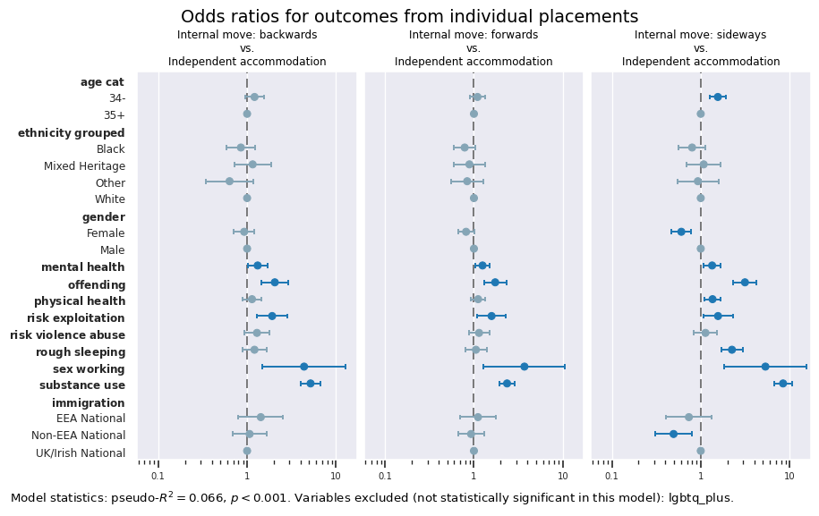

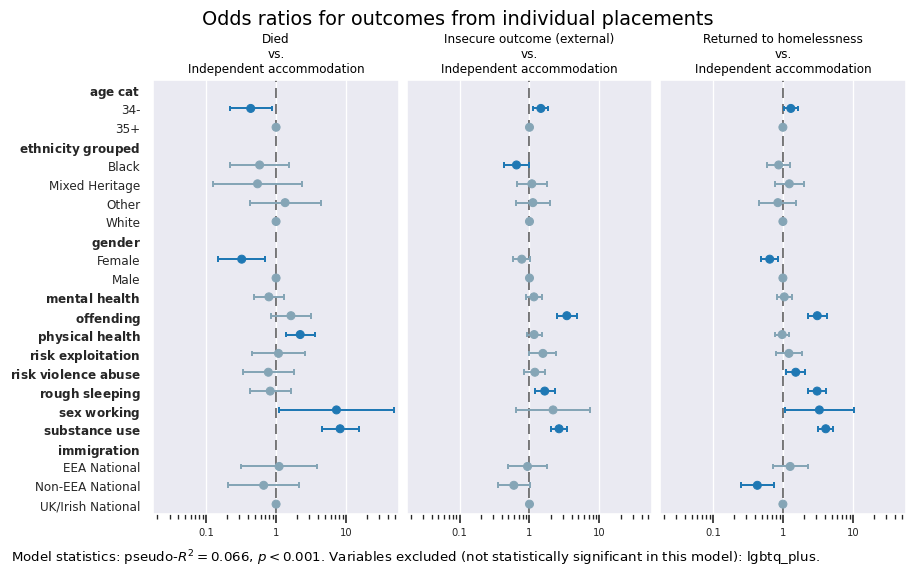

```python
from itertools import product
figure_minor_i += 1
theme = {"ytick.labelsize": "medium"}
ref_cats_used = {k: v for k, v in ref_cats.items() if k in ["gender", "age_cat", "ethnicity_grouped", "uk_immigration_status"]}
shorter_iv = {r"uk\ immigration\ status": "immigration"}
cols_removed = cols_to_remove
cols_removed = [col for col in cols_to_remove if col != "multiple_disadvantage"]
for or_section, i_sub in [(slice(0, 3), "a"), (slice(3, None), "b")]:
    save_fmi = figure_minor_i
    temp_res_or = results_or_final.loc[results_or_final.index.levels[0][or_section]].copy()
    temp_res_or.index = temp_res_or.index.remove_unused_levels()
    figure_minor_i = str(figure_minor_i) + i_sub
    fig_str, fig = plot_odds_r(dv_str, dv.cat.categories[0], ref_cats_used, temp_res_or, replacements=shorter_iv, theme=theme, cols_removed=cols_removed)
    plt.show(block=False)
    figure_minor_i = save_fmi
```

# Outcomes from individual placements - ref category forwards moves

## Prepare DV

```python
# Get DV
dv_str = "Outcomes from individual placements"
dv = dv_dict[dv_str].iloc[:, 0].astype("category")
dv = dv.cat.reorder_categories(list(dv.value_counts().index))
```

## Prepare IVs

```python
selected_ch = {
    "demographics":  ["gender", "age_cat", "global_majority", "lgbtq_plus",
                      # "ethnicity_detailed", "ethnicity_grouped",
                      # "uk_immigration_status", "english_2nd_language",
                      ],
    "ethnicity_related": ["ethnicity_grouped", "uk_immigration_status"],
    "support_needs": ["offending", "physical_health", "mental_health", "substance_use", "multiple_disadvantage",
                      "rough_sleeping", "sex_working", "risk_violence_abuse", "risk_exploitation",],
    # "route_variables": ["referral_agency", "rt_duration_weeks", "rt_entry_point",]
}
cols_to_exclude = []
X, Xc, iv_df, iv_cols_used, ref_cats, binaries, dummy_cols = get_ivs(dv, cols_to_exclude, selected_ch)
```

## Model building

### Start with block for demographic variables

```python
block_ch = list(selected_ch.values())[0]
block_ch_d = ["(Intercept)"] + cols_with_dummies(block_ch, dummy_cols)
```

### Test associations between IVs for initial block

#### Cramer’s V

**Results**

p values indicated by asterisks: `***` if `p < 0.001`, `**` if `p < 0.01`, `*` if `p < 0.05`

```python
chi2_crv_results, disp = iv_assoc(iv_df, block_ch)
with pd.option_context("display.float_format", "{:,.3f}".format):
    display(disp)
```

| iv1 | iv2 | g | ac | gm | lp |
| --- | --- | --- | --- | --- | --- |
| gender | V | NaN | 0.128 | 0.059 | 0.161 |
|  | * | NaN | *** | *** | *** |
| age_cat | V | 0.128 | NaN | 0.076 | 0.101 |
|  | * | *** | NaN | *** | *** |
| global_majority | V | 0.059 | 0.076 | NaN | 0.012 |
|  | * | *** | *** | NaN |  |
| lgbtq_plus | V | 0.161 | 0.101 | 0.012 | NaN |
|  | * | *** | *** |  | NaN |

#### Variance Inflation Factor (VIF)

**Results**

```python
# Test multicollinearity with VIF
vif_data = vif(Xc[block_ch_d[1:]])
with pd.option_context("display.float_format", "{:,.3f}".format):
    display(vif_data)
```

| Feature | VIF |
| --- | --- |
| age_cat_34- | 1.324 |
| gender_Female | 1.207 |
| global_majority | 1.130 |
| lgbtq_plus | 1.081 |
| gender_Non-Binary | 1.024 |

### MNLogit iteration 0

**Results**

```python
cols_to_remove = []
values_to_remove = []
results, summary, results_or = multinomial_regression(dv, Xc[block_ch_d], cols_to_remove, dummy_cols)
```

MNLogit Regression Results

| Dep. Variable: | pl_outcome | No. Observations: | 4828 |
| --- | --- | --- | --- |
| Model: | MNLogit | Df Residuals: | 4792 |
| Method: | MLE | Df Model: | 30 |
| Date: | Sun, 21 Jun 2026 | Pseudo R-squ.: | 0.008228 |
| Time: | 14:50:38 | Log-Likelihood: | -8585.9 |
| converged: | False | LL-Null: | -8657.1 |
| Covariance Type: | nonrobust | LLR p-value: | 1.425e-16 |

| pl_outcome=Independent accommodation | coef | std err | z | P>\|z\| | [0.025 | 0.975] |
| --- | --- | --- | --- | --- | --- | --- |
| (Intercept) | -0.4653 | 0.065 | -7.147 | 0.000 | -0.593 | -0.338 |
| gender_Female | 0.0592 | 0.096 | 0.617 | 0.537 | -0.129 | 0.247 |
| gender_Non-Binary | -0.3379 | 0.639 | -0.529 | 0.597 | -1.591 | 0.915 |
| age_cat_34- | 0.0700 | 0.092 | 0.762 | 0.446 | -0.110 | 0.250 |
| global_majority | 0.4644 | 0.100 | 4.642 | 0.000 | 0.268 | 0.661 |
| lgbtq_plus | 0.2709 | 0.178 | 1.523 | 0.128 | -0.078 | 0.619 |
| pl_outcome=Internal move: sideways | coef | std err | z | P>\|z\| | [0.025 | 0.975] |
| (Intercept) | -0.1998 | 0.062 | -3.211 | 0.001 | -0.322 | -0.078 |
| gender_Female | -0.2079 | 0.098 | -2.121 | 0.034 | -0.400 | -0.016 |
| gender_Non-Binary | -0.4453 | 0.637 | -0.699 | 0.485 | -1.694 | 0.804 |
| age_cat_34- | 0.1898 | 0.091 | 2.078 | 0.038 | 0.011 | 0.369 |
| global_majority | -0.4912 | 0.116 | -4.231 | 0.000 | -0.719 | -0.264 |
| lgbtq_plus | -0.0806 | 0.191 | -0.421 | 0.674 | -0.456 | 0.295 |
| pl_outcome=Returned to homelessness | coef | std err | z | P>\|z\| | [0.025 | 0.975] |
| (Intercept) | -0.7295 | 0.073 | -9.975 | 0.000 | -0.873 | -0.586 |
| gender_Female | -0.2000 | 0.116 | -1.723 | 0.085 | -0.428 | 0.028 |
| gender_Non-Binary | -1.2155 | 1.077 | -1.128 | 0.259 | -3.327 | 0.896 |
| age_cat_34- | 0.0918 | 0.108 | 0.850 | 0.395 | -0.120 | 0.303 |
| global_majority | -0.2031 | 0.130 | -1.564 | 0.118 | -0.458 | 0.051 |
| lgbtq_plus | -0.1195 | 0.231 | -0.516 | 0.606 | -0.573 | 0.334 |
| pl_outcome=Internal move: backwards | coef | std err | z | P>\|z\| | [0.025 | 0.975] |
| (Intercept) | -0.8789 | 0.076 | -11.604 | 0.000 | -1.027 | -0.730 |
| gender_Female | 0.1745 | 0.112 | 1.561 | 0.119 | -0.045 | 0.394 |
| gender_Non-Binary | -0.4864 | 0.813 | -0.598 | 0.550 | -2.081 | 1.108 |
| age_cat_34- | -0.0342 | 0.110 | -0.310 | 0.757 | -0.250 | 0.182 |
| global_majority | -0.0820 | 0.129 | -0.634 | 0.526 | -0.335 | 0.171 |
| lgbtq_plus | 0.2513 | 0.209 | 1.202 | 0.229 | -0.159 | 0.661 |
| pl_outcome=Insecure outcome (external) | coef | std err | z | P>\|z\| | [0.025 | 0.975] |
| (Intercept) | -0.9930 | 0.079 | -12.617 | 0.000 | -1.147 | -0.839 |
| gender_Female | -0.1507 | 0.120 | -1.260 | 0.208 | -0.385 | 0.084 |
| gender_Non-Binary | -20.6046 | 1.54e+04 | -0.001 | 0.999 | -3.02e+04 | 3.02e+04 |
| age_cat_34- | 0.3072 | 0.110 | 2.784 | 0.005 | 0.091 | 0.523 |
| global_majority | -0.0275 | 0.130 | -0.212 | 0.832 | -0.282 | 0.227 |
| lgbtq_plus | 0.2172 | 0.216 | 1.006 | 0.314 | -0.206 | 0.640 |
| pl_outcome=Died | coef | std err | z | P>\|z\| | [0.025 | 0.975] |
| (Intercept) | -2.0874 | 0.134 | -15.585 | 0.000 | -2.350 | -1.825 |
| gender_Female | -0.7854 | 0.298 | -2.632 | 0.008 | -1.370 | -0.200 |
| gender_Non-Binary | -14.5638 | 2165.320 | -0.007 | 0.995 | -4258.513 | 4229.385 |
| age_cat_34- | -0.8570 | 0.291 | -2.949 | 0.003 | -1.427 | -0.287 |
| global_majority | -0.8925 | 0.359 | -2.487 | 0.013 | -1.596 | -0.189 |
| lgbtq_plus | -0.0998 | 0.529 | -0.189 | 0.850 | -1.136 | 0.936 |

|  | Odds Ratios | p | * | odds_r | [0.025 | 0.975] |
| --- | --- | --- | --- | --- | --- | --- |
| gender_Non-Binary | Independent accommodation | 0.597 |  | 0.713 | 0.204 | 2.497 |
|  | Insecure outcome (external) | 0.999 |  | 0.000 | 0.000 | inf |
|  | Died | 0.995 |  | 0.000 | 0.000 | inf |
|  | Internal move: backwards | 0.550 |  | 0.615 | 0.125 | 3.028 |
|  | Internal move: sideways | 0.485 |  | 0.641 | 0.184 | 2.234 |
|  | Returned to homelessness | 0.259 |  | 0.297 | 0.036 | 2.450 |
| lgbtq_plus | Died | 0.850 |  | 0.905 | 0.321 | 2.551 |
|  | Internal move: sideways | 0.674 |  | 0.923 | 0.634 | 1.343 |
|  | Internal move: backwards | 0.229 |  | 1.286 | 0.853 | 1.937 |
|  | Returned to homelessness | 0.606 |  | 0.887 | 0.564 | 1.397 |
|  | Insecure outcome (external) | 0.314 |  | 1.243 | 0.814 | 1.897 |
|  | Independent accommodation | 0.128 |  | 1.311 | 0.925 | 1.858 |
| gender_Female | Insecure outcome (external) | 0.208 |  | 0.860 | 0.680 | 1.087 |
|  | Returned to homelessness | 0.085 |  | 0.819 | 0.652 | 1.028 |
|  | Died | 0.008 | * | 0.456 | 0.254 | 0.818 |
|  | Internal move: sideways | 0.034 | * | 0.812 | 0.670 | 0.984 |
|  | Independent accommodation | 0.537 |  | 1.061 | 0.879 | 1.280 |
|  | Internal move: backwards | 0.119 |  | 1.191 | 0.956 | 1.482 |
| age_cat_34- | Returned to homelessness | 0.395 |  | 1.096 | 0.887 | 1.355 |
|  | Internal move: sideways | 0.038 | * | 1.209 | 1.011 | 1.446 |
|  | Died | 0.003 | * | 0.424 | 0.240 | 0.750 |
|  | Internal move: backwards | 0.757 |  | 0.966 | 0.779 | 1.200 |
|  | Insecure outcome (external) | 0.005 | * | 1.360 | 1.095 | 1.688 |
|  | Independent accommodation | 0.446 |  | 1.073 | 0.896 | 1.284 |
| global_majority | Insecure outcome (external) | 0.832 |  | 0.973 | 0.754 | 1.255 |
|  | Internal move: sideways | 0.000 | * | 0.612 | 0.487 | 0.768 |
|  | Independent accommodation | 0.000 | * | 1.591 | 1.308 | 1.936 |
|  | Internal move: backwards | 0.526 |  | 0.921 | 0.715 | 1.187 |
|  | Returned to homelessness | 0.118 |  | 0.816 | 0.633 | 1.053 |
|  | Died | 0.013 | * | 0.410 | 0.203 | 0.828 |
| (Intercept) | Independent accommodation | 0.000 | * | 0.628 | 0.553 | 0.713 |
|  | Died | 0.000 | * | 0.124 | 0.095 | 0.161 |
|  | Insecure outcome (external) | 0.000 | * | 0.370 | 0.318 | 0.432 |
|  | Returned to homelessness | 0.000 | * | 0.482 | 0.418 | 0.556 |
|  | Internal move: sideways | 0.001 | * | 0.819 | 0.725 | 0.925 |
|  | Internal move: backwards | 0.000 | * | 0.415 | 0.358 | 0.482 |

```
Psuedo R^2: 0.008228370606949809
--------------------------------------------------
```

### MNLogit iteration 1

Recode `gender=Non-Binary` as missing because there are too few data points: recode variable.

**Results**

```python
selected_dv, selected_xc, sel_block_ch_d = dv_xc_remove_value(dv, Xc, block_ch_d, "gender_Non-Binary")
# cols_to_remove += ["gender_Non-Binary"]
results, summary, results_or = multinomial_regression(selected_dv, selected_xc[sel_block_ch_d], cols_to_remove, dummy_cols)
```

```
Optimization terminated successfully.
         Current function value: 1.779499
         Iterations 8
```

MNLogit Regression Results

| Dep. Variable: | pl_outcome | No. Observations: | 4810 |
| --- | --- | --- | --- |
| Model: | MNLogit | Df Residuals: | 4780 |
| Method: | MLE | Df Model: | 24 |
| Date: | Sun, 21 Jun 2026 | Pseudo R-squ.: | 0.007960 |
| Time: | 14:50:40 | Log-Likelihood: | -8559.4 |
| converged: | True | LL-Null: | -8628.1 |
| Covariance Type: | nonrobust | LLR p-value: | 7.093e-18 |

| pl_outcome=Independent accommodation | coef | std err | z | P>\|z\| | [0.025 | 0.975] |
| --- | --- | --- | --- | --- | --- | --- |
| (Intercept) | -0.4691 | 0.065 | -7.198 | 0.000 | -0.597 | -0.341 |
| gender_Female | 0.0577 | 0.096 | 0.602 | 0.547 | -0.130 | 0.246 |
| age_cat_34- | 0.0812 | 0.092 | 0.882 | 0.378 | -0.099 | 0.261 |
| global_majority | 0.4635 | 0.100 | 4.631 | 0.000 | 0.267 | 0.660 |
| lgbtq_plus | 0.2794 | 0.181 | 1.546 | 0.122 | -0.075 | 0.634 |
| pl_outcome=Internal move: sideways | coef | std err | z | P>\|z\| | [0.025 | 0.975] |
| (Intercept) | -0.1996 | 0.062 | -3.207 | 0.001 | -0.322 | -0.078 |
| gender_Female | -0.2090 | 0.098 | -2.132 | 0.033 | -0.401 | -0.017 |
| age_cat_34- | 0.1916 | 0.092 | 2.092 | 0.036 | 0.012 | 0.371 |
| global_majority | -0.5005 | 0.116 | -4.301 | 0.000 | -0.729 | -0.272 |
| lgbtq_plus | -0.0608 | 0.194 | -0.313 | 0.755 | -0.442 | 0.320 |
| pl_outcome=Returned to homelessness | coef | std err | z | P>\|z\| | [0.025 | 0.975] |
| (Intercept) | -0.7341 | 0.073 | -10.030 | 0.000 | -0.878 | -0.591 |
| gender_Female | -0.2023 | 0.116 | -1.742 | 0.081 | -0.430 | 0.025 |
| age_cat_34- | 0.1026 | 0.108 | 0.949 | 0.343 | -0.109 | 0.314 |
| global_majority | -0.2052 | 0.130 | -1.580 | 0.114 | -0.460 | 0.049 |
| lgbtq_plus | -0.0830 | 0.232 | -0.357 | 0.721 | -0.538 | 0.372 |
| pl_outcome=Internal move: backwards | coef | std err | z | P>\|z\| | [0.025 | 0.975] |
| (Intercept) | -0.8840 | 0.076 | -11.660 | 0.000 | -1.033 | -0.735 |
| gender_Female | 0.1722 | 0.112 | 1.539 | 0.124 | -0.047 | 0.391 |
| age_cat_34- | -0.0263 | 0.111 | -0.238 | 0.812 | -0.243 | 0.190 |
| global_majority | -0.0830 | 0.129 | -0.642 | 0.521 | -0.336 | 0.171 |
| lgbtq_plus | 0.3028 | 0.210 | 1.444 | 0.149 | -0.108 | 0.714 |
| pl_outcome=Insecure outcome (external) | coef | std err | z | P>\|z\| | [0.025 | 0.975] |
| (Intercept) | -0.9950 | 0.079 | -12.642 | 0.000 | -1.149 | -0.841 |
| gender_Female | -0.1519 | 0.120 | -1.270 | 0.204 | -0.386 | 0.083 |
| age_cat_34- | 0.3125 | 0.110 | 2.830 | 0.005 | 0.096 | 0.529 |
| global_majority | -0.0297 | 0.130 | -0.228 | 0.820 | -0.285 | 0.225 |
| lgbtq_plus | 0.2354 | 0.217 | 1.085 | 0.278 | -0.190 | 0.661 |
| pl_outcome=Died | coef | std err | z | P>\|z\| | [0.025 | 0.975] |
| (Intercept) | -2.0893 | 0.134 | -15.600 | 0.000 | -2.352 | -1.827 |
| gender_Female | -0.7866 | 0.298 | -2.636 | 0.008 | -1.372 | -0.202 |
| age_cat_34- | -0.8518 | 0.291 | -2.931 | 0.003 | -1.421 | -0.282 |
| global_majority | -0.8948 | 0.359 | -2.493 | 0.013 | -1.598 | -0.191 |
| lgbtq_plus | -0.0815 | 0.529 | -0.154 | 0.878 | -1.118 | 0.956 |

|  | Odds Ratios | p | * | odds_r | [0.025 | 0.975] |
| --- | --- | --- | --- | --- | --- | --- |
| lgbtq_plus | Died | 0.878 |  | 0.922 | 0.327 | 2.600 |
|  | Internal move: sideways | 0.755 |  | 0.941 | 0.643 | 1.377 |
|  | Internal move: backwards | 0.149 |  | 1.354 | 0.897 | 2.042 |
|  | Returned to homelessness | 0.721 |  | 0.920 | 0.584 | 1.451 |
|  | Insecure outcome (external) | 0.278 |  | 1.265 | 0.827 | 1.936 |
|  | Independent accommodation | 0.122 |  | 1.322 | 0.928 | 1.884 |
| gender_Female | Independent accommodation | 0.547 |  | 1.059 | 0.878 | 1.279 |
|  | Internal move: sideways | 0.033 | * | 0.811 | 0.670 | 0.983 |
|  | Insecure outcome (external) | 0.204 |  | 0.859 | 0.680 | 1.086 |
|  | Died | 0.008 | * | 0.455 | 0.254 | 0.817 |
|  | Returned to homelessness | 0.081 |  | 0.817 | 0.651 | 1.026 |
|  | Internal move: backwards | 0.124 |  | 1.188 | 0.954 | 1.479 |
| age_cat_34- | Insecure outcome (external) | 0.005 | * | 1.367 | 1.101 | 1.697 |
|  | Independent accommodation | 0.378 |  | 1.085 | 0.906 | 1.299 |
|  | Internal move: backwards | 0.812 |  | 0.974 | 0.784 | 1.210 |
|  | Returned to homelessness | 0.343 |  | 1.108 | 0.896 | 1.370 |
|  | Died | 0.003 | * | 0.427 | 0.241 | 0.754 |
|  | Internal move: sideways | 0.036 | * | 1.211 | 1.012 | 1.449 |
| global_majority | Independent accommodation | 0.000 | * | 1.590 | 1.306 | 1.934 |
|  | Returned to homelessness | 0.114 |  | 0.814 | 0.631 | 1.051 |
|  | Internal move: backwards | 0.521 |  | 0.920 | 0.714 | 1.186 |
|  | Internal move: sideways | 0.000 | * | 0.606 | 0.483 | 0.762 |
|  | Insecure outcome (external) | 0.820 |  | 0.971 | 0.752 | 1.253 |
|  | Died | 0.013 | * | 0.409 | 0.202 | 0.826 |
| (Intercept) | Died | 0.000 | * | 0.124 | 0.095 | 0.161 |
|  | Independent accommodation | 0.000 | * | 0.626 | 0.551 | 0.711 |
|  | Insecure outcome (external) | 0.000 | * | 0.370 | 0.317 | 0.431 |
|  | Returned to homelessness | 0.000 | * | 0.480 | 0.416 | 0.554 |
|  | Internal move: sideways | 0.001 | * | 0.819 | 0.725 | 0.925 |
|  | Internal move: backwards | 0.000 | * | 0.413 | 0.356 | 0.479 |

```
Psuedo R^2: 0.00796013315674482
--------------------------------------------------
```

### MNLogit iteration 2

**Results**

```python
cols_to_remove += ["lgbtq_plus"]
results, summary, results_or = multinomial_regression(selected_dv, selected_xc[sel_block_ch_d], cols_to_remove, dummy_cols)
```

```
Optimization terminated successfully.
         Current function value: 1.777642
         Iterations 8
```

MNLogit Regression Results

| Dep. Variable: | pl_outcome | No. Observations: | 5792 |
| --- | --- | --- | --- |
| Model: | MNLogit | Df Residuals: | 5768 |
| Method: | MLE | Df Model: | 18 |
| Date: | Sun, 21 Jun 2026 | Pseudo R-squ.: | 0.009510 |
| Time: | 14:50:41 | Log-Likelihood: | -10296. |
| converged: | True | LL-Null: | -10395. |
| Covariance Type: | nonrobust | LLR p-value: | 2.871e-32 |

| pl_outcome=Independent accommodation | coef | std err | z | P>\|z\| | [0.025 | 0.975] |
| --- | --- | --- | --- | --- | --- | --- |
| (Intercept) | -0.4082 | 0.059 | -6.926 | 0.000 | -0.524 | -0.293 |
| gender_Female | 0.0743 | 0.087 | 0.858 | 0.391 | -0.096 | 0.244 |
| age_cat_34- | 0.0206 | 0.083 | 0.248 | 0.804 | -0.142 | 0.183 |
| global_majority | 0.5146 | 0.090 | 5.726 | 0.000 | 0.338 | 0.691 |
| pl_outcome=Internal move: sideways | coef | std err | z | P>\|z\| | [0.025 | 0.975] |
| (Intercept) | -0.1491 | 0.056 | -2.640 | 0.008 | -0.260 | -0.038 |
| gender_Female | -0.3106 | 0.091 | -3.415 | 0.001 | -0.489 | -0.132 |
| age_cat_34- | 0.1589 | 0.083 | 1.907 | 0.057 | -0.004 | 0.322 |
| global_majority | -0.5508 | 0.107 | -5.151 | 0.000 | -0.760 | -0.341 |
| pl_outcome=Returned to homelessness | coef | std err | z | P>\|z\| | [0.025 | 0.975] |
| (Intercept) | -0.6862 | 0.066 | -10.378 | 0.000 | -0.816 | -0.557 |
| gender_Female | -0.2960 | 0.106 | -2.783 | 0.005 | -0.505 | -0.088 |
| age_cat_34- | 0.1459 | 0.097 | 1.510 | 0.131 | -0.044 | 0.335 |
| global_majority | -0.2276 | 0.117 | -1.943 | 0.052 | -0.457 | 0.002 |
| pl_outcome=Internal move: backwards | coef | std err | z | P>\|z\| | [0.025 | 0.975] |
| (Intercept) | -0.9101 | 0.070 | -12.927 | 0.000 | -1.048 | -0.772 |
| gender_Female | 0.2261 | 0.103 | 2.200 | 0.028 | 0.025 | 0.428 |
| age_cat_34- | -0.0002 | 0.101 | -0.002 | 0.998 | -0.198 | 0.198 |
| global_majority | -0.1320 | 0.120 | -1.098 | 0.272 | -0.368 | 0.104 |
| pl_outcome=Insecure outcome (external) | coef | std err | z | P>\|z\| | [0.025 | 0.975] |
| (Intercept) | -0.9187 | 0.071 | -12.964 | 0.000 | -1.058 | -0.780 |
| gender_Female | -0.1834 | 0.109 | -1.675 | 0.094 | -0.398 | 0.031 |
| age_cat_34- | 0.2354 | 0.100 | 2.345 | 0.019 | 0.039 | 0.432 |
| global_majority | -0.0605 | 0.119 | -0.510 | 0.610 | -0.293 | 0.172 |
| pl_outcome=Died | coef | std err | z | P>\|z\| | [0.025 | 0.975] |
| (Intercept) | -2.0240 | 0.119 | -17.021 | 0.000 | -2.257 | -1.791 |
| gender_Female | -0.9199 | 0.284 | -3.234 | 0.001 | -1.477 | -0.362 |
| age_cat_34- | -1.0713 | 0.277 | -3.871 | 0.000 | -1.614 | -0.529 |
| global_majority | -0.6298 | 0.294 | -2.145 | 0.032 | -1.205 | -0.054 |

Variables removed: ['lgbtq_plus']

|  |  | p | * | odds_r | [0.025 | 0.975] | prev_coef | coef | diff_pct |
| --- | --- | --- | --- | --- | --- | --- | --- | --- | --- |
| gender_Female | Returned to homelessness | 0.005 | * | 0.744 | 0.604 | 0.916 | -0.202 | -0.296 | 46.400 |
|  | Died | 0.001 | * | 0.399 | 0.228 | 0.696 | -0.787 | -0.920 | 16.900 |
|  | Insecure outcome (external) | 0.094 |  | 0.832 | 0.672 | 1.032 | -0.152 | -0.183 | 20.700 |
|  | Internal move: backwards | 0.028 | * | 1.254 | 1.025 | 1.534 | 0.172 | 0.226 | 31.300 |
|  | Internal move: sideways | 0.001 | * | 0.733 | 0.613 | 0.876 | -0.209 | -0.311 | 48.600 |
|  | Independent accommodation | 0.391 |  | 1.077 | 0.909 | 1.277 | 0.058 | 0.074 | 28.700 |
| age_cat_34- | Internal move: backwards | 0.998 |  | 1.000 | 0.820 | 1.219 | -0.026 | -0.000 | -99.100 |
|  | Returned to homelessness | 0.131 |  | 1.157 | 0.957 | 1.398 | 0.103 | 0.146 | 42.200 |
|  | Insecure outcome (external) | 0.019 | * | 1.265 | 1.039 | 1.541 | 0.312 | 0.235 | -24.700 |
|  | Internal move: sideways | 0.057 |  | 1.172 | 0.996 | 1.380 | 0.192 | 0.159 | -17.000 |
|  | Died | 0.000 | * | 0.343 | 0.199 | 0.589 | -0.852 | -1.071 | 25.800 |
|  | Independent accommodation | 0.804 |  | 1.021 | 0.868 | 1.201 | 0.081 | 0.021 | -74.600 |
| global_majority | Insecure outcome (external) | 0.610 |  | 0.941 | 0.746 | 1.188 | -0.030 | -0.061 | 104.000 |
|  | Internal move: sideways | 0.000 | * | 0.576 | 0.467 | 0.711 | -0.500 | -0.551 | 10.100 |
|  | Returned to homelessness | 0.052 |  | 0.796 | 0.633 | 1.002 | -0.205 | -0.228 | 10.900 |
|  | Independent accommodation | 0.000 | * | 1.673 | 1.403 | 1.995 | 0.464 | 0.515 | 11.000 |
|  | Internal move: backwards | 0.272 |  | 0.876 | 0.692 | 1.109 | -0.083 | -0.132 | 59.100 |
|  | Died | 0.032 | * | 0.533 | 0.300 | 0.947 | -0.895 | -0.630 | -29.600 |
| (Intercept) | Died | 0.000 | * | 0.132 | 0.105 | 0.167 | -2.089 | -2.024 | -3.100 |
|  | Independent accommodation | 0.000 | * | 0.665 | 0.592 | 0.746 | -0.469 | -0.408 | -13.000 |
|  | Insecure outcome (external) | 0.000 | * | 0.399 | 0.347 | 0.458 | -0.995 | -0.919 | -7.700 |
|  | Returned to homelessness | 0.000 | * | 0.503 | 0.442 | 0.573 | -0.734 | -0.686 | -6.500 |
|  | Internal move: sideways | 0.008 | * | 0.861 | 0.771 | 0.962 | -0.200 | -0.149 | -25.300 |
|  | Internal move: backwards | 0.000 | * | 0.402 | 0.351 | 0.462 | -0.884 | -0.910 | 3.000 |

```
Psuedo R^2: 0.009510029614843929
--------------------------------------------------
```

### Add block for grouped ethnicity data and drop “global_majority”

```python
new_block_ch = selected_ch["ethnicity_related"]
sel_block_ch = [ch for ch in block_ch + new_block_ch if ch != "global_majority"]
sel_block_ch_d = [ch for ch in sel_block_ch_d + cols_with_dummies(new_block_ch, dummy_cols) if ch != "global_majority"]
```

### Test associations between IVs now a block has been added

#### Cramer’s V

**Results**

p values indicated by asterisks: `***` if `p < 0.001`, `**` if `p < 0.01`, `*` if `p < 0.05`

```python
chi2_crv_results, disp = iv_assoc(iv_df, sel_block_ch)
with pd.option_context("display.float_format", "{:,.3f}".format):
    display(disp)
```

| iv1 | iv2 | g | ac | lp | eg | uis |
| --- | --- | --- | --- | --- | --- | --- |
| gender | V | NaN | 0.112 | 0.165 | 0.073 | 0.048 |
|  | * | NaN | *** | *** | *** | ** |
| age_cat | V | 0.112 | NaN | 0.103 | 0.070 | 0.078 |
|  | * | *** | NaN | *** | *** | *** |
| lgbtq_plus | V | 0.165 | 0.103 | NaN | 0.058 | 0.022 |
|  | * | *** | *** | NaN | ** |  |
| ethnicity_grouped | V | 0.073 | 0.070 | 0.058 | NaN | 0.381 |
|  | * | *** | *** | ** | NaN | *** |
| uk_immigration_status | V | 0.048 | 0.078 | 0.022 | 0.381 | NaN |
|  | * | ** | *** |  | *** | NaN |

#### Variance Inflation Factor (VIF)

**Results**

```python
# Test multicollinearity with VIF
vif_data = vif(Xc[sel_block_ch_d[1:]])
with pd.option_context("display.float_format", "{:,.3f}".format):
    display(vif_data)
```

| Feature | VIF |
| --- | --- |
| uk_immigration_status_Non-EEA National | 1.502 |
| ethnicity_grouped_Black | 1.315 |
| age_cat_34- | 1.311 |
| ethnicity_grouped_Other | 1.260 |
| gender_Female | 1.208 |
| lgbtq_plus | 1.067 |
| ethnicity_grouped_Mixed Heritage | 1.046 |
| uk_immigration_status_EEA National | 1.044 |

No significant multicollinearity. Proceeding with MNLogit.

```python
results, summary, results_or = multinomial_regression(selected_dv, selected_xc[sel_block_ch_d], [], dummy_cols)
```

### MNLogit iteration 3

**Results**

```python
results, summary, results_or = multinomial_regression(selected_dv, selected_xc[sel_block_ch_d], cols_to_remove, dummy_cols)
```

```
Optimization terminated successfully.
         Current function value: 1.755207
         Iterations 8
```

MNLogit Regression Results

| Dep. Variable: | pl_outcome | No. Observations: | 5108 |
| --- | --- | --- | --- |
| Model: | MNLogit | Df Residuals: | 5060 |
| Method: | MLE | Df Model: | 42 |
| Date: | Sun, 21 Jun 2026 | Pseudo R-squ.: | 0.01346 |
| Time: | 14:50:45 | Log-Likelihood: | -8965.6 |
| converged: | True | LL-Null: | -9087.9 |
| Covariance Type: | nonrobust | LLR p-value: | 2.104e-30 |

| pl_outcome=Independent accommodation | coef | std err | z | P>\|z\| | [0.025 | 0.975] |
| --- | --- | --- | --- | --- | --- | --- |
| (Intercept) | -0.6788 | 0.067 | -10.160 | 0.000 | -0.810 | -0.548 |
| gender_Female | 0.1513 | 0.097 | 1.565 | 0.118 | -0.038 | 0.341 |
| age_cat_34- | 0.0454 | 0.092 | 0.493 | 0.622 | -0.135 | 0.226 |
| ethnicity_grouped_Black | 0.5367 | 0.139 | 3.865 | 0.000 | 0.265 | 0.809 |
| ethnicity_grouped_Mixed Heritage | 0.2090 | 0.199 | 1.052 | 0.293 | -0.180 | 0.598 |
| ethnicity_grouped_Other | 0.4424 | 0.207 | 2.136 | 0.033 | 0.037 | 0.848 |
| uk_immigration_status_Non-EEA National | 0.1914 | 0.166 | 1.151 | 0.250 | -0.134 | 0.517 |
| uk_immigration_status_EEA National | 0.0995 | 0.235 | 0.423 | 0.672 | -0.361 | 0.560 |
| pl_outcome=Internal move: sideways | coef | std err | z | P>\|z\| | [0.025 | 0.975] |
| (Intercept) | -0.0924 | 0.059 | -1.578 | 0.115 | -0.207 | 0.022 |
| gender_Female | -0.3222 | 0.094 | -3.438 | 0.001 | -0.506 | -0.139 |
| age_cat_34- | 0.2019 | 0.086 | 2.360 | 0.018 | 0.034 | 0.370 |
| ethnicity_grouped_Black | -0.4520 | 0.158 | -2.853 | 0.004 | -0.763 | -0.141 |
| ethnicity_grouped_Mixed Heritage | -0.0389 | 0.189 | -0.206 | 0.837 | -0.409 | 0.332 |
| ethnicity_grouped_Other | -0.4079 | 0.250 | -1.633 | 0.102 | -0.897 | 0.082 |
| uk_immigration_status_Non-EEA National | -0.8576 | 0.223 | -3.840 | 0.000 | -1.295 | -0.420 |
| uk_immigration_status_EEA National | -0.6093 | 0.268 | -2.277 | 0.023 | -1.134 | -0.085 |
| pl_outcome=Returned to homelessness | coef | std err | z | P>\|z\| | [0.025 | 0.975] |
| (Intercept) | -0.6984 | 0.070 | -10.010 | 0.000 | -0.835 | -0.562 |
| gender_Female | -0.2975 | 0.112 | -2.658 | 0.008 | -0.517 | -0.078 |
| age_cat_34- | 0.1359 | 0.102 | 1.336 | 0.181 | -0.063 | 0.335 |
| ethnicity_grouped_Black | -0.1065 | 0.175 | -0.610 | 0.542 | -0.449 | 0.236 |
| ethnicity_grouped_Mixed Heritage | 0.2217 | 0.211 | 1.052 | 0.293 | -0.191 | 0.635 |
| ethnicity_grouped_Other | -0.3053 | 0.292 | -1.047 | 0.295 | -0.877 | 0.266 |
| uk_immigration_status_Non-EEA National | -0.7761 | 0.256 | -3.029 | 0.002 | -1.278 | -0.274 |
| uk_immigration_status_EEA National | 0.0558 | 0.261 | 0.213 | 0.831 | -0.457 | 0.568 |
| pl_outcome=Internal move: backwards | coef | std err | z | P>\|z\| | [0.025 | 0.975] |
| (Intercept) | -0.8745 | 0.073 | -11.997 | 0.000 | -1.017 | -0.732 |
| gender_Female | 0.1949 | 0.106 | 1.836 | 0.066 | -0.013 | 0.403 |
| age_cat_34- | 0.0180 | 0.104 | 0.173 | 0.862 | -0.185 | 0.221 |
| ethnicity_grouped_Black | -0.1921 | 0.180 | -1.066 | 0.286 | -0.545 | 0.161 |
| ethnicity_grouped_Mixed Heritage | 0.1587 | 0.214 | 0.741 | 0.459 | -0.261 | 0.579 |
| ethnicity_grouped_Other | -0.5674 | 0.302 | -1.881 | 0.060 | -1.158 | 0.024 |
| uk_immigration_status_Non-EEA National | 0.0429 | 0.216 | 0.198 | 0.843 | -0.381 | 0.466 |
| uk_immigration_status_EEA National | 0.1162 | 0.265 | 0.438 | 0.662 | -0.404 | 0.636 |
| pl_outcome=Insecure outcome (external) | coef | std err | z | P>\|z\| | [0.025 | 0.975] |
| (Intercept) | -1.0477 | 0.078 | -13.399 | 0.000 | -1.201 | -0.894 |
| gender_Female | -0.1811 | 0.121 | -1.501 | 0.133 | -0.418 | 0.055 |
| age_cat_34- | 0.2747 | 0.110 | 2.500 | 0.012 | 0.059 | 0.490 |
| ethnicity_grouped_Black | -0.2390 | 0.199 | -1.200 | 0.230 | -0.629 | 0.151 |
| ethnicity_grouped_Mixed Heritage | 0.1645 | 0.233 | 0.705 | 0.481 | -0.293 | 0.622 |
| ethnicity_grouped_Other | 0.1676 | 0.274 | 0.613 | 0.540 | -0.369 | 0.704 |
| uk_immigration_status_Non-EEA National | -0.4925 | 0.255 | -1.929 | 0.054 | -0.993 | 0.008 |
| uk_immigration_status_EEA National | -0.2294 | 0.312 | -0.735 | 0.463 | -0.841 | 0.383 |
| pl_outcome=Died | coef | std err | z | P>\|z\| | [0.025 | 0.975] |
| (Intercept) | -2.2682 | 0.140 | -16.199 | 0.000 | -2.543 | -1.994 |
| gender_Female | -0.9931 | 0.346 | -2.873 | 0.004 | -1.670 | -0.316 |
| age_cat_34- | -1.2269 | 0.344 | -3.565 | 0.000 | -1.901 | -0.552 |
| ethnicity_grouped_Black | -0.6457 | 0.492 | -1.313 | 0.189 | -1.610 | 0.318 |
| ethnicity_grouped_Mixed Heritage | -0.6524 | 0.730 | -0.894 | 0.371 | -2.083 | 0.778 |
| ethnicity_grouped_Other | 0.0666 | 0.598 | 0.111 | 0.911 | -1.106 | 1.239 |
| uk_immigration_status_Non-EEA National | -0.3299 | 0.603 | -0.547 | 0.585 | -1.513 | 0.853 |
| uk_immigration_status_EEA National | 0.1561 | 0.612 | 0.255 | 0.799 | -1.044 | 1.357 |

Variables removed: ['lgbtq_plus']

|  |  | p | * | odds_r | [0.025 | 0.975] | prev_coef | coef | diff_pct |
| --- | --- | --- | --- | --- | --- | --- | --- | --- | --- |
| ethnicity_grouped_Mixed Heritage | Independent accommodation | 0.293 |  | 1.232 | 0.835 | 1.819 | 0.192 | 0.209 | 8.700 |
|  | Insecure outcome (external) | 0.481 |  | 1.179 | 0.746 | 1.862 | 0.296 | 0.165 | -44.400 |
|  | Died | 0.371 |  | 0.521 | 0.125 | 2.177 | -0.377 | -0.652 | 73.200 |
|  | Internal move: backwards | 0.459 |  | 1.172 | 0.770 | 1.784 | 0.305 | 0.159 | -47.900 |
|  | Internal move: sideways | 0.837 |  | 0.962 | 0.664 | 1.393 | 0.063 | -0.039 | -161.500 |
|  | Returned to homelessness | 0.293 |  | 1.248 | 0.826 | 1.887 | 0.399 | 0.222 | -44.500 |
| ethnicity_grouped_Other | Returned to homelessness | 0.295 |  | 0.737 | 0.416 | 1.305 | -0.180 | -0.305 | 69.900 |
|  | Died | 0.911 |  | 1.069 | 0.331 | 3.451 | -0.452 | 0.067 | -114.700 |
|  | Insecure outcome (external) | 0.540 |  | 1.182 | 0.692 | 2.021 | 0.350 | 0.168 | -52.100 |
|  | Independent accommodation | 0.033 | * | 1.556 | 1.037 | 2.336 | 0.485 | 0.442 | -8.700 |
|  | Internal move: backwards | 0.060 |  | 0.567 | 0.314 | 1.024 | -0.225 | -0.567 | 152.300 |
|  | Internal move: sideways | 0.102 |  | 0.665 | 0.408 | 1.085 | -0.278 | -0.408 | 46.600 |
| uk_immigration_status_EEA National | Insecure outcome (external) | 0.463 |  | 0.795 | 0.431 | 1.466 | -0.347 | -0.229 | -34.000 |
|  | Internal move: backwards | 0.662 |  | 1.123 | 0.668 | 1.890 | 0.000 | 0.116 | 154,851.900 |
|  | Returned to homelessness | 0.831 |  | 1.057 | 0.633 | 1.765 | -0.257 | 0.056 | -121.700 |
|  | Died | 0.799 |  | 1.169 | 0.352 | 3.883 | -0.078 | 0.156 | -299.000 |
|  | Internal move: sideways | 0.023 | * | 0.544 | 0.322 | 0.919 | -0.500 | -0.609 | 22.000 |
|  | Independent accommodation | 0.672 |  | 1.105 | 0.697 | 1.751 | -0.105 | 0.099 | -195.100 |
| gender_Female | Independent accommodation | 0.118 |  | 1.163 | 0.963 | 1.406 | 0.172 | 0.151 | -12.100 |
|  | Insecure outcome (external) | 0.133 |  | 0.834 | 0.659 | 1.057 | -0.136 | -0.181 | 32.900 |
|  | Returned to homelessness | 0.008 | * | 0.743 | 0.596 | 0.925 | -0.218 | -0.298 | 36.600 |
|  | Internal move: backwards | 0.066 |  | 1.215 | 0.987 | 1.496 | 0.146 | 0.195 | 33.800 |
|  | Internal move: sideways | 0.001 | * | 0.725 | 0.603 | 0.871 | -0.223 | -0.322 | 44.600 |
|  | Died | 0.004 | * | 0.370 | 0.188 | 0.729 | -0.929 | -0.993 | 6.900 |
| age_cat_34- | Died | 0.000 | * | 0.293 | 0.149 | 0.576 | -0.942 | -1.227 | 30.300 |
|  | Internal move: backwards | 0.862 |  | 1.018 | 0.831 | 1.248 | -0.021 | 0.018 | -184.400 |
|  | Internal move: sideways | 0.018 | * | 1.224 | 1.035 | 1.447 | 0.230 | 0.202 | -12.400 |
|  | Returned to homelessness | 0.181 |  | 1.146 | 0.939 | 1.398 | 0.090 | 0.136 | 50.900 |
|  | Insecure outcome (external) | 0.012 | * | 1.316 | 1.061 | 1.633 | 0.331 | 0.275 | -17.100 |
|  | Independent accommodation | 0.622 |  | 1.046 | 0.874 | 1.253 | 0.099 | 0.045 | -54.100 |
| uk_immigration_status_Non-EEA National | Insecure outcome (external) | 0.054 |  | 0.611 | 0.371 | 1.008 | -0.538 | -0.492 | -8.400 |
|  | Internal move: sideways | 0.000 | * | 0.424 | 0.274 | 0.657 | -0.827 | -0.858 | 3.800 |
|  | Internal move: backwards | 0.843 |  | 1.044 | 0.683 | 1.594 | -0.073 | 0.043 | -159.100 |
|  | Died | 0.585 |  | 0.719 | 0.220 | 2.347 | -0.077 | -0.330 | 325.700 |
|  | Returned to homelessness | 0.002 | * | 0.460 | 0.279 | 0.760 | -0.936 | -0.776 | -17.100 |
|  | Independent accommodation | 0.250 |  | 1.211 | 0.874 | 1.677 | 0.224 | 0.191 | -14.400 |
| ethnicity_grouped_Black | Died | 0.189 |  | 0.524 | 0.200 | 1.375 | -0.781 | -0.646 | -17.400 |
|  | Internal move: sideways | 0.004 | * | 0.636 | 0.466 | 0.868 | -0.426 | -0.452 | 6.100 |
|  | Independent accommodation | 0.000 | * | 1.710 | 1.303 | 2.245 | 0.462 | 0.537 | 16.200 |
|  | Insecure outcome (external) | 0.230 |  | 0.787 | 0.533 | 1.163 | -0.190 | -0.239 | 25.800 |
|  | Internal move: backwards | 0.286 |  | 0.825 | 0.580 | 1.175 | -0.186 | -0.192 | 3.200 |
|  | Returned to homelessness | 0.542 |  | 0.899 | 0.638 | 1.266 | -0.147 | -0.107 | -27.500 |
| (Intercept) | Independent accommodation | 0.000 | * | 0.507 | 0.445 | 0.578 | -0.747 | -0.679 | -9.100 |
|  | Died | 0.000 | * | 0.103 | 0.079 | 0.136 | -2.351 | -2.268 | -3.500 |
|  | Insecure outcome (external) | 0.000 | * | 0.351 | 0.301 | 0.409 | -1.119 | -1.048 | -6.400 |
|  | Returned to homelessness | 0.000 | * | 0.497 | 0.434 | 0.570 | -0.761 | -0.698 | -8.200 |
|  | Internal move: sideways | 0.115 |  | 0.912 | 0.813 | 1.023 | -0.161 | -0.092 | -42.500 |
|  | Internal move: backwards | 0.000 | * | 0.417 | 0.362 | 0.481 | -0.850 | -0.875 | 2.900 |

```
Psuedo R^2: 0.013458012304746636
--------------------------------------------------
```

All variables are significant. Proceeding.

### Add block for support needs variables

```python
new_block_ch = selected_ch["support_needs"]
sel_block_ch = sel_block_ch + new_block_ch
sel_block_ch_d = sel_block_ch_d + cols_with_dummies(new_block_ch, dummy_cols)
```

### Test associations between IVs now a block has been added

#### Cramer’s V

**Results**

p values indicated by asterisks: `***` if `p < 0.001`, `**` if `p < 0.01`, `*` if `p < 0.05`

```python
chi2_crv_results, disp = iv_assoc(iv_df, sel_block_ch)
with pd.option_context("display.float_format", "{:,.3f}".format):
    display(disp)
```

| iv1 | iv2 | g | ac | lp | eg | uis | o | ph | mh | su | md | rs | sw | rva | re |
| --- | --- | --- | --- | --- | --- | --- | --- | --- | --- | --- | --- | --- | --- | --- | --- |
| gender | V | NaN | 0.112 | 0.166 | 0.073 | 0.048 | 0.132 | 0.037 | 0.120 | 0.040 | 0.074 | 0.032 | 0.300 | 0.380 | 0.140 |
|  | * | NaN | *** | *** | *** | ** | *** |  | *** |  | *** |  | *** | *** | *** |
| age_cat | V | 0.112 | NaN | 0.106 | 0.070 | 0.079 | 0.002 | 0.195 | 0.053 | 0.145 | 0.047 | 0.018 | 0.002 | 0.034 | 0.017 |
|  | * | *** | NaN | *** | *** | *** |  | *** | *** | *** | ** |  |  | * |  |
| lgbtq_plus | V | 0.166 | 0.106 | NaN | 0.060 | 0.022 | 0.030 | 0.016 | 0.018 | 0.050 | 0.026 | 0.006 | 0.001 | 0.005 | 0.026 |
|  | * | *** | *** | NaN | ** |  |  |  |  | ** |  |  |  |  |  |
| ethnicity_grouped | V | 0.073 | 0.070 | 0.060 | NaN | 0.381 | 0.076 | 0.089 | 0.093 | 0.262 | 0.203 | 0.086 | 0.091 | 0.051 | 0.065 |
|  | * | *** | *** | ** | NaN | *** | *** | *** | *** | *** | *** | *** | *** | * | *** |
| uk_immigration_status | V | 0.048 | 0.079 | 0.022 | 0.381 | NaN | 0.111 | 0.058 | 0.088 | 0.207 | 0.188 | 0.056 | 0.055 | 0.040 | 0.070 |
|  | * | ** | *** |  | *** | NaN | *** | *** | *** | *** | *** | ** | ** | * | *** |
| offending | V | 0.132 | 0.002 | 0.030 | 0.076 | 0.111 | NaN | 0.033 | 0.063 | 0.125 | 0.315 | 0.119 | 0.059 | 0.002 | 0.026 |
|  | * | *** |  |  | *** | *** | NaN | * | *** | *** | *** | *** | *** |  |  |
| physical_health | V | 0.037 | 0.195 | 0.016 | 0.089 | 0.058 | 0.033 | NaN | 0.099 | 0.107 | 0.115 | 0.130 | 0.105 | 0.091 | 0.086 |
|  | * |  | *** |  | *** | *** | * | NaN | *** | *** | *** | *** | *** | *** | *** |
| mental_health | V | 0.120 | 0.053 | 0.018 | 0.093 | 0.088 | 0.063 | 0.099 | NaN | 0.179 | 0.569 | 0.096 | 0.110 | 0.085 | 0.077 |
|  | * | *** | *** |  | *** | *** | *** | *** | NaN | *** | *** | *** | *** | *** | *** |
| substance_use | V | 0.040 | 0.145 | 0.050 | 0.262 | 0.207 | 0.125 | 0.107 | 0.179 | NaN | 0.659 | 0.219 | 0.126 | 0.041 | 0.146 |
|  | * |  | *** | ** | *** | *** | *** | *** | *** | NaN | *** | *** | *** | ** | *** |
| multiple_disadvantage | V | 0.074 | 0.047 | 0.026 | 0.203 | 0.188 | 0.315 | 0.115 | 0.569 | 0.659 | NaN | 0.205 | 0.138 | 0.283 | 0.167 |
|  | * | *** | ** |  | *** | *** | *** | *** | *** | *** | NaN | *** | *** | *** | *** |
| rough_sleeping | V | 0.032 | 0.018 | 0.006 | 0.086 | 0.056 | 0.119 | 0.130 | 0.096 | 0.219 | 0.205 | NaN | 0.084 | 0.045 | 0.018 |
|  | * |  |  |  | *** | ** | *** | *** | *** | *** | *** | NaN | *** | ** |  |
| sex_working | V | 0.300 | 0.002 | 0.001 | 0.091 | 0.055 | 0.059 | 0.105 | 0.110 | 0.126 | 0.138 | 0.084 | NaN | 0.286 | 0.220 |
|  | * | *** |  |  | *** | ** | *** | *** | *** | *** | *** | *** | NaN | *** | *** |
| risk_violence_abuse | V | 0.380 | 0.034 | 0.005 | 0.051 | 0.040 | 0.002 | 0.091 | 0.085 | 0.041 | 0.283 | 0.045 | 0.286 | NaN | 0.234 |
|  | * | *** | * |  | * | * |  | *** | *** | ** | *** | ** | *** | NaN | *** |
| risk_exploitation | V | 0.140 | 0.017 | 0.026 | 0.065 | 0.070 | 0.026 | 0.086 | 0.077 | 0.146 | 0.167 | 0.018 | 0.220 | 0.234 | NaN |
|  | * | *** |  |  | *** | *** |  | *** | *** | *** | *** |  | *** | *** | NaN |

#### Variance Inflation Factor (VIF)

**Results**

```python
# Test multicollinearity with VIF
vif_data = vif(Xc[sel_block_ch_d[1:]])
with pd.option_context("display.float_format", "{:,.3f}".format):
    display(vif_data)
```

| Feature | VIF |
| --- | --- |
| multiple_disadvantage | 9.158 |
| mental_health | 5.044 |
| substance_use | 4.720 |
| gender_Female | 1.762 |
| risk_violence_abuse | 1.762 |
| physical_health | 1.673 |
| age_cat_34- | 1.554 |
| uk_immigration_status_Non-EEA National | 1.515 |
| offending | 1.467 |
| rough_sleeping | 1.367 |
| ethnicity_grouped_Black | 1.359 |
| ethnicity_grouped_Other | 1.284 |
| risk_exploitation | 1.247 |
| sex_working | 1.242 |
| lgbtq_plus | 1.081 |
| ethnicity_grouped_Mixed Heritage | 1.066 |
| uk_immigration_status_EEA National | 1.055 |

`multiple_disadvantage` has high VIF due to multicollinearity of `multiple_disadvantage`, `substance_use` and `mental_health`.

Dropping `multiple_disadvantage` as previous models showed that separate needs explained more of the variance.

```python
sel_block_ch_d.remove("multiple_disadvantage")
```

```python
results, summary, results_or = multinomial_regression(selected_dv, selected_xc[sel_block_ch_d], [], dummy_cols)
```

### MNLogit iteration 4

**Results**

```python
results, summary, results_or = multinomial_regression(selected_dv, selected_xc[sel_block_ch_d], cols_to_remove, dummy_cols)
```

```
Optimization terminated successfully.
         Current function value: 1.662701
         Iterations 8
```

MNLogit Regression Results

| Dep. Variable: | pl_outcome | No. Observations: | 5016 |
| --- | --- | --- | --- |
| Model: | MNLogit | Df Residuals: | 4920 |
| Method: | MLE | Df Model: | 90 |
| Date: | Sun, 21 Jun 2026 | Pseudo R-squ.: | 0.06635 |
| Time: | 14:50:51 | Log-Likelihood: | -8340.1 |
| converged: | True | LL-Null: | -8932.8 |
| Covariance Type: | nonrobust | LLR p-value: | 1.627e-190 |

| pl_outcome=Independent accommodation | coef | std err | z | P>\|z\| | [0.025 | 0.975] |
| --- | --- | --- | --- | --- | --- | --- |
| (Intercept) | 0.1617 | 0.111 | 1.456 | 0.145 | -0.056 | 0.379 |
| gender_Female | 0.2037 | 0.108 | 1.884 | 0.060 | -0.008 | 0.416 |
| age_cat_34- | -0.0933 | 0.098 | -0.953 | 0.340 | -0.285 | 0.099 |
| ethnicity_grouped_Black | 0.2401 | 0.143 | 1.677 | 0.093 | -0.040 | 0.521 |
| ethnicity_grouped_Mixed Heritage | 0.1176 | 0.204 | 0.576 | 0.565 | -0.283 | 0.518 |
| ethnicity_grouped_Other | 0.1751 | 0.213 | 0.822 | 0.411 | -0.242 | 0.592 |
| uk_immigration_status_Non-EEA National | 0.0744 | 0.170 | 0.438 | 0.662 | -0.259 | 0.408 |
| uk_immigration_status_EEA National | -0.1048 | 0.239 | -0.439 | 0.660 | -0.573 | 0.363 |
| offending | -0.5513 | 0.150 | -3.670 | 0.000 | -0.846 | -0.257 |
| physical_health | -0.1085 | 0.097 | -1.114 | 0.265 | -0.299 | 0.082 |
| mental_health | -0.2228 | 0.099 | -2.255 | 0.024 | -0.416 | -0.029 |
| substance_use | -0.8585 | 0.099 | -8.634 | 0.000 | -1.053 | -0.664 |
| rough_sleeping | -0.0512 | 0.142 | -0.361 | 0.718 | -0.329 | 0.226 |
| sex_working | -1.3082 | 0.539 | -2.425 | 0.015 | -2.365 | -0.251 |
| risk_violence_abuse | -0.1329 | 0.135 | -0.986 | 0.324 | -0.397 | 0.131 |
| risk_exploitation | -0.4573 | 0.186 | -2.459 | 0.014 | -0.822 | -0.093 |
| pl_outcome=Internal move: sideways | coef | std err | z | P>\|z\| | [0.025 | 0.975] |
| (Intercept) | -1.5883 | 0.134 | -11.876 | 0.000 | -1.850 | -1.326 |
| gender_Female | -0.2996 | 0.113 | -2.653 | 0.008 | -0.521 | -0.078 |
| age_cat_34- | 0.3501 | 0.093 | 3.781 | 0.000 | 0.169 | 0.532 |
| ethnicity_grouped_Black | 0.0155 | 0.167 | 0.093 | 0.926 | -0.313 | 0.344 |
| ethnicity_grouped_Mixed Heritage | 0.1933 | 0.198 | 0.975 | 0.330 | -0.195 | 0.582 |
| ethnicity_grouped_Other | 0.1001 | 0.258 | 0.387 | 0.699 | -0.406 | 0.606 |
| uk_immigration_status_Non-EEA National | -0.6299 | 0.229 | -2.749 | 0.006 | -1.079 | -0.181 |
| uk_immigration_status_EEA National | -0.4120 | 0.278 | -1.483 | 0.138 | -0.956 | 0.132 |
| offending | 0.5939 | 0.108 | 5.511 | 0.000 | 0.383 | 0.805 |
| physical_health | 0.1969 | 0.090 | 2.182 | 0.029 | 0.020 | 0.374 |
| mental_health | 0.0718 | 0.106 | 0.680 | 0.496 | -0.135 | 0.279 |
| substance_use | 1.2740 | 0.108 | 11.796 | 0.000 | 1.062 | 1.486 |
| rough_sleeping | 0.7572 | 0.107 | 7.098 | 0.000 | 0.548 | 0.966 |

[output cut: 71 more lines]

Variables removed: ['lgbtq_plus']

|  |  | p | * | odds_r | [0.025 | 0.975] | prev_coef | coef | diff_pct |
| --- | --- | --- | --- | --- | --- | --- | --- | --- | --- |
| ethnicity_grouped_Other | Insecure outcome (external) | 0.304 |  | 1.332 | 0.771 | 2.300 | 0.441 | 0.287 | -35.000 |
|  | Independent accommodation | 0.411 |  | 1.191 | 0.785 | 1.808 | 0.249 | 0.175 | -29.700 |
|  | Internal move: sideways | 0.699 |  | 1.105 | 0.666 | 1.834 | 0.134 | 0.100 | -25.300 |
|  | Returned to homelessness | 0.976 |  | 1.009 | 0.562 | 1.811 | 0.055 | 0.009 | -84.000 |
|  | Died | 0.425 |  | 1.604 | 0.503 | 5.115 | 0.033 | 0.472 | 1,345.900 |
|  | Internal move: backwards | 0.358 |  | 0.756 | 0.417 | 1.371 | -0.010 | -0.279 | 2,673.400 |
| uk_immigration_status_EEA National | Internal move: sideways | 0.138 |  | 0.662 | 0.384 | 1.142 | -0.242 | -0.412 | 70.300 |
|  | Returned to homelessness | 0.617 |  | 1.144 | 0.675 | 1.940 | -0.062 | 0.135 | -317.500 |
|  | Died | 0.994 |  | 0.995 | 0.294 | 3.367 | -0.290 | -0.005 | -98.300 |
|  | Independent accommodation | 0.660 |  | 0.900 | 0.564 | 1.437 | -0.295 | -0.105 | -64.500 |
|  | Internal move: backwards | 0.354 |  | 1.284 | 0.757 | 2.177 | 0.120 | 0.250 | 107.600 |
|  | Insecure outcome (external) | 0.590 |  | 0.844 | 0.455 | 1.565 | -0.248 | -0.170 | -31.400 |
| ethnicity_grouped_Mixed Heritage | Independent accommodation | 0.565 |  | 1.125 | 0.754 | 1.678 | 0.088 | 0.118 | 33.100 |
|  | Died | 0.502 |  | 0.611 | 0.145 | 2.574 | -0.169 | -0.493 | 191.700 |
|  | Insecure outcome (external) | 0.413 |  | 1.214 | 0.763 | 1.932 | 0.351 | 0.194 | -44.700 |
|  | Internal move: backwards | 0.240 |  | 1.299 | 0.840 | 2.009 | 0.406 | 0.262 | -35.500 |
|  | Internal move: sideways | 0.330 |  | 1.213 | 0.823 | 1.789 | 0.334 | 0.193 | -42.100 |
|  | Returned to homelessness | 0.133 |  | 1.390 | 0.905 | 2.135 | 0.532 | 0.329 | -38.100 |
| ethnicity_grouped_Black | Internal move: sideways | 0.926 |  | 1.016 | 0.731 | 1.410 | 0.039 | 0.016 | -59.900 |
|  | Returned to homelessness | 0.584 |  | 1.106 | 0.772 | 1.585 | 0.044 | 0.101 | 129.100 |
|  | Independent accommodation | 0.093 |  | 1.271 | 0.960 | 1.683 | 0.162 | 0.240 | 47.800 |
|  | Internal move: backwards | 0.673 |  | 1.082 | 0.751 | 1.557 | 0.046 | 0.078 | 70.400 |
|  | Died | 0.544 |  | 0.739 | 0.279 | 1.958 | -0.342 | -0.302 | -11.700 |
|  | Insecure outcome (external) | 0.355 |  | 0.828 | 0.556 | 1.234 | -0.160 | -0.188 | 18.000 |
| risk_violence_abuse | Internal move: backwards | 0.387 |  | 1.130 | 0.857 | 1.491 | 0.117 | 0.122 | 4.500 |
|  | Internal move: sideways | 0.932 |  | 0.989 | 0.773 | 1.267 | -0.054 | -0.011 | -80.200 |
|  | Returned to homelessness | 0.044 | * | 1.335 | 1.008 | 1.769 | 0.266 | 0.289 | 8.500 |
|  | Insecure outcome (external) | 0.777 |  | 1.045 | 0.768 | 1.422 | 0.033 | 0.044 | 34.300 |
|  | Died | 0.357 |  | 0.679 | 0.298 | 1.547 | -0.287 | -0.388 | 34.900 |
|  | Independent accommodation | 0.324 |  | 0.876 | 0.672 | 1.140 | -0.048 | -0.133 | 177.600 |

[output cut: 66 more lines]

```
Psuedo R^2: 0.06634982249330046
--------------------------------------------------
```

### MNLogit iteration 5

**Results**

```python
cols_to_remove += ["ethnicity_grouped"]
results, summary, results_or = multinomial_regression(selected_dv, selected_xc[sel_block_ch_d], cols_to_remove, dummy_cols)
```

```
Optimization terminated successfully.
         Current function value: 1.666249
         Iterations 8
```

MNLogit Regression Results

| Dep. Variable: | pl_outcome | No. Observations: | 5191 |
| --- | --- | --- | --- |
| Model: | MNLogit | Df Residuals: | 5113 |
| Method: | MLE | Df Model: | 72 |
| Date: | Sun, 21 Jun 2026 | Pseudo R-squ.: | 0.06469 |
| Time: | 14:50:53 | Log-Likelihood: | -8649.5 |
| converged: | True | LL-Null: | -9247.8 |
| Covariance Type: | nonrobust | LLR p-value: | 2.431e-203 |

| pl_outcome=Independent accommodation | coef | std err | z | P>\|z\| | [0.025 | 0.975] |
| --- | --- | --- | --- | --- | --- | --- |
| (Intercept) | 0.2250 | 0.104 | 2.164 | 0.030 | 0.021 | 0.429 |
| gender_Female | 0.1720 | 0.105 | 1.642 | 0.101 | -0.033 | 0.377 |
| age_cat_34- | -0.0785 | 0.096 | -0.819 | 0.413 | -0.266 | 0.109 |
| uk_immigration_status_Non-EEA National | 0.2133 | 0.138 | 1.542 | 0.123 | -0.058 | 0.485 |
| uk_immigration_status_EEA National | -0.0975 | 0.236 | -0.414 | 0.679 | -0.559 | 0.364 |
| offending | -0.5258 | 0.148 | -3.564 | 0.000 | -0.815 | -0.237 |
| physical_health | -0.1008 | 0.095 | -1.056 | 0.291 | -0.288 | 0.086 |
| mental_health | -0.2459 | 0.097 | -2.544 | 0.011 | -0.435 | -0.056 |
| substance_use | -0.8786 | 0.096 | -9.105 | 0.000 | -1.068 | -0.689 |
| rough_sleeping | -0.0813 | 0.138 | -0.588 | 0.556 | -0.352 | 0.190 |
| sex_working | -1.3457 | 0.538 | -2.500 | 0.012 | -2.401 | -0.291 |
| risk_violence_abuse | -0.0998 | 0.132 | -0.757 | 0.449 | -0.358 | 0.159 |
| risk_exploitation | -0.5144 | 0.182 | -2.834 | 0.005 | -0.870 | -0.159 |
| pl_outcome=Internal move: sideways | coef | std err | z | P>\|z\| | [0.025 | 0.975] |
| (Intercept) | -1.5645 | 0.127 | -12.329 | 0.000 | -1.813 | -1.316 |
| gender_Female | -0.2752 | 0.110 | -2.504 | 0.012 | -0.491 | -0.060 |
| age_cat_34- | 0.3520 | 0.091 | 3.858 | 0.000 | 0.173 | 0.531 |
| uk_immigration_status_Non-EEA National | -0.6151 | 0.203 | -3.034 | 0.002 | -1.012 | -0.218 |
| uk_immigration_status_EEA National | -0.3206 | 0.267 | -1.202 | 0.229 | -0.843 | 0.202 |
| offending | 0.5999 | 0.106 | 5.640 | 0.000 | 0.391 | 0.808 |
| physical_health | 0.1745 | 0.089 | 1.967 | 0.049 | 0.001 | 0.348 |
| mental_health | 0.0779 | 0.104 | 0.750 | 0.453 | -0.126 | 0.282 |
| substance_use | 1.2624 | 0.104 | 12.106 | 0.000 | 1.058 | 1.467 |
| rough_sleeping | 0.7258 | 0.104 | 6.946 | 0.000 | 0.521 | 0.931 |
| sex_working | 0.3476 | 0.234 | 1.488 | 0.137 | -0.110 | 0.805 |
| risk_violence_abuse | -0.0172 | 0.124 | -0.139 | 0.890 | -0.261 | 0.226 |
| risk_exploitation | -0.0290 | 0.135 | -0.214 | 0.831 | -0.294 | 0.236 |
| pl_outcome=Returned to homelessness | coef | std err | z | P>\|z\| | [0.025 | 0.975] |
| (Intercept) | -1.2858 | 0.131 | -9.805 | 0.000 | -1.543 | -1.029 |
| gender_Female | -0.2121 | 0.127 | -1.672 | 0.095 | -0.461 | 0.037 |

[output cut: 53 more lines]

Variables removed: ['lgbtq_plus', 'ethnicity_grouped']

|  |  | p | * | odds_r | [0.025 | 0.975] | prev_coef | coef | diff_pct |
| --- | --- | --- | --- | --- | --- | --- | --- | --- | --- |
| uk_immigration_status_EEA National | Insecure outcome (external) | 0.572 |  | 0.839 | 0.456 | 1.544 | -0.170 | -0.176 | 3.500 |
|  | Internal move: sideways | 0.229 |  | 0.726 | 0.430 | 1.224 | -0.412 | -0.321 | -22.200 |
|  | Died | 0.955 |  | 1.036 | 0.308 | 3.480 | -0.005 | 0.035 | -798.800 |
|  | Internal move: backwards | 0.268 |  | 1.333 | 0.802 | 2.217 | 0.250 | 0.288 | 15.100 |
|  | Independent accommodation | 0.679 |  | 0.907 | 0.572 | 1.440 | -0.105 | -0.098 | -7.000 |
|  | Returned to homelessness | 0.466 |  | 1.208 | 0.727 | 2.005 | 0.135 | 0.189 | 40.100 |
| risk_violence_abuse | Returned to homelessness | 0.038 | * | 1.338 | 1.016 | 1.762 | 0.289 | 0.291 | 0.700 |
|  | Insecure outcome (external) | 0.693 |  | 1.063 | 0.786 | 1.437 | 0.044 | 0.061 | 37.000 |
|  | Internal move: backwards | 0.350 |  | 1.138 | 0.868 | 1.494 | 0.122 | 0.130 | 5.900 |
|  | Independent accommodation | 0.449 |  | 0.905 | 0.699 | 1.172 | -0.133 | -0.100 | -24.900 |
|  | Internal move: sideways | 0.890 |  | 0.983 | 0.770 | 1.254 | -0.011 | -0.017 | 60.300 |
|  | Died | 0.235 |  | 0.610 | 0.270 | 1.379 | -0.388 | -0.494 | 27.300 |
| sex_working | Died | 0.572 |  | 1.585 | 0.321 | 7.831 | 0.679 | 0.461 | -32.100 |
|  | Internal move: backwards | 0.606 |  | 1.145 | 0.685 | 1.915 | 0.168 | 0.136 | -19.300 |
|  | Returned to homelessness | 0.649 |  | 0.871 | 0.480 | 1.579 | -0.108 | -0.138 | 28.700 |
|  | Independent accommodation | 0.012 | * | 0.260 | 0.091 | 0.748 | -1.308 | -1.346 | 2.900 |
|  | Insecure outcome (external) | 0.136 |  | 0.569 | 0.271 | 1.193 | -0.533 | -0.564 | 6.000 |
|  | Internal move: sideways | 0.137 |  | 1.416 | 0.896 | 2.238 | 0.368 | 0.348 | -5.400 |
| gender_Female | Insecure outcome (external) | 0.753 |  | 0.959 | 0.740 | 1.243 | -0.051 | -0.042 | -18.500 |
|  | Returned to homelessness | 0.095 |  | 0.809 | 0.631 | 1.037 | -0.230 | -0.212 | -7.900 |
|  | Internal move: sideways | 0.012 | * | 0.759 | 0.612 | 0.942 | -0.300 | -0.275 | -8.200 |
|  | Independent accommodation | 0.101 |  | 1.188 | 0.967 | 1.458 | 0.204 | 0.172 | -15.600 |
|  | Internal move: backwards | 0.198 |  | 1.167 | 0.922 | 1.476 | 0.128 | 0.154 | 20.200 |
|  | Died | 0.071 |  | 0.537 | 0.274 | 1.056 | -0.928 | -0.621 | -33.100 |
| mental_health | Died | 0.106 |  | 0.670 | 0.412 | 1.089 | -0.459 | -0.400 | -12.900 |
|  | Internal move: backwards | 0.462 |  | 1.093 | 0.862 | 1.385 | 0.050 | 0.089 | 77.400 |
|  | Internal move: sideways | 0.453 |  | 1.081 | 0.882 | 1.325 | 0.072 | 0.078 | 8.500 |
|  | Returned to homelessness | 0.210 |  | 0.867 | 0.693 | 1.084 | -0.177 | -0.143 | -19.400 |
|  | Insecure outcome (external) | 0.731 |  | 0.958 | 0.752 | 1.222 | -0.077 | -0.043 | -44.500 |
|  | Independent accommodation | 0.011 | * | 0.782 | 0.647 | 0.945 | -0.223 | -0.246 | 10.400 |
| risk_exploitation | Returned to homelessness | 0.045 | * | 0.706 | 0.502 | 0.993 | -0.259 | -0.348 | 34.400 |
|  | Insecure outcome (external) | 0.788 |  | 0.953 | 0.669 | 1.356 | -0.016 | -0.049 | 206.200 |
|  | Internal move: backwards | 0.387 |  | 1.140 | 0.847 | 1.536 | 0.191 | 0.131 | -31.300 |
|  | Died | 0.292 |  | 0.642 | 0.281 | 1.464 | -0.378 | -0.443 | 17.100 |
|  | Independent accommodation | 0.005 | * | 0.598 | 0.419 | 0.853 | -0.457 | -0.514 | 12.500 |
|  | Internal move: sideways | 0.831 |  | 0.971 | 0.745 | 1.267 | -0.010 | -0.029 | 196.100 |
| physical_health | Died | 0.002 | * | 2.039 | 1.288 | 3.228 | 0.686 | 0.712 | 3.900 |
|  | Independent accommodation | 0.291 |  | 0.904 | 0.750 | 1.090 | -0.109 | -0.101 | -7.100 |
|  | Returned to homelessness | 0.131 |  | 0.854 | 0.695 | 1.048 | -0.133 | -0.158 | 18.900 |
|  | Internal move: sideways | 0.049 | * | 1.191 | 1.001 | 1.417 | 0.197 | 0.174 | -11.400 |
|  | Insecure outcome (external) | 0.639 |  | 1.054 | 0.845 | 1.315 | 0.044 | 0.053 | 19.600 |
|  | Internal move: backwards | 0.949 |  | 1.007 | 0.820 | 1.236 | 0.018 | 0.007 | -63.000 |
| uk_immigration_status_Non-EEA National | Insecure outcome (external) | 0.029 | * | 0.614 | 0.396 | 0.951 | -0.440 | -0.488 | 10.700 |
|  | Internal move: backwards | 0.589 |  | 1.105 | 0.769 | 1.589 | 0.139 | 0.100 | -27.900 |
|  | Independent accommodation | 0.123 |  | 1.238 | 0.944 | 1.623 | 0.074 | 0.213 | 186.700 |
|  | Internal move: sideways | 0.002 | * | 0.541 | 0.363 | 0.804 | -0.630 | -0.615 | -2.300 |
|  | Died | 0.535 |  | 0.719 | 0.253 | 2.038 | -0.334 | -0.330 | -1.100 |
|  | Returned to homelessness | 0.002 | * | 0.488 | 0.309 | 0.773 | -0.767 | -0.716 | -6.600 |
| age_cat_34- | Died | 0.011 | * | 0.424 | 0.220 | 0.820 | -0.928 | -0.857 | -7.700 |
|  | Independent accommodation | 0.413 |  | 0.924 | 0.766 | 1.116 | -0.093 | -0.079 | -15.900 |
|  | Insecure outcome (external) | 0.007 | * | 1.356 | 1.086 | 1.693 | 0.281 | 0.305 | 8.500 |
|  | Internal move: sideways | 0.000 | * | 1.422 | 1.189 | 1.700 | 0.350 | 0.352 | 0.500 |
|  | Returned to homelessness | 0.090 |  | 1.195 | 0.972 | 1.470 | 0.168 | 0.179 | 6.500 |
|  | Internal move: backwards | 0.365 |  | 1.102 | 0.893 | 1.362 | 0.099 | 0.098 | -1.400 |
| offending | Internal move: sideways | 0.000 | * | 1.822 | 1.479 | 2.244 | 0.594 | 0.600 | 1.000 |
|  | Died | 0.743 |  | 0.901 | 0.484 | 1.678 | -0.062 | -0.104 | 68.600 |
|  | Insecure outcome (external) | 0.000 | * | 1.929 | 1.492 | 2.494 | 0.677 | 0.657 | -2.900 |
|  | Returned to homelessness | 0.000 | * | 1.823 | 1.438 | 2.311 | 0.580 | 0.600 | 3.600 |
|  | Internal move: backwards | 0.246 |  | 1.170 | 0.897 | 1.526 | 0.166 | 0.157 | -5.400 |
|  | Independent accommodation | 0.000 | * | 0.591 | 0.443 | 0.789 | -0.551 | -0.526 | -4.600 |
| rough_sleeping | Died | 0.358 |  | 0.741 | 0.390 | 1.405 | -0.244 | -0.300 | 23.000 |
|  | Internal move: sideways | 0.000 | * | 2.066 | 1.684 | 2.536 | 0.757 | 0.726 | -4.100 |
|  | Internal move: backwards | 0.261 |  | 1.161 | 0.895 | 1.507 | 0.140 | 0.150 | 7.100 |
|  | Independent accommodation | 0.556 |  | 0.922 | 0.703 | 1.209 | -0.051 | -0.081 | 58.900 |
|  | Insecure outcome (external) | 0.002 | * | 1.525 | 1.164 | 1.997 | 0.450 | 0.422 | -6.200 |
|  | Returned to homelessness | 0.000 | * | 2.782 | 2.215 | 3.496 | 1.074 | 1.023 | -4.800 |
| substance_use | Independent accommodation | 0.000 | * | 0.415 | 0.344 | 0.502 | -0.858 | -0.879 | 2.300 |
|  | Died | 0.000 | * | 3.464 | 1.951 | 6.151 | 1.249 | 1.242 | -0.500 |
|  | Insecure outcome (external) | 0.324 |  | 1.119 | 0.895 | 1.401 | 0.114 | 0.113 | -1.100 |
|  | Internal move: sideways | 0.000 | * | 3.534 | 2.881 | 4.335 | 1.274 | 1.262 | -0.900 |
|  | Internal move: backwards | 0.000 | * | 2.173 | 1.739 | 2.715 | 0.785 | 0.776 | -1.200 |
|  | Returned to homelessness | 0.000 | * | 1.704 | 1.373 | 2.116 | 0.551 | 0.533 | -3.300 |
| (Intercept) | Independent accommodation | 0.030 | * | 1.252 | 1.021 | 1.535 | 0.162 | 0.225 | 39.100 |
|  | Died | 0.000 | * | 0.040 | 0.021 | 0.077 | -3.142 | -3.220 | 2.500 |
|  | Insecure outcome (external) | 0.000 | * | 0.260 | 0.198 | 0.341 | -1.323 | -1.348 | 1.900 |
|  | Returned to homelessness | 0.000 | * | 0.276 | 0.214 | 0.357 | -1.330 | -1.286 | -3.300 |
|  | Internal move: sideways | 0.000 | * | 0.209 | 0.163 | 0.268 | -1.588 | -1.565 | -1.500 |
|  | Internal move: backwards | 0.000 | * | 0.200 | 0.152 | 0.264 | -1.605 | -1.609 | 0.200 |

```
Psuedo R^2: 0.06469149064726265
--------------------------------------------------
```

All other variables are significant.

## Final model

```python
from io import StringIO

display(summary)
results_or_final = (results_or.drop(columns=["prev_coef", "coef", "diff_pct"], errors="ignore")
                    .swaplevel().sort_index())
results_or_with_pct = add_interpretation_cols(results_or_final)
with pd.option_context("display.float_format", "{:,.3f}".format):
    display(results_or_with_pct)

tbl_i = 0
comp_cats = [x[0] for x in results.summary().tables[1].data if x[0].startswith(results.model.endog_names)]
for tbl in results.summary2().tables:
    if tbl_i != 0:
        tbl = tbl.rename(columns={tbl.columns[0]: comp_cats[tbl_i - 1]})
    excel_output[f"MNLogit: '{dv_str} (vs. forwards moves)', table {tbl_i}"] = tbl
    tbl_i += 1
excel_output[f"MNLogit: '{dv_str} (vs. forwards moves)', odds ratios"] = results_or_with_pct
```

MNLogit Regression Results

| Dep. Variable: | pl_outcome | No. Observations: | 5191 |
| --- | --- | --- | --- |
| Model: | MNLogit | Df Residuals: | 5113 |
| Method: | MLE | Df Model: | 72 |
| Date: | Sun, 21 Jun 2026 | Pseudo R-squ.: | 0.06469 |
| Time: | 14:50:53 | Log-Likelihood: | -8649.5 |
| converged: | True | LL-Null: | -9247.8 |
| Covariance Type: | nonrobust | LLR p-value: | 2.431e-203 |

| pl_outcome=Independent accommodation | coef | std err | z | P>\|z\| | [0.025 | 0.975] |
| --- | --- | --- | --- | --- | --- | --- |
| (Intercept) | 0.2250 | 0.104 | 2.164 | 0.030 | 0.021 | 0.429 |
| gender_Female | 0.1720 | 0.105 | 1.642 | 0.101 | -0.033 | 0.377 |
| age_cat_34- | -0.0785 | 0.096 | -0.819 | 0.413 | -0.266 | 0.109 |
| uk_immigration_status_Non-EEA National | 0.2133 | 0.138 | 1.542 | 0.123 | -0.058 | 0.485 |
| uk_immigration_status_EEA National | -0.0975 | 0.236 | -0.414 | 0.679 | -0.559 | 0.364 |
| offending | -0.5258 | 0.148 | -3.564 | 0.000 | -0.815 | -0.237 |
| physical_health | -0.1008 | 0.095 | -1.056 | 0.291 | -0.288 | 0.086 |
| mental_health | -0.2459 | 0.097 | -2.544 | 0.011 | -0.435 | -0.056 |
| substance_use | -0.8786 | 0.096 | -9.105 | 0.000 | -1.068 | -0.689 |
| rough_sleeping | -0.0813 | 0.138 | -0.588 | 0.556 | -0.352 | 0.190 |
| sex_working | -1.3457 | 0.538 | -2.500 | 0.012 | -2.401 | -0.291 |
| risk_violence_abuse | -0.0998 | 0.132 | -0.757 | 0.449 | -0.358 | 0.159 |
| risk_exploitation | -0.5144 | 0.182 | -2.834 | 0.005 | -0.870 | -0.159 |
| pl_outcome=Internal move: sideways | coef | std err | z | P>\|z\| | [0.025 | 0.975] |
| (Intercept) | -1.5645 | 0.127 | -12.329 | 0.000 | -1.813 | -1.316 |
| gender_Female | -0.2752 | 0.110 | -2.504 | 0.012 | -0.491 | -0.060 |
| age_cat_34- | 0.3520 | 0.091 | 3.858 | 0.000 | 0.173 | 0.531 |
| uk_immigration_status_Non-EEA National | -0.6151 | 0.203 | -3.034 | 0.002 | -1.012 | -0.218 |
| uk_immigration_status_EEA National | -0.3206 | 0.267 | -1.202 | 0.229 | -0.843 | 0.202 |
| offending | 0.5999 | 0.106 | 5.640 | 0.000 | 0.391 | 0.808 |
| physical_health | 0.1745 | 0.089 | 1.967 | 0.049 | 0.001 | 0.348 |
| mental_health | 0.0779 | 0.104 | 0.750 | 0.453 | -0.126 | 0.282 |
| substance_use | 1.2624 | 0.104 | 12.106 | 0.000 | 1.058 | 1.467 |
| rough_sleeping | 0.7258 | 0.104 | 6.946 | 0.000 | 0.521 | 0.931 |
| sex_working | 0.3476 | 0.234 | 1.488 | 0.137 | -0.110 | 0.805 |
| risk_violence_abuse | -0.0172 | 0.124 | -0.139 | 0.890 | -0.261 | 0.226 |
| risk_exploitation | -0.0290 | 0.135 | -0.214 | 0.831 | -0.294 | 0.236 |
| pl_outcome=Returned to homelessness | coef | std err | z | P>\|z\| | [0.025 | 0.975] |
| (Intercept) | -1.2858 | 0.131 | -9.805 | 0.000 | -1.543 | -1.029 |
| gender_Female | -0.2121 | 0.127 | -1.672 | 0.095 | -0.461 | 0.037 |

[output cut: 53 more lines]

Variables removed: ['lgbtq_plus', 'ethnicity_grouped']

|  |  | p | * | odds_r | [0.025 | 0.975] | odds_r_d% | [0.025_d% | 0.975]_d% |
| --- | --- | --- | --- | --- | --- | --- | --- | --- | --- |
| Died | (Intercept) | 0.000 | * | 0.040 | 0.021 | 0.077 | -96.0% | -97.9% | -92.3% |
|  | age_cat_34- | 0.011 | * | 0.424 | 0.220 | 0.820 | -57.6% | -78.0% | -18.0% |
|  | gender_Female | 0.071 |  | 0.537 | 0.274 | 1.056 |  |  |  |
|  | mental_health | 0.106 |  | 0.670 | 0.412 | 1.089 |  |  |  |
|  | offending | 0.743 |  | 0.901 | 0.484 | 1.678 |  |  |  |
| ... | ... | ... | ... | ... | ... | ... | ... | ... | ... |
| Returned to homelessness | rough_sleeping | 0.000 | * | 2.782 | 2.215 | 3.496 | 178.2% | 121.5% | 249.6% |
|  | sex_working | 0.649 |  | 0.871 | 0.480 | 1.579 |  |  |  |
|  | substance_use | 0.000 | * | 1.704 | 1.373 | 2.116 | 70.4% | 37.3% | 111.6% |
|  | uk_immigration_status_EEA National | 0.466 |  | 1.208 | 0.727 | 2.005 |  |  |  |
|  | uk_immigration_status_Non-EEA National | 0.002 | * | 0.488 | 0.309 | 0.773 | -51.2% | -69.1% | -22.7% |

78 rows × 8 columns

## Visualisation

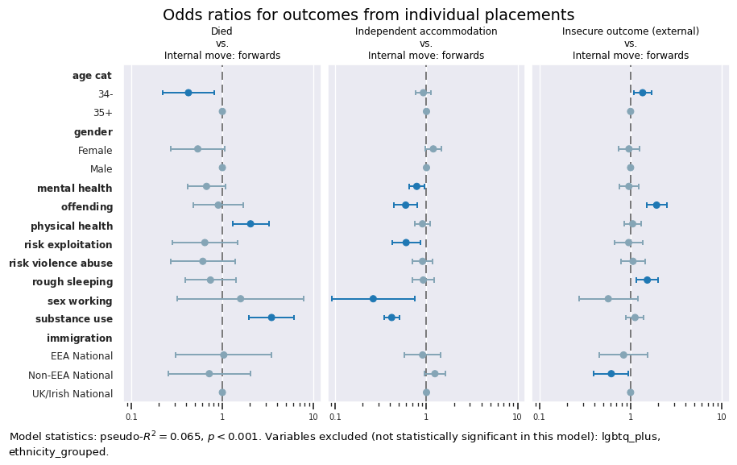

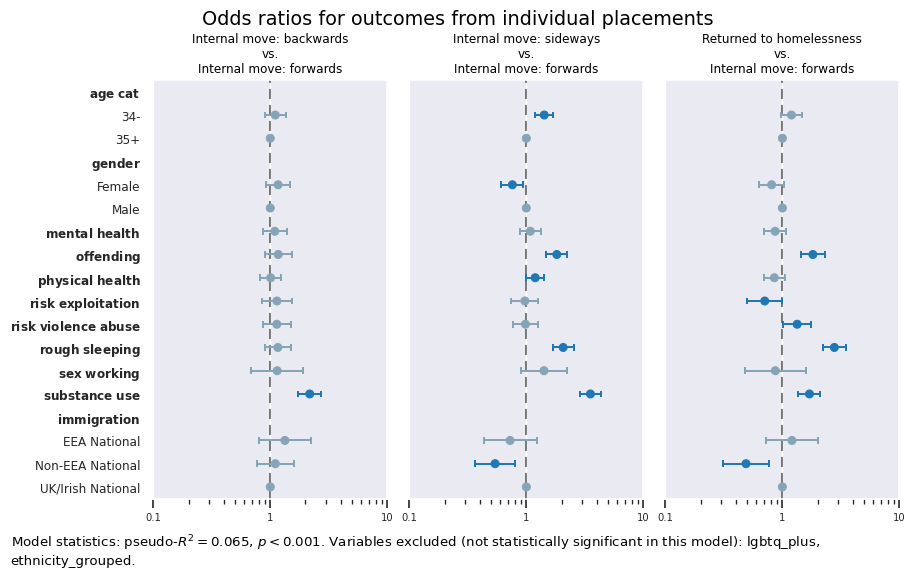

```python
from itertools import product
figure_minor_i += 1
theme = {"ytick.labelsize": "medium"}
ref_cats_used = {k: v for k, v in ref_cats.items() if k in ["gender", "age_cat", "uk_immigration_status"]}
shorter_iv = {r"uk\ immigration\ status": "immigration"}
cols_removed = cols_to_remove
cols_removed = [col for col in cols_to_remove if col != "multiple_disadvantage"]
for or_section, i_sub in [(slice(0, 3), "a"), (slice(3, None), "b")]:
    save_fmi = figure_minor_i
    temp_res_or = results_or_final.loc[results_or_final.index.levels[0][or_section]].copy()
    temp_res_or.index = temp_res_or.index.remove_unused_levels()
    figure_minor_i = str(figure_minor_i) + i_sub
    fig_str, fig = plot_odds_r(dv_str, dv.cat.categories[0], ref_cats_used, temp_res_or, replacements=shorter_iv, theme=theme, cols_removed=cols_removed)
    plt.show(block=False)
    figure_minor_i = save_fmi
```

# Tables in an Excel file

```python
import os
sheetname = "Sheet1"
qmdfile = os.getenv("QUARTO_DOCUMENT_FILE")
filename = assets_output + qmdfile[:-4]+".xlsx"
with pd.ExcelWriter(filename) as writer:
    next_row = 0
    for k, v in excel_output.items():
        pd.DataFrame([k]).to_excel(writer, sheet_name=sheetname, header=False, index=False, startrow=next_row)
        next_row += 1
        v.to_excel(writer, sheet_name=sheetname, startrow=next_row)
        next_row += (
            (1 if not isinstance(v.columns, pd.MultiIndex) else 1 + len(v.columns.levels))
            + len(v) + 1)
    float_format = writer.book.add_format({"num_format": "#,##0.000"})
    writer.sheets[sheetname].set_column("B:J", None, float_format)
print(f"[Excel file](./{filename})")
```

Excel file